# Statistical learning and individual differences in language abilities: A structural equation modelling study on the mediating roles of perceptual speed, working memory and cognitive control

# 1. Task descriptions

## 1.1. Statistical learning tasks

### 1.1.1. Speech segmentation task

The segmentation tasks were adapted from Saffran et al.’s (1996a; 1996b; 1999) studies. As in the original paradigm, participants were presented with a continuous stream of 12 CV syllables organized into four trisyllabic words so that transitional probabilities across syllables (TPs, i.e., the probability that syllable X is followed by syllable Y) were 1 within words and 0.33 across word boundaries. Syllable stimuli were adopted to the phonotactic rules of Hungarian (cé /tse:/, csa /tʃɒ/, gá /ga:/, gye /ɟε/, ha /hɒ/, jü /jy/, lo /lo/, pe /pε/, ri /ri/, sö /∫ø/, tu /tu/, vi /vi/), and combined into four 3-syllable nonsense words (cévigá, csagyejü, lohari, söpetu). To avoid coarticulation effects, syllables were recorded in isolation and manipulated in Praat (Boersma and Weenink, 2021). Syllables had a pitch of 125 Hz. Their duration was 270 ms and they were presented with an ISI of 30 ms, which resulted in a presentation rate of 300 ms.

The task consisted of a training phase followed by an offline test phase. During the training phase, participants were exposed to five blocks. Four of the streams (Blocks TRN1–TRN3 and Block REC5) contained the four words, and each of these words occurred 15 times in a pseudorandom order with the only constraint that the same word could not be repeated twice in a row. Block RND4 was a random stream, where the 12 syllables followed each other in a random order 15 times each, with the only constraint that the same syllable could not be repeated twice in a row. The streams did not provide any other cues to segmentation than the statistical properties (TPs) of the streams. In the structured streams, TPs within words were 1 and 0.33 at word boundaries. In Block RND4, TPs were 0.09 between any syllable.

After a short practice, throughout the five blocks of the training phase, participants performed a target detection task. They had to respond to a target (one of the last syllables of words, counterbalanced between participants) by pressing the spacebar, and to any other syllable by pressing “A” on the keyboard. The blocks consisted of 180 target items: each item occurred 15 times in both the structured and random streams. During this phase of the task, accuracy and RT measures were collected. We calculated six indices from the data of the online task: SEGM RT training (median RT<sub>TRN1</sub> - median RT<sub>TRN3</sub>), SEGM RT TRN3-RND4 (median RT<sub>RND4</sub> - median RT<sub>TRN3</sub>), SEGM RT RND4-REC5 (median RT<sub>RND4</sub> - median RT<sub>REC5</sub>), SEGM ACC training (accuracy<sub>TRN3</sub> - accuracy<sub>TRN1</sub>), SEGM ACC TRN3-RND4 (accuracy<sub>TRN3</sub> - accuracy<sub>RND4</sub>), and SEGM ACC RND4-REC5 (accuracyREC5 - accuracyRND4). Participants who did not have significantly more responses on targets than on other syllables (indicating attention to the task) as tested with a Fisher-exact test were excluded from the analyses of the training phase.

The online training phase was followed by a test phase consisting of a 2AFC and a production task. In the 2AFC task, bigram and trigram pairs were presented and participants were instructed to choose the one more familiar to what they heard in the training. Here, we used the four words and bigrams from the training streams, and we also created four part-word (syllable bigrams/trigrams spanning a word boundary in the word streams), and four non-word (syllable bigrams/trigrams not occurring together in the word streams) foils (Table 1). We tested three types of contrasts in the case of both bigrams and trigrams: word vs. part-word, word vs. non-word, and part-word vs. non-word sequences. Trials consisting of predefined contrasts were randomized for each participant. We quantified learning by accuracy rates for bigram and trigram contrasts: the number of correct answers divided by the number of all trials, yielding a number between 0 and 1 for the indices SEGM 2AFC bigram and SEGM 2AFC trigram. Participants also performed a production task, in which incomplete trisyllabic words were presented and their task was to complete them with one of three items in a 3AFC task. The 12 trials varied in the location and/or identity of the missing syllable within the sequence. Each word occurred three times in the task. We assessed learning in this task by an accuracy rate, the number of correct answers divided by the number of all trials, resulting in a number between 0 and 1, the SEGM production index.

Table 1

*Stimuli of the 2AFC task*

|  | word | part-word | non-word |
| --- | --- | --- | --- |
| trigram | cévigá | gácsagye | csahatu |
|  | csagyejü | jüloha | peloga |
|  | lohari | risöpe | rigyecé |
|  | söpetu | tucévi | visöjü |
| bigram | cévi | gácsa | csaha |
|  | csagye | jülo | pelo |
|  | loha | risö | rigye |
|  | söpe | tucé | visö |

Participants whose response rates to target items were not significantly higher than those to non-target items in the online task were excluded from the calculation of task indices and further analyses.

### 1.1.2. Artificial grammar learning task

We tested AGL by using the modified version of the AGL task of Knowlton and Squire (1996). The modifications were applied to make TPs between items more variable than in the original task version. This means that low, medium and high TPs varied across items, resulting in greater variability between difficulty levels of trials in the 2AFC task. In the target detection task, the target was a syllable that was highly predictable based on the preceding item (*péf*). The grammar used in this study is presented in Figure 1, and the TPs between individual units are shown in Table 2.

**Figure 1**

*The modified version of the artificial grammar Knowlton and Squire (1996)*

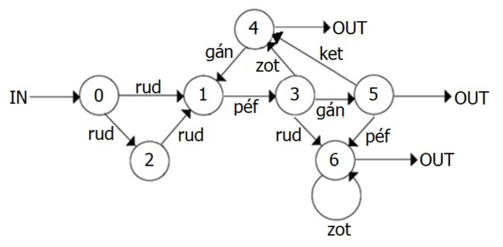

**Table 2**

*Forward transitional probabilities*

|  | **rud** | **péf** | **zot** | **gán** | **ket** |
| --- | --- | --- | --- | --- | --- |
| **rud** | 0.236 | 0.551 | 0.146 |  |  |
| **péf** | 0.224 |  | 0.329 | 0.388 |  |
| **zot** |  |  | 0.388 | 0.209 |  |
| **gán** |  | 0.643 |  |  | 0.250 |
| **ket** |  |  |  | 0.643 |  |

*Note.* The syllable péf was the target in the target detection task.

The words in the artificial lexicon were 1-syllable CVC nonwords compiled from the phoneme inventory of Hungarian (péf /peːf/, rud /rud/, gán /ɡaːn/, ket /kɛt/, zot /zot/). To avoid coarticulation effects, words were recorded in isolation and manipulated in Praat (Boersma and Weenink, 2021) to have a uniform pitch of 125 Hz. The duration of words was 400 ms and they were presented with an ISI of 50 ms within sentences and 100 ms between sentences.

34 grammatical strings were generated following the rules of the grammar, yielding 3 three-word sentences, 6 four-word sentences, 5 five-word sentences, 7 six-word sentences and 13 seven-word sentences. Eight sentences were selected for test strings only used in the offline tasks, while the remaining 26 strings were included in the online training phase.

**Figure 2**

*Testing procedure in the AGL task*

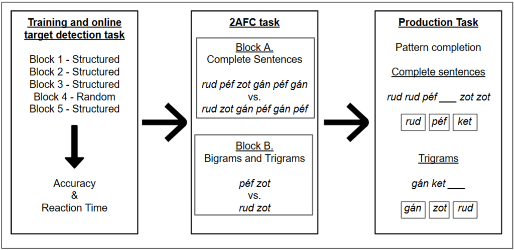

The task began with the online training phase, in which participants completed a target detection task. They were instructed to press the spacebar when they heard the target word (péf /peːf/) and the key ‘A’ for every other words. The training consisted of five blocks: Blocks 1-3 and Block 5 contained the same training strings, while Block 4 contained 26 random strings which were generated by arranging the words of the grammar in a random order. The strings within all blocks were presented in a randomized order. Each training block contained the target 42 times, while the random block had 43 occurrences of it. We measured accuracy and RTs for all targets throughout the 5 blocks. We expected to see better prediction (reflected in increasing accuracy and decreasing RTs) as learning proceeds, together with a decrease (poorer accuracy and longer RTs) in the random block (Block 4), and in the recovery block (Block 5) an increase again, compared to the random block, in which performance was expected to reach the level of performance in Block 3. We calculated six indices from the RT and accuracy data of the online blocks: AGL RT training (median RT<sub>TRN1</sub> - median RT<sub>TRN3</sub>), AGL RT TRN3-RND4 (median RT<sub>RND4</sub> - median RT<sub>TRN3</sub>), AGL RT RND4-REC5 (median RT<sub>RND4</sub> - median RT<sub>REC5</sub>), AGL ACC training (accuracy<sub>TRN3</sub> - accuracy<sub>TRN1</sub>), AGL ACC TRN3-RND4 (accuracy<sub>TRN3</sub> - accuracy<sub>RND4</sub>), and AGL ACC RND4-REC5 (accuracy<sub>REC5</sub> - accuracy<sub>RND4</sub>). Participants who did not have significantly more responses on targets than on other syllables (indicating attention to the task) as tested with a Fisher-exact test were excluded from the analyses of the training phase.

The online training phase was followed by a 2AFC task, in which participants were instructed to choose between two strings; they were asked to select the one that is more similar to the previously heard language. This task consisted of two blocks: a block testing sensitivity to TPs in complete sentences (16 trials, yielding a 2AFC sentence index) and a block testing sensitivity to TPs in sentence fragments (bigrams and trigrams, 22 trials, yielding a 2AFC sentence fragments index). In the block of complete sentences, the grammatical string was a sentence of the grammar (one of the eight previously selected test sentences, which they have not heard during the training phase). In this block, each grammatical sentence occurred twice, paired with different ungrammatical sentences, which were in all cases the modified versions of the given grammatical string. In the block of sentence fragments, six bigrams and six trigrams were included. All of them occurred paired with a bigram/trigram of syllables with zero TP, and ten trials (five bigrams and five trigrams) occurred again by an also grammatical fragment with lower frequency of occurrence in the training. We aimed to increase the sensitivity of the task by including trials where targets and distractors differ on varying dimensions (transitional probabilities, frequency, grammaticality, surface features like the grammatical beginning or ending of sequences) and sequence length (complete sentences or sentence fragments). The order of the blocks and the order of each trial within each block was randomized. 2AFC accuracy rates were calculated by dividing the number of correct responses by the number of all trials for the two blocks separately, resulting in the AGL 2AFC phrase and AGL 2AFC sentence indices.

The second offline task was a production task, in which participants saw incomplete sentences on the computer screen, and they were instructed to complete them with one of three words provided below the incomplete sentence. The 24 test trials contained eight grammatical trigrams and the eight test sentences. Each test sentence occurred in two trials, while the trigrams were presented only once. Trials varied in the location and the identity of the missing item within the sequence. Performance in this task was quantified by dividing the number of correct responses by the number of all trials, resulting in the AGL production index. Participants whose response rates to target items were not significantly higher than those to non-target items in the online task were excluded from the calculation of task indices and further analyses.

## 1.2. Language tasks

### 1.2.1. Grammatical sensitivity task

The grammatical sensitivity task (based on Carroll & Sapon, 1959 and Ottó & Nikolov, 2003) was conducted to assess participants’ sensitivity to grammatical structure without the recruitment of metalinguistic processes. In each trial of the task, participants were presented with two sentences. In the first sentence (sample), a part of the sentence was highlighted from the text. In the second sentence (test), three parts were highlighted, and one of the highlighted parts was analogous to the target in the first sentence along a given structural or functional aspect.

**Figure 3**

*A trial from the grammatical sensitivity task*

SAMPLE

Laura fogmosással kezdi a hétfő reggelt.

Laura fog-mos-ás-sal kezdi a hétfő reggel-t

Laura toothbrushing-INST start-DEF.3SG the Monday morning-ACC

‘Laura starts Monday morning with toothbrushing.’

TEST

Addigra már abbahagytam a dicsekvést a számtalan kalandommal.

Addigra már abba-hagy-t-am a dicsekvés-t a számtalan kaland-om-mal

by.then already stop-PFV-PAST-DEF.1SG the boast-ACC the countless adventure-POSS.1SG-INST

‘By then, I had already stopped boasting about my countless adventures.’

1. Addigra (2) a dicsekvést (3) a számtalan kalandommal

Participants’ task was to choose which highlighted part from the second sentence was the most similar to that of the first sentence. This task yielded one accuracy index calculated as the ratio of correct responses to trials, *grammatical sensitivity*. Participants whose accuracy was lower than 0.5 were excluded from further analyses.

### 1.2.2. Pragmatic comprehension task

We used the pragmatic comprehension task (KOBAK, Lukács & Kas, 2024) to assess participants’ ability to process the pragmatic level of sentences in a four-alternative forced-choice picture selection task. In each trial, participants heard a sentence with conflicting semantic and pragmatic meanings. The four pictures depicted four situations, and participants had to choose the one best matching the meaning of the sentence. The trials tested metaphor comprehension, conversational implicatures and irony. Participants were informed that multiple solutions might seem acceptable, but they should choose the one which seems the best match. The task yielded one index calculated from the accuracies of trials, *pragmatic comprehension*. Participants whose accuracy was lower than 0.4 were excluded from further analyses.

### 1.2.3. Self-paced reading task

Participants’ online sentence processing abilities were assessed in a self-paced reading task. This task required participants to read sentences at their preferred pace by pressing a key to progress through the text. The task included three types of sentences, each type with a different type of difficulty in processing. Participants were presented with 1) two types of garden path sentences, where the sentence interpretation had to be rebuilt at a point when the typical original interpretation proved to be wrong (garden path sentences and past participle garden path sentences), 2) sentences that included some kind of semantic or grammatical violation, and 3) sentences including an object relative clause. These test sentences inducing processing difficulties were matched with control sentence pairs without these factors taxing sentence processing: 1) sentences without local ambiguities, 2) sentences without violations and 3) sentences with subject relative clauses. Example sentences for the processing difficulty types are given in Figure 5.

**Figure 5**

*Example sentences for the different sentence types of the self-paced reading task*

*GARDEN PATH SENTENCES*

TEST:

Míg Zsuzsi írt egy levelet hozott a postás.

Míg Zsuzsi ír-t, egy level-et hoz-ott a postás

while Zsuzsi write-PAST, INDEF letter-ACC bring-PAST DEF postman

‘While Zsuzsi was writing, the postman brought a letter.’

CONTROL:

Míg Zsuzsi írt egy üzenetet egy levelet hozott a postás.

Míg Zsuzsi ír-t egy üzenet-et, egy levél-et hoz-ott a postás

while Zsuzsi write-PAST.INDEF a message-ACC, a letter-ACC bring-PAST.DEF the postman

‘While Zsuzsi was writing a message, the postman brought a letter.’

*PAST PARTICIPLE GARDEN PATH SENTENCES*

TEST:

Péter gyakran fordított irányban írta le a nevét.

Péter gyakran fordított irány-ban ír-ta le a nev-é-t

Péter often reversed direction-INE write-PAST.3SG.DEF down the name-POSS.3SG-ACC

‘Péter often wrote his name down in reverse.’

CONTROL:

Péter gyakran a fordított irányban írta le a nevét.

Péter gyakran a fordított irány-ban ír-ta le a nev-é-t

Péter often the reversed direction-INE write-PAST.3SG.DEF down the name-POSS.3SG-ACC

‘Péter often wrote his name down in the reverse direction.’

*SEMANTIC VIOLATION*

TEST:

Sötét volt így felkapcsoltam a tigrist a konyhában.

Sötét volt, így fel-kapcsol-t-am a tigris-t a konyhá-ban

dark be.PAST.3SG so up-switch-PAST-1SG.DEF the tiger-ACC the kitchen-INE

‘It was dark, so I switched on the tiger in the kitchen.’

CONTROL:

Sötét volt így felkapcsoltam a villanyt a konyhában.

Sötét volt, így fel-kapcsol-t-am a villany-t a konyhá-ban

dark be.PAST.3SG so up-switch-PAST-1SG.DEF the light-ACC the kitchen-INE

‘It was dark, so I switched on the light in the kitchen.’

*SYNTACTIC VIOLATION*

TEST:

A szobalány végigsöpörte egy seprűkkel a padlót.

A szobalány végig-söpör-te egy seprű-k-kel a padló-t

DEF maid through-sweep-PAST.3SG.DEF a broom-PL.INST the floor-ACC

‘The maid swept the floor with a brooms.’

CONTROL:

A szobalány végigsöpörte egy seprűvel a padlót.

A szobalány végig-söpör-te egy seprű-vel a padló-t

DEF maid through-sweep-PAST-3SG.DEF a broom-INST the floor-ACC

*OBJECT RELATIVE CLAUSES*

TEST:

Az ügyvéd akit az újságíró felhívott főzött egy bablevest.

Az ügyvéd, akit az újságíró fel-hív-ott, főz-ött egy bableves-t

The lawyer, REL.OBJ the journalist up-call-PAST.INDEF cook-PAST.INDEF a bean-soup-ACC

‘The lawyer, whom the journalist called, cooked a bean soup.’

CONTROL:

Az ügyvéd aki az újságírót felhívta főzött egy bablevest.

Az ügyvéd aki az újságíró-t fel-hív-ta, főz-ött egy bableves-t

The lawyer REL.NOM the journalist-ACC up-call-PAST.DEF, cook-PAST.INDEF a bean-soup-ACC

‘The lawyer, who called the journalist, cooked a bean soup.’

*Note.* Target and target plus one sentence parts are underlined.

After the self-paced presentation of each sentence, participants were required to answer a question about its content to ensure careful processing of the materials. Indices were calculated from the reaction time differences between the targets and the sentence parts after the targets (target plus one) in test and control sentence pairs. We tested both targets and sentence parts immediately after the targets because of the potential overflow effects and we wanted to look at which comparison results in a larger and more reliable effect in the case of each sentence type. This resulted in eight indices altogether, garden path sentence processing - target, garden path sentence processing - plus one, past participle garden path sentence processing - target, past participle garden path sentence processing - plus one, sentence violation processing - target, sentence violation processing - plus one, object relative clause processing - target and object relative clause processing - plus one. Participants whose accuracy was lower than 0.7 on the comprehension questions were excluded from further analyses. We hypothesized that smaller reaction time differences between test and control sentences would be associated with more efficient sentence processing. For this reason, we changed the sign of scores of the indices so that larger values were associated with more efficient sentence processing abilities.

While we interpret smaller reaction time differences between test and control sentences as indicating more efficient sentence processing, we acknowledge that the interpretation of this type of interference-based index is not without caveats. In theory, minimal differences may also reflect reduced sensitivity to sentence-level structure or a lack of engagement. In the present task, the majority of test sentences were semantically plausible but less predictable than their matched controls, requiring greater integration effort. A subset of test items also included semantic violations, which are known to elicit increased processing costs (Kutas & Hillyard, 1980; Kuperberg, 2007). Therefore, we interpret RT differences primarily as reflecting semantic integration difficulty rather than anomaly detection. On this basis, smaller RT differences suggest more efficient updating or resolution. This interpretation is further supported by weak but consistent positive correlations between this index and measures of language ability, statistical learning, and cognitive control.

### 1.2.4. Predictive sentence processing task

Semantic prediction abilities of participants were also assessed more directly by a predictive sentence processing task (Hintz et al., 2020, 2024). In each trial, participants heard a sentence and at the same time, they were presented with two pictures on the screen. Their task was to click on the key corresponding to the image that is presented in the sentence as quickly as they could. In half of the trials, the verb in the sentence was semantically restrictive, so the object (presented at the end of the sentence) was predictable based on the verb and the visual context provided by the two options. In the other half of the trials, the object was not predictable. An example for predictable and unpredictable sentences are illustrated on Figure 5.

**Figure 5**

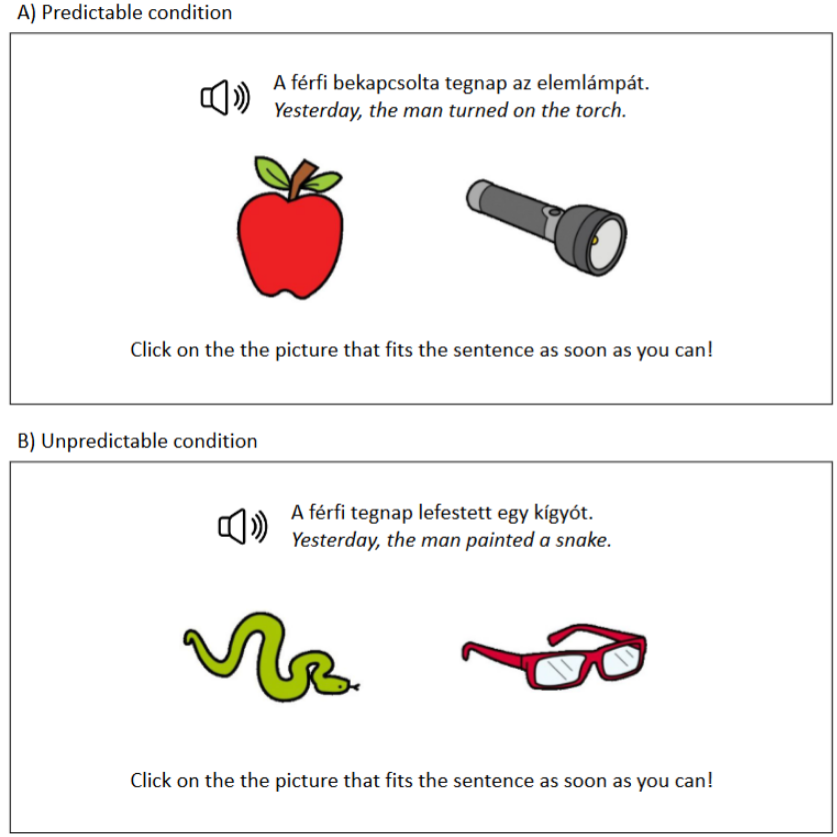

Sentence processing efficiency relying on the linguistic and visual context was quantified by contrasting accuracies and reaction times between responses in the case of predictable and unpredictable sentences, yielding the predictive sentence processing accuracy and predictive sentence processing RT indices. For each participant, reaction time outliers were identified and excluded based on Tukey’s fences criterion. Participants with an accuracy below 0.6 were excluded from further analyses.

In contrast with the self-paced reading task, where higher reaction time differences reflect processing cost, in the predictive sentence processing task, higher reaction time differences reflect a greater benefit from predictability—that is, faster or more accurate responses to predictable versus unpredictable sentences, indicating more effective use of contextual cues.

### 1.2.5. One-minute reading task

To assess participants’ reading fluency, we measured the amount of text (in number of syllables) they can process in a self-paced reading task where they could advance at their own pace. The text consisted of 1036 syllables altogether. They were informed that after reading the text, they would have to respond to comprehension questions on the contents. Participants below .5 accuracy rates on these comprehension questions were excluded from the analyses. Reading efficiency was quantified by the number of syllables read, yielding the one-minute reading index.

## 1.3. General cognitive tasks

### 1.3.1. Stroop task

The Stroop task also served to assess inhibitory control abilities. The task required participants to respond to words describing colors (‘blue’, ‘green’, ‘red’, ‘yellow’) written in fonts of one of the four different colors (blue, green, red, yellow). Word forms and font colors were either congruent (e.g. the word ‘yellow’ written in yellow font) or incongruent (e.g. the word ‘yellow’ written in blue font). Participants were asked to respond to the color of the font. There was an additional baseline condition where a neutral string was presented (‘xxxx’), and participants had to respond to the font color (blue, green, red, yellow). Responses from this condition were solely used for assessing participants’ task engagement and were not used for task index calculation. The stimuli were presented until a response. There was an ISI of 500 ms between trials. The efficiency of inhibitory control was estimated by calculating the differences in accuracies and reaction times between the incongruent and congruent trials, yielding the stroop accuracy (accuracy<sub>congruent</sub> - accuracy<sub>incongruent</sub>) and stroop RT (median RT<sub>incongruent</sub> - median RT<sub>congruent</sub>) indices. For each participant, reaction time outliers were identified and excluded based on Tukey’s fences criterion. Participants with an accuracy below 0.5 in the baseline condition were excluded from further analyses. Larger differences between incongruent and congruent trials were assumed to be associated with lower inhibitory control efficiency. To align scoring with this assumption, we changed the sign of the task scores, such that larger values were associated with more efficient inhibitory control.

### 1.3.2. Simon task

To assess executive functions, more narrowly, interference control, we used the Simon task (based on Craft & Simon, 1970 and Tse & Altarriba, 2014). In this task, participants were presented with an arrow in each trial, and they were instructed to ignore the location and focus on the direction of the arrow and press button ‘L’ for right-pointing and button ‘S’ for left-pointing arrows. Arrows could appear in three locations: on the left, on the right or on the middle of the screen.

After a practice block, participants completed two blocks of the task, with a short break between them. The experimental blocks consisted of 60-60 trials in each of three conditions: 1) in the congruent condition, the left-pointing arrow was presented on the left, and the right-pointing arrow was presented on the right of the screen, 2) in the incongruent condition, the left-pointing arrow was presented on the right, while the right-pointing arrow was presented on the left of the screen, and 3) in the neutral condition both the left- and right-pointing arrows occurred in the center of the screen. Both blocks contained 20 congruent, 20 incongruent and 20 neutral trials in a randomized order. Each trial started with a fixation cross presented in the middle of the screen for 500 ms, which was followed by the presentation of the target arrow. The arrow was presented until a response, or for a maximum of 4000 ms. There was an ISI of 750 ms between trials. We calculated two indices from accuracies and RTs, simon accuracy (accuracy<sub>congruent</sub> - accuracy<sub>incongruent</sub>) and simon RT (median RT<sub>incongruent</sub> - median RT<sub>congruent</sub>). For each participant, reaction time outliers were identified and excluded based on Tukey’s fences criterion. Participants with an accuracy below 0.5 in the neutral condition were excluded from further analyses. We hypothesized that smaller RT differences between congruent and incongruent trials would be associated with more efficient interference control. For this reason, we changed the sign of scores of the indices so that larger values were associated with more efficient interference control.

### 1.3.3. N-back task

To assess executive functions, more narrowly, updating capacity, we used an n-back task. In this task, letters (B, C, F, H, K, L, M, Q, R, X) were presented individually in the middle of the screen, and participants were instructed to press the spacebar for every item that was identical to the one presented two steps earlier, and otherwise press key ‘A’. After a short practice block, the task consisted of four blocks altogether, a 1-back, two 2-back, and one 3-back block. Each block consisted of 60 trials: 10 targets, 10 lures and 40 foils. Blocks started with the presentation of a fixation cross for 1000ms, which was followed by the presentation of the individual trials for 500ms, with an ISI of 1500ms. We calculated a d-prime score for each difficulty level, 1-back d-prime, 2-back d-prime, and 3-back d-prime ((hits / 10) - (false alarms / 50) * 100).

### 1.3.4. Digit span

We assessed short term memory and working memory with a digit span task. Here, sequences of spoken digits were presented, and participants were instructed to reproduce them by typing back in the same (forward digit span for assessing short term memory) or in the reversed order (backward digit span for assessing working memory). Tasks started with the presentation of three digits sequences with an ISI of 200ms between individual digits, and the length of sequences increased as the task proceeded. The maximum length of sequences was ten digits. Participants were presented with four trials within each sequence length, and the task was terminated after three incorrect responses within the same length. The last sequence length with at least two correct responses were considered as forward digit span and backward digit span.

### 1.3.5. Perceptual speed

To test perceptual speed, we used a reaction time task that measured processing stimuli in the acoustic and visual modalities in three subtasks. In the first visual block, participants were instructed to look at a blank screen, and focus on the appearance of a picture of a ball in the middle of the screen and press the spacebar as fast as they could each time when the ball appeared. The visual block was followed by an acoustic block, in which participants had to focus on a tone presented via headphones. For both modalities, 32 trials were presented. ISIs varied randomly between 1223 and 4988 ms for the visual modality, and 1041 and 4883 ms for the auditory modality. These two subtasks yielded two indices calculated as the median of RTs, visual reaction time and auditory reaction time.

In a third block, participants had to complete a speeded visual decision making task. In this task, two Gabor patches were presented on the screen, and the task was to decide if the two patches had the same orientation or not. Participants were instructed to complete as many trials as they could within 60 seconds. Participants below .75 accuracy were excluded from the analysis of this subtask. The subtask yielded two indices, visual decision time (the median of RTs of trials) and visual decision score (1 - (median RT * (1 - accuracy))).

# 2. Data analysis

## 2.1. Preparation

R packages:

```r
library(tidyverse)
library(broom)
library(psych)
library(EFAtools)
library(lavaan)
library(ClustOfVar)
library(semTools)
library(semPlot)
library(tidySEM)
```

Data:

```r
df = df %>%
  mutate(
    perceptual_speed_visual_RT = -(perceptual_speed_visual_RT),
    perceptual_speed_visual_decision = -(perceptual_speed_visual_decision),
    perceptual_speed_auditory_RT = -(perceptual_speed_auditory_RT),
    simon_RT = -(simon_RT),
    simon_accuracy = -(simon_accuracy),
    stroop_RT = -(stroop_RT),
    stroop_accuracy = -(stroop_accuracy),
    selfpaced_gardenpath_target = -(selfpaced_gardenpath_target),
    selfpaced_violation_processing_target = -(selfpaced_violation_processing_target)
  )
```

## 2.2. Selecting reliable indices

Unidimensionality was assessed using Exploratory Factor Analyses (EFA) on individual items within the task index. We applied the following criterion: an index was considered to be unidimensional if one salient factor was possible to extract and its eigenvalue was above 1. As for most of our indices (all non-linguistic cognitive indices and statistical learning indices) unidimensionality tests were not applicable, we only tested the outcome (language) variables. Internal consistency was evaluated using the split-half method or omega coefficient where applicable, with a minimum reliability level set at 0.5 as the inclusion criterion.

For *grammatical sensitivity* and *pragmatic comprehension* indices, the item composition was modified to meet the criteria. Since these two indices consist of qualitatively different items, to prevent overfitting, we divided the sample into two halves. One half was used to select well-fitting items in the modified index, and the other half was employed to evaluate the new structure.

**Table 1**

*Reliability of indices of the original dataset*

| group | task | index | reliability type | reliability value | unidimensionality | suitable |
| --- | --- | --- | --- | --- | --- | --- |
| COG | perceptual speed | visual reaction time | split-half* | 0.957 | n.a. | yes |
| COG | perceptual speed | auditory reaction time | split-half* | 0.956 | n.a. | yes |
| COG | perceptual speed | visual decision score | split-half* | 0.179 | n.a. | no |
| COG | perceptual speed | visual decision time | split-half* | 0.952 | n.a. | yes |
| COG | simon | simon RT | split-half* | 0.643 | n.a. | yes |
| COG | simon | simon accuracy | split-half* | 0.546 | n.a. | yes |
| COG | stroop | stroop RT | split-half* | 0.768 | n.a. | yes |
| COG | stroop | stroop accuracy | split-half* | 0.876 | n.a. | yes |
| COG | digit span | forward digit span | n.a. | n.a. | n.a. | yes |
| COG | digit span | backward digit span | n.a. | n.a. | n.a. | yes |
| COG | n-back | 1-back d-prime | split-half* | 0.807 | n.a. | yes |
| COG | n-back | 2-back d-prime | split-half* | 0.763 | n.a. | yes |
| COG | n-back | 3-back d-prime | split-half* | 0.691 | n.a. | yes |
| SL | speech segmentation | SEGM RT training | split-half* | 0.646 | n.a. | yes |
| SL | speech segmentation | SEGM RT TRN3-RND4 | split-half* | 0.768 | n.a. | yes |
| SL | speech segmentation | SEGM RT RND4-REC5 | split-half* | 0.778 | n.a. | yes |
| SL | speech segmentation | SEGM ACC training | split-half* | 0.855 | n.a. | yes |
| SL | speech segmentation | SEGM ACC TRN3-RND4 | split-half* | 0.850 | n.a. | yes |
| SL | speech segmentation | SEGM ACC RND4-REC5 | split-half* | 0.761 | n.a. | yes |
| SL | speech segmentation | SEGM 2AFC bigram | n.a. | n.a. | n.a. | yes |
| SL | speech segmentation | SEGM 2AFC trigram | n.a. | n.a. | n.a. | yes |
| SL | speech segmentation | SEGM production | n.a. | n.a. | n.a. | yes |
| SL | artificial grammar learning | AGL RT training | split-half* | 0.222 | n.a. | no |
| SL | artificial grammar learning | AGL RT TRN3-RND4 | split-half* | 0.270 | n.a. | no |
| SL | artificial grammar learning | AGL RT RND4-REC5 | split-half* | 0.247 | n.a. | no |
| SL | artificial grammar learning | AGL ACC training | split-half* | 0.634 | n.a. | yes |
| SL | artificial grammar learning | AGL ACC TRN3-RND4 | split-half* | 0.380 | n.a. | no |
| SL | artificial grammar learning | AGL ACC RND4-REC5 | split-half* | 0.390 | n.a. | no |
| SL | artificial grammar learning | AGL 2AFC sentence | n.a. | n.a. | n.a. | yes |
| SL | artificial grammar learning | AGL 2AFC phrase | n.a. | n.a. | n.a. | yes |
| SL | artificial grammar learning | AGL production | n.a. | n.a. | n.a. | yes |
| LANG | predictive sentence processing | predictive sentence processing RT | split-half* | 0.853 | n.a. | yes |
| LANG | predictive sentence processing | predictive sentence processing accuracy | split-half* | 0.585 | n.a. | yes |
| LANG | KOBAK | pragmatic comprehension | omega | 0.630 | 1 | yes |
| LANG | grammatical sensitivity | grammatical sensitivity | omega | 0.676 | 1 | yes |
| LANG | self-paced reading | garden path - target | omega | 0.506 | 1 | yes |
| LANG | self-paced reading | garden path - plus one | omega | -0.060 | 0 | no |
| LANG | self-paced reading | past participle garden path - target | omega | 0.270 | 0 | no |
| LANG | self-paced reading | past participle garden path - plus one | omega | 0.140 | 0 | no |
| LANG | self-paced reading | object relative clause processing - target | omega | -0.030 | 1 | no |
| LANG | self-paced reading | object relative clause processing - plus one | omega | 0.576 | 0 | no |
| LANG | self-paced reading | sentence violation processing - target | omega | 0.681 | 1 | yes |
| LANG | self-paced reading | sentence violation processing - plus one | omega | 0.391 | 0 | no |
| LANG | one-minute reading | one-minute reading | n.a. | n.a. | n.a. | yes |

*Note.* *: Reported split-half reliabilities are the mean of 100 iterations, Spearman-Brown corrected at each iteration. Regarding the unidimensionality tests, numeral 1 signals that an index passed the test and numeral 0 signals that an index failed the test.

## 2.3. Latent factor identification

### 2.3.1. Summary for the process of latent factor identification

(See details below)

To identify latent factors, we initially categorised the measurement indices into three designated domains: the *statistical learning* (SL) domain, the *core cognitive* (COG) domain, and the *language* (LANG) domain (see Table 1).

As a next step, exploratory factor analyses (EFAs) were conducted within each domain, following these procedures:

1. **KMO test**: Using the Kaiser-Meyer-Olkin test, we assessed the measures of sampling adequacy (MSA) for the indices. Subsequently, indices with unsatisfactory fit for EFA (MSA < 0.6) were excluded.
2. **Bartlett’s test**: Secondly, Bartlett’s test of sphericity was employed, with the significance level indicating a suitable fit for EFA.
3. **Parallel analysis**: To determine the number of factors in each domain, Horn’s parallel analysis was used. This method compares eigenvalues derived from the data matrix to those from a Monte Carlo simulated matrix generated from random data of the same size.
4. **Exploratory factor analysis**: After determining the number of factors, exploratory factor analysis was conducted using maximum likelihood as the factoring method and promax (oblique) rotation. Missing values were imputed using the mean. Based on factor loadings and uniqueness observed in each index, we refined our model.
5. **Hierarchical cluster analysis**: To validate EFA results, hierarchical cluster analyses were performed. The stability of partitions from a hierarchy of variables was evaluated using a bootstrapping method (n=100). Based on the mean adjusted Rand criterion, we examined local maximums regarding the potential number of clusters and selected the one supported by our theoretical considerations if necessary. We then proceeded with k-means clustering of variables, resulting in the identification of latent variables.
6. **Confirmatory factor analysis**: In the final step, we validated the structure through confirmatory factor analysis. Analyses were conducted using the Robust Maximum Likelihood method, with missing values imputed by the Maximum Likelihood method. Final models were refined if necessary.

During these steps, seven indices were removed from the initial 32 indices for not meeting the KMO test criterion, and two additional indices were dropped due to model refinement. Thus, the final data set included 23 indices from 12 different tasks (Table 2).

### 2.3.2. Latent factors in statistical learning domain

**Kaiser-Meyer-Olkin test**:

```
## ℹ 'x' was not a correlation matrix. Correlations are found from entered raw data.
```

```
##
## ── Kaiser-Meyer-Olkin criterion (KMO) ──────────────────────────────────────────
##
## ✖ The overall KMO value for your data is miserable.
##   These data are hardly suitable for factor analysis.
##
##   Overall: 0.551
##
##   For each variable:
##   SEGM_RT_training  SEGM_RT_TRN3_RND4  SEGM_RT_RND4_REC5  SEGM_ACC_training
##              0.555              0.530              0.596              0.381
## SEGM_ACC_TRN3_RND4 SEGM_ACC_RND4_REC5   SEGM_2AFC_bigram  SEGM_2AFC_trigram
##              0.453              0.388              0.585              0.708
##    SEGM_production   AGL_ACC_training    AGL_2AFC_phrase  AGL_2AFC_sentence
##              0.756              0.419              0.604              0.655
##     AGL_production
##              0.645
```

Indices with unsatisfactory fit for EFA (MSA < 0.5) were excluded: - SEGM_ACC_training [speech segmentation - SEGM ACC training] - SEGM_ACC_TRN3_RND4 [speech segmentation - SEGM ACC TRN3-RND4] - SEGM_ACC_RND4_REC5 [speech segmentation - SEGM ACC RND4-REC5] - AGL_ACC_training [artificial grammar learning - AGL ACC training]

Then, KMO test was repeated.

```
## ℹ 'x' was not a correlation matrix. Correlations are found from entered raw data.
```

```
##
## ── Kaiser-Meyer-Olkin criterion (KMO) ──────────────────────────────────────────
##
## ! The overall KMO value for your data is mediocre.
##   These data are probably suitable for factor analysis.
##
##   Overall: 0.615
##
##   For each variable:
##  SEGM_RT_training SEGM_RT_TRN3_RND4 SEGM_RT_RND4_REC5  SEGM_2AFC_bigram
##             0.581             0.545             0.603             0.595
## SEGM_2AFC_trigram   SEGM_production   AGL_2AFC_phrase AGL_2AFC_sentence
##             0.705             0.831             0.604             0.703
##    AGL_production
##             0.642
```

The reaction time based indices showed poor fit (< 0.6), however, we did not omit them for their possible exploratory power. Instead, we performed two separate analysis with only the reaction time based variables and the remaining ones.

#### 2.3.2.1. RT variables

**Bartlett’s test**:

```
## ℹ 'x' was not a correlation matrix. Correlations are found from entered raw data.
```

```
##
## ✔ The Bartlett's test of sphericity was significant at an alpha level of .05.
##   These data are probably suitable for factor analysis.
##
##   𝜒²(3) = 799.62, p < .001
```

**Parallel analysis**:

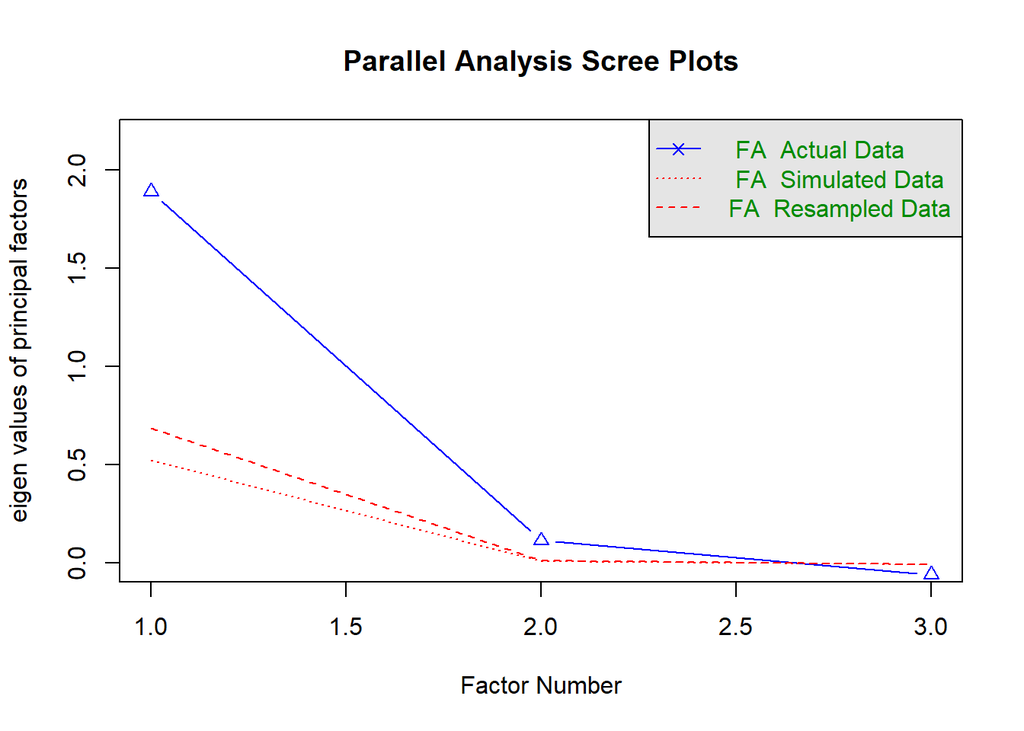

[output not shown]

Parallel analysis indicates a single factor.

**Exploratory factor analysis**:

```
##
## Factor analysis with Call: fa(r = ., nfactors = 1, rotate = "Promax", scores = "regression",
##     missing = TRUE, impute = "mean", fm = "ml", use = "pairwise",
##     cor = "cor")
##
## Test of the hypothesis that 1 factor is sufficient.
## The degrees of freedom for the model is 0  and the objective function was  0.05
## The number of observations was  608  with Chi Square =  28.44  with prob <  NA
##
## The root mean square of the residuals (RMSA) is  0.06
## The df corrected root mean square of the residuals is  NA
##
## Tucker Lewis Index of factoring reliability =  -Inf
```

```
##
## Loadings:
##                   ML1
## SEGM_RT_training  0.690
## SEGM_RT_TRN3_RND4 0.998
## SEGM_RT_RND4_REC5 0.685
##
##                  ML1
## SS loadings    1.941
## Proportion Var 0.647
```

```
## # A tibble: 3 × 2
##   names                   x
##   <chr>               <dbl>
## 1 SEGM_RT_training  0.523
## 2 SEGM_RT_TRN3_RND4 0.00499
## 3 SEGM_RT_RND4_REC5 0.530
```

#### 2.3.2.2. Offline SL indices (non-RT indices)

**Bartlett’s test**:

```
## ℹ 'x' was not a correlation matrix. Correlations are found from entered raw data.
```

```
##
## ✔ The Bartlett's test of sphericity was significant at an alpha level of .05.
##   These data are probably suitable for factor analysis.
##
##   𝜒²(15) = 356.5, p < .001
```

**Parallel analysis**:

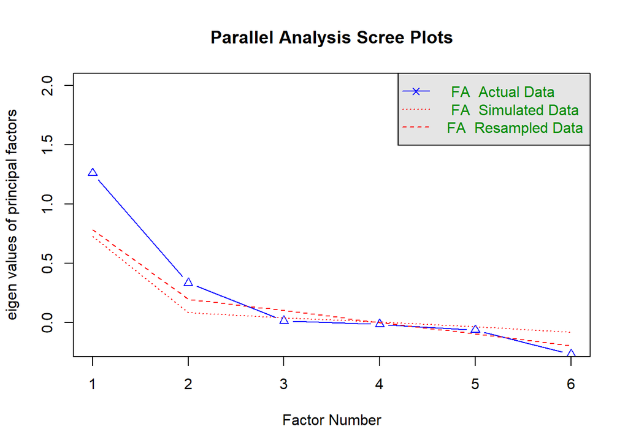

```
## Parallel analysis suggests that the number of factors =  2  and the number of components =  NA
```

Parallel analysis indicates 2 factors.

**Exploratory factor analysis**:

```
##
## Factor analysis with Call: fa(r = ., nfactors = 2, rotate = "Promax", scores = "regression",
##     missing = TRUE, impute = "mean", fm = "ml", use = "pairwise",
##     cor = "cor")
##
## Test of the hypothesis that 2 factors are sufficient.
## The degrees of freedom for the model is 4  and the objective function was  0.02
## The number of observations was  608  with Chi Square =  9.05  with prob <  0.06
##
## The root mean square of the residuals (RMSA) is  0.02
## The df corrected root mean square of the residuals is  0.05
##
## Tucker Lewis Index of factoring reliability =  0.944
## RMSEA index =  0.046  and the 10 % confidence intervals are  0 0.086
## BIC =  -16.59
##  With factor correlations of
##      ML1  ML2
## ML1 1.00 0.39
## ML2 0.39 1.00
```

```
##
## Loadings:
##                   ML1    ML2
## SEGM_2AFC_bigram   0.316
## SEGM_2AFC_trigram  1.020
## SEGM_production    0.150  0.336
## AGL_2AFC_phrase           0.442
## AGL_2AFC_sentence         0.700
## AGL_production            0.562
##
##                  ML1   ML2
## SS loadings    1.173 1.122
## Proportion Var 0.196 0.187
## Cumulative Var 0.196 0.382
```

```
## # A tibble: 6 × 2
##   names                   x
##   <chr>               <dbl>
## 1 SEGM_2AFC_bigram  0.881
## 2 SEGM_2AFC_trigram 0.00500
## 3 SEGM_production   0.825
## 4 AGL_2AFC_phrase   0.826
## 5 AGL_2AFC_sentence 0.543
## 6 AGL_production    0.679
```

#### 2.3.2.3. Final model for statistical learning variables

Since the 2-factor model showed a complex structure, we proceeded with hierarchical cluster analysis to reveal potential single-variable factors.

**Hierarchical cluster analysis**:

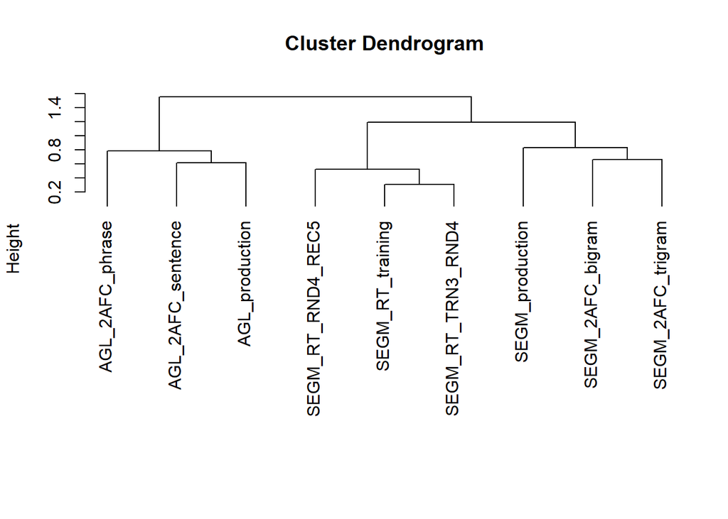

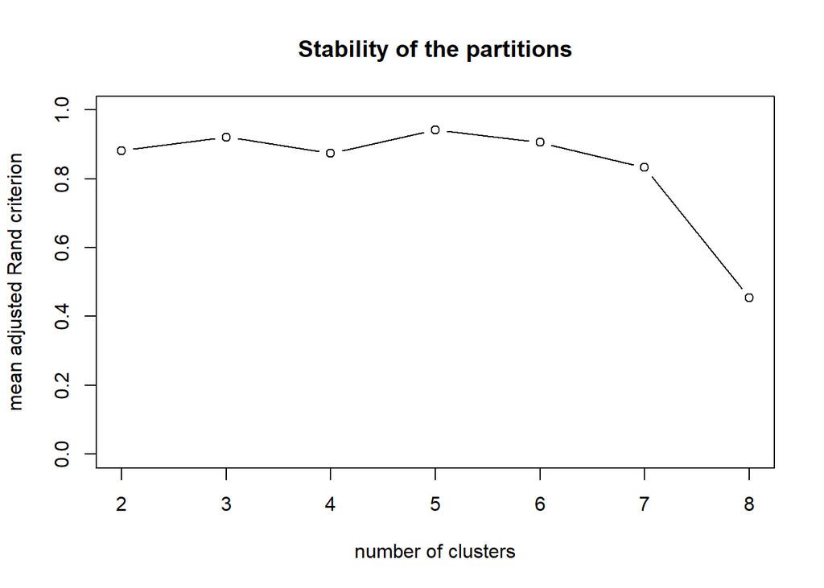

Since the Rand criterion shows that there is two local maxima (at 3 and 5) regarding the number of clusters, we selected the greater number to get a more detailed analysis.

**K-means cluster analysis**:

```
##
## Call:
## kmeansvar(X.quanti = ., init = 5, nstart = 1000)
##
## number of iterations:  1
##
## Data:
##    number of observations:  608
##    number of variables:  9
##    number of clusters:  5
##
## Cluster  1 :
##                   squared loading correlation
## SEGM_RT_TRN3_RND4            0.89       -0.94
## SEGM_RT_training             0.64       -0.80
## SEGM_RT_RND4_REC5            0.64       -0.80
##
##
## Cluster  2 :
##                   squared loading correlation
## SEGM_2AFC_trigram            0.67       -0.82
## SEGM_2AFC_bigram             0.67       -0.82
##
##
## Cluster  3 :
## squared loading     correlation
##               1               1
##
##
## Cluster  4 :
## squared loading     correlation
##               1               1
##
##
## Cluster  5 :
##                   squared loading correlation
## AGL_2AFC_sentence            0.69       -0.83
## AGL_production               0.69       -0.83
##
##
## Gain in cohesion (in %):  67.34
```

In conclusion, we used these 5 clusters of statistical learning variables to identify latent factors which later serve as predictors in the SEM models. We tested the robustness of the results with confirmatory factor analysis.

**Confirmatory factor analysis**:

**Model fits for CFA**:

```
## lavaan 0.6.17 ended normally after 51 iterations
##
##   Estimator                                         ML
##   Optimization method                           NLMINB
##   Number of model parameters                        35
##
##                                                   Used       Total
##   Number of observations                           386         608
##   Number of missing patterns                        11
##
## Model Test User Model:
##                                               Standard      Scaled
##   Test Statistic                                29.141      30.182
##   Degrees of freedom                                19          19
##   P-value (Chi-square)                           0.064       0.050
##   Scaling correction factor                                  0.966
##     Yuan-Bentler correction (Mplus variant)
##
## Model Test Baseline Model:
##
##   Test statistic                               559.241     481.464
##   Degrees of freedom                                36          36
##   P-value                                        0.000       0.000
##   Scaling correction factor                                  1.162
##
## User Model versus Baseline Model:
##
##   Comparative Fit Index (CFI)                    0.981       0.975
##   Tucker-Lewis Index (TLI)                       0.963       0.952
##
##   Robust Comparative Fit Index (CFI)                         0.983
##   Robust Tucker-Lewis Index (TLI)                            0.967
##
## Loglikelihood and Information Criteria:
##
##   Loglikelihood user model (H0)              -3119.162   -3119.162
##   Scaling correction factor                                  1.218
##       for the MLR correction
##   Loglikelihood unrestricted model (H1)      -3104.591   -3104.591
##   Scaling correction factor                                  1.129
```

[output cut: 77 more lines]

```
##                    Estimate  Std.Err  z-value  P(>|z|)   Std.lv  Std.all
##    .SEGM_RT_tranng    0.406    0.072    5.595    0.000    0.406    0.598
##    .SEGM_RT_TRN3_R   -0.165    0.101   -1.629    0.103   -0.165   -0.194
##    .SEGM_RT_RND4_R    0.532    0.100    5.344    0.000    0.532    0.608
##    .SEGM_2AFC_bgrm    0.857    0.091    9.387    0.000    0.857    0.850
##    .SEGM_2AFC_trgr    0.264    0.290    0.911    0.362    0.264    0.251
##    .SEGM_productin    0.000                               0.000    0.000
##    .AGL_2AFC_sntnc    0.585    0.105    5.568    0.000    0.585    0.600
##    .AGL_production    0.603    0.106    5.713    0.000    0.603    0.623
##    .AGL_2AFC_phras    0.000                               0.000    0.000
##     SL_RT             0.273    0.058    4.740    0.000    1.000    1.000
##     SL_tribi          0.152    0.074    2.059    0.040    1.000    1.000
##     SL_SEGM_prod      0.920    0.064   14.389    0.000    1.000    1.000
##     SL_AGL            0.390    0.112    3.492    0.000    1.000    1.000
##     SL_phr            0.966    0.080   12.034    0.000    1.000    1.000
```

In one case (*SEGM_2AFC_bigram [speech segmentation - SEGM 2AFC bigram]*), the unexplained variance was high (>0.65), however we kept it to assign convergent validity to the SL_trigram variable. We further excluded the *SEGM_AL_midRT_train [speech segmentation - SEGM RT training]* index to solve the Heywood case present in this factor.

The final grouping of the variables is:

1. **SEGM RT**:
- SEGM_RT_TRN3_RND4 [speech segmentation - SEGM RT TRN3-RND4]
- SEGM_RT_RND4_REC5 [speech segmentation - SEGM RT RND4-REC5]
2. **SEGM 2AFC**:
- SEGM_2AFC_trigram [speech segmentation - SEGM 2AFC trigram]
- SEGM_2AFC_bigram [speech segmentation - SEGM 2AFC bigram]
3. **SEGM production**:
- SEGM_production [speech segmentation - SEGM production]
4. **AGL**:
- AGL_2AFC_sentence [artificial grammar learning - AGL 2AFC sentence ]
- AGL_production [artificial grammar learning - AGL production]
5. **AGL phrase**:
- AGL_2AFC_phrase [artificial grammar learning - AGL 2AFC phrase]

### 2.3.3. Latent factors in core cognitive domain

**Kaiser-Meyer-Olkin test**:

```
## ℹ 'x' was not a correlation matrix. Correlations are found from entered raw data.
```

```
##
## ── Kaiser-Meyer-Olkin criterion (KMO) ──────────────────────────────────────────
##
## ! The overall KMO value for your data is mediocre.
##   These data are probably suitable for factor analysis.
##
##   Overall: 0.699
##
##   For each variable:
##       perceptual_speed_visual_RT     perceptual_speed_auditory_RT
##                            0.728                            0.712
## perceptual_speed_visual_decision               digit_span_forward
##                            0.811                            0.654
##              digit_span_backward              nback_1_back_dprime
##                            0.628                            0.766
##              nback_2_back_dprime              nback_3_back_dprime
##                            0.650                            0.672
##                        stroop_RT                  stroop_accuracy
##                            0.677                            0.594
##                         simon_RT                   simon_accuracy
##                            0.787                            0.455
```

Indices with unsatisfactory fit for EFA (MSA < 0.6) were excluded: * simon_accuracy [simon - accuracy] * stroop_accuracy [stroop - accuracy]

Then, KMO test was repeated.

```
## ℹ 'x' was not a correlation matrix. Correlations are found from entered raw data.
```

```
##
## ── Kaiser-Meyer-Olkin criterion (KMO) ──────────────────────────────────────────
##
## ✔ The overall KMO value for your data is middling.
##   These data are probably suitable for factor analysis.
##
##   Overall: 0.716
##
##   For each variable:
##       perceptual_speed_visual_RT     perceptual_speed_auditory_RT
##                            0.741                            0.709
## perceptual_speed_visual_decision               digit_span_forward
##                            0.803                            0.651
##              digit_span_backward              nback_1_back_dprime
##                            0.631                            0.776
##              nback_2_back_dprime              nback_3_back_dprime
##                            0.652                            0.674
##                        stroop_RT                         simon_RT
##                            0.732                            0.828
```

**Bartlett’s test**:

```
## ℹ 'x' was not a correlation matrix. Correlations are found from entered raw data.
```

```
##
## ✔ The Bartlett's test of sphericity was significant at an alpha level of .05.
##   These data are probably suitable for factor analysis.
##
##   𝜒²(45) = 1383.5, p < .001
```

**Parallel analysis**:

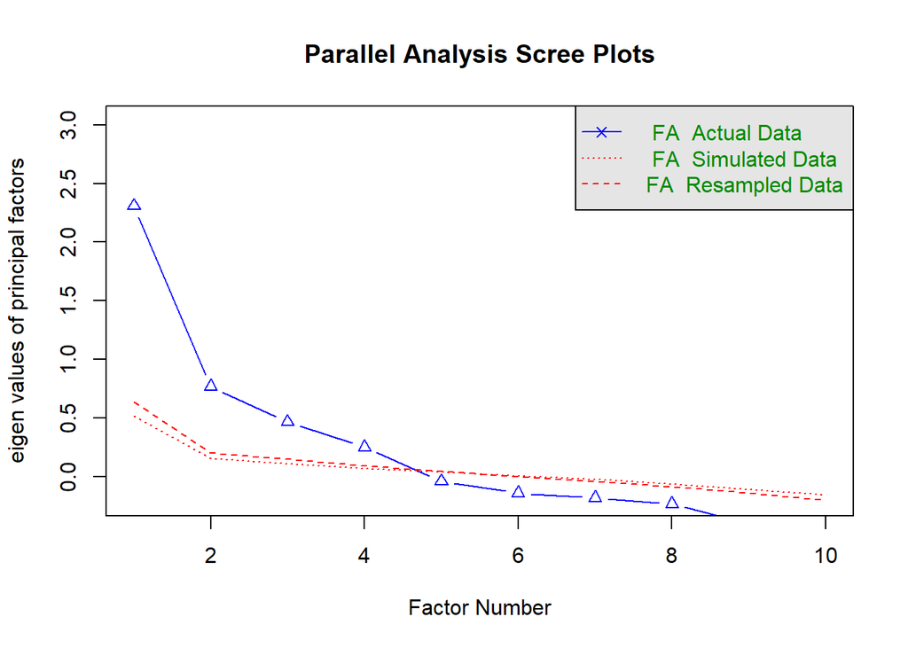

```
## Parallel analysis suggests that the number of factors =  4  and the number of components =  NA
```

**Exploratory factor analysis**:

```
##
## Factor analysis with Call: fa(r = ., nfactors = 4, rotate = "Promax", scores = "regression",
##     missing = TRUE, impute = "mean", fm = "ml", use = "pairwise",
##     cor = "cor")
##
## Test of the hypothesis that 4 factors are sufficient.
## The degrees of freedom for the model is 11  and the objective function was  0.04
## The number of observations was  608  with Chi Square =  22.31  with prob <  0.022
##
## The root mean square of the residuals (RMSA) is  0.01
## The df corrected root mean square of the residuals is  0.03
##
## Tucker Lewis Index of factoring reliability =  0.965
## RMSEA index =  0.041  and the 10 % confidence intervals are  0.015 0.066
## BIC =  -48.21
##  With factor correlations of
##      ML2  ML3  ML1  ML4
## ML2 1.00 0.34 0.17 0.36
## ML3 0.34 1.00 0.34 0.50
## ML1 0.17 0.34 1.00 0.38
## ML4 0.36 0.50 0.38 1.00
```

```
##
## Loadings:
##                                  ML2    ML3    ML1    ML4
## perceptual_speed_visual_RT               0.780
## perceptual_speed_auditory_RT             0.714        -0.148
## perceptual_speed_visual_decision         0.497         0.310
## digit_span_forward                       0.155  0.532
## digit_span_backward                             1.012
## nback_1_back_dprime               0.524                0.153
## nback_2_back_dprime               0.880
## nback_3_back_dprime               0.674               -0.120
## stroop_RT                               -0.111         0.649
## simon_RT                                 0.140         0.518
##
##                  ML2   ML3   ML1   ML4
## SS loadings    1.516 1.434 1.318 0.848
## Proportion Var 0.152 0.143 0.132 0.085
## Cumulative Var 0.152 0.295 0.427 0.512
```

```
## # A tibble: 10 × 2
##    names                                  x
##    <chr>                              <dbl>
##  1 perceptual_speed_visual_RT       0.364
##  2 perceptual_speed_auditory_RT     0.606
##  3 perceptual_speed_visual_decision 0.517
##  4 digit_span_forward               0.627
##  5 digit_span_backward              0.00500
##  6 nback_1_back_dprime              0.662
##  7 nback_2_back_dprime              0.272
##  8 nback_3_back_dprime              0.556
##  9 stroop_RT                        0.650
## 10 simon_RT                         0.634
```

For further analysis, we performed hierarchical variable clustering on the core cognitive variables as well.

**Hierarchical cluster analysis**:

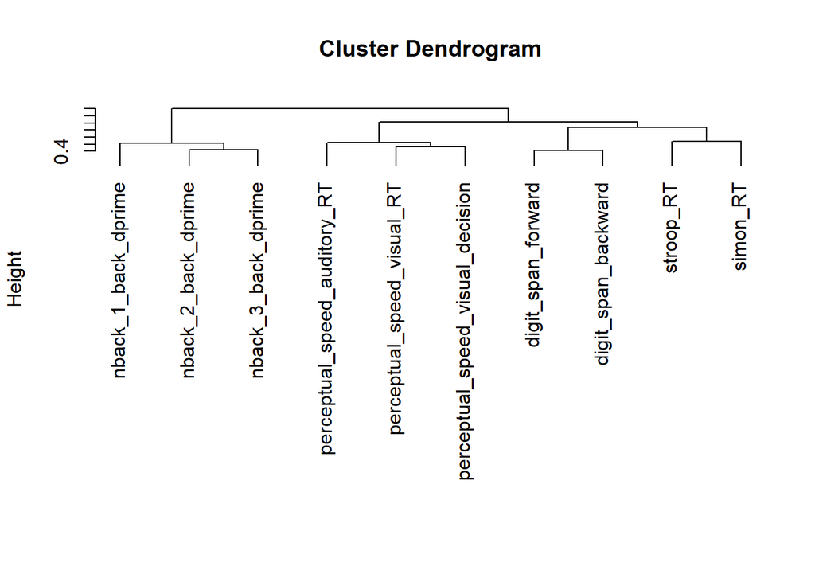

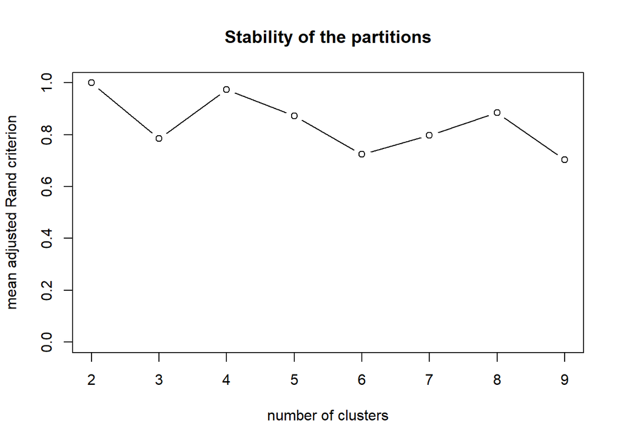

**K-means cluster analysis**:

```
##
## Call:
## kmeansvar(X.quanti = ., init = 4, nstart = 1000)
##
## number of iterations:  1
##
## Data:
##    number of observations:  608
##    number of variables:  10
##    number of clusters:  4
##
## Cluster  1 :
##                                  squared loading correlation
## perceptual_speed_visual_RT                  0.71       -0.85
## perceptual_speed_visual_decision            0.56       -0.78
## perceptual_speed_auditory_RT                0.56       -0.75
##
##
## Cluster  2 :
##                     squared loading correlation
## digit_span_backward            0.79       -0.89
## digit_span_forward             0.79       -0.89
##
##
## Cluster  3 :
##                     squared loading correlation
## nback_2_back_dprime            0.75       -0.86
## nback_3_back_dprime            0.63       -0.80
## nback_1_back_dprime            0.55       -0.74
##
##
## Cluster  4 :
##           squared loading correlation
## simon_RT             0.66        0.81
## stroop_RT            0.66        0.81
##
##
## Gain in cohesion (in %):  53.79
```

In conclusion, we have 4 clusters of cognitive variables:

1. **perceptual speed**:
- perceptual_speed_visual_RT [perceptual speed - visual reaction time]
- perceptual_speed_auditory_RT [perceptual speed - auditory reaction time]
- perceptual_speed_visual_decision [perceptual speed - visual decision time]
2. **digit span**:
- digit_span_forward [digit span - forward digit span]
- digit_span_backward [digit span - backward digit span]
3. **nback test**:
- nback_1_back_dprime [n-back - 1-back d-prime]
- nback_2_back_dprime [n-back - 2-back d-prime]
- nback_3_back_dprime [n-back - 3-back d-prime]
4. **cognitive control**:
- stroop_RT [stroop - RT]
- simon_RT [simon - RT]

As the following step, we tested whether these factors shows an appropriate fit using CFA.

**Confirmatory factor analysis**:

**Model fits for CFA**:

```
## lavaan 0.6.17 ended normally after 43 iterations
##
##   Estimator                                         ML
##   Optimization method                           NLMINB
##   Number of model parameters                        36
##
##                                                   Used       Total
##   Number of observations                           588         608
##   Number of missing patterns                        40
##
## Model Test User Model:
##                                               Standard      Scaled
##   Test Statistic                                75.186      74.394
##   Degrees of freedom                                29          29
##   P-value (Chi-square)                           0.000       0.000
##   Scaling correction factor                                  1.011
##     Yuan-Bentler correction (Mplus variant)
##
## Model Test Baseline Model:
##
##   Test statistic                              1151.464    1024.285
##   Degrees of freedom                                45          45
##   P-value                                        0.000       0.000
##   Scaling correction factor                                  1.124
##
## User Model versus Baseline Model:
##
##   Comparative Fit Index (CFI)                    0.958       0.954
##   Tucker-Lewis Index (TLI)                       0.935       0.928
##
##   Robust Comparative Fit Index (CFI)                         0.952
##   Robust Tucker-Lewis Index (TLI)                            0.925
##
## Loglikelihood and Information Criteria:
##
##   Loglikelihood user model (H0)              -6235.268   -6235.268
##   Scaling correction factor                                  1.956
##       for the MLR correction
##   Loglikelihood unrestricted model (H1)      -6197.675   -6197.675
##   Scaling correction factor                                  1.534
```

[output cut: 73 more lines]

```
##                    Estimate  Std.Err  z-value  P(>|z|)   Std.lv  Std.all
##    .prcptl_spd__RT    0.275    0.060    4.593    0.000    0.275    0.339
##    .prcptl_spd_vs_    0.470    0.076    6.173    0.000    0.470    0.443
##    .prcptl_spd__RT    0.623    0.078    7.999    0.000    0.623    0.693
##    .digt_spn_frwrd    0.395    0.078    5.071    0.000    0.395    0.401
##    .dgt_spn_bckwrd    0.440    0.076    5.821    0.000    0.440    0.435
##    .nbck_1_bck_dpr    0.640    0.050   12.768    0.000    0.640    0.665
##    .nbck_2_bck_dpr    0.260    0.068    3.819    0.000    0.260    0.286
##    .nbck_3_bck_dpr    0.560    0.062    8.970    0.000    0.560    0.558
##    .stroop_RT         0.672    0.121    5.541    0.000    0.672    0.729
##    .simon_RT          0.580    0.107    5.424    0.000    0.580    0.558
##     COG_PS            0.537    0.123    4.360    0.000    1.000    1.000
##     COG_DS            0.590    0.100    5.889    0.000    1.000    1.000
##     COG_nback         0.323    0.063    5.117    0.000    1.000    1.000
##     COG_RT            0.250    0.143    1.744    0.081    1.000    1.000
```

In three cases the unexplained variance is very high (>0.65). 1. First, we excluded the *nback_1_dprime* variable, since it does not carry more information compared to *nback_2_dprime* and *nback_3_dprime* variables both theoretically and measurement-wise. 2. Secondly, we split the *COG_RT factor* into two, since the *stroop* and *simon* tasks have potentially additional exploratory power in the model. 3. Thirdly, we split the *COG_PS factor* into two. (For detail see next section.)

To split the COG_PS into two factor, we performed two CFA analyses with nested models (*model_PS_01* and *model_PS_02*).

**First model / Model_PS_01**:

```
## lavaan 0.6.17 ended normally after 41 iterations
##
##   Estimator                                         ML
##   Optimization method                           NLMINB
##   Number of model parameters                        39
##
##                                                   Used       Total
##   Number of observations                           588         608
##   Number of missing patterns                        40
##
## Model Test User Model:
##                                               Standard      Scaled
##   Test Statistic                                44.698      41.625
##   Degrees of freedom                                15          15
##   P-value (Chi-square)                           0.000       0.000
##   Scaling correction factor                                  1.074
##     Yuan-Bentler correction (Mplus variant)
##
## Model Test Baseline Model:
##
##   Test statistic                              1005.137     864.414
##   Degrees of freedom                                36          36
##   P-value                                        0.000       0.000
##   Scaling correction factor                                  1.163
##
## User Model versus Baseline Model:
##
##   Comparative Fit Index (CFI)                    0.969       0.968
##   Tucker-Lewis Index (TLI)                       0.926       0.923
##
##   Robust Comparative Fit Index (CFI)                         0.965
##   Robust Tucker-Lewis Index (TLI)                            0.917
##
## Loglikelihood and Information Criteria:
##
##   Loglikelihood user model (H0)              -5640.834   -5640.834
##   Scaling correction factor                                  1.869
##       for the MLR correction
##   Loglikelihood unrestricted model (H1)      -5618.485   -5618.485
##   Scaling correction factor                                  1.648
```

[output cut: 85 more lines]

```
##    .prcptl_spd__RT    0.298    0.044    6.706    0.000    0.298    0.366
##    .prcptl_spd_vs_    0.474    0.060    7.866    0.000    0.474    0.444
##    .prcptl_spd__RT    0.000                               0.000    0.000
##    .digt_spn_frwrd    0.432    0.078    5.531    0.000    0.432    0.438
##    .dgt_spn_bckwrd    0.403    0.081    4.962    0.000    0.403    0.398
##    .nbck_2_bck_dpr    0.395    0.137    2.878    0.004    0.395    0.437
##    .nbck_3_bck_dpr    0.429    0.151    2.832    0.005    0.429    0.426
##    .stroop_RT         0.000                               0.000    0.000
##    .simon_RT          0.000                               0.000    0.000
##     PS_01             0.517    0.114    4.550    0.000    1.000    1.000
##     PS_02             0.890    0.101    8.788    0.000    1.000    1.000
##     COG_DS            0.554    0.099    5.595    0.000    1.000    1.000
##     COG_nback         0.509    0.145    3.503    0.000    1.000    1.000
##     COG_stroop        0.926    0.219    4.224    0.000    1.000    1.000
##     COG_simon         1.042    0.199    5.237    0.000    1.000    1.000
```

**Second model / Model_PS_02**:

```
## lavaan 0.6.17 ended normally after 41 iterations
##
##   Estimator                                         ML
##   Optimization method                           NLMINB
##   Number of model parameters                        39
##
##                                                   Used       Total
##   Number of observations                           588         608
##   Number of missing patterns                        40
##
## Model Test User Model:
##                                               Standard      Scaled
##   Test Statistic                                22.637      21.557
##   Degrees of freedom                                15          15
##   P-value (Chi-square)                           0.092       0.120
##   Scaling correction factor                                  1.050
##     Yuan-Bentler correction (Mplus variant)
##
## Model Test Baseline Model:
##
##   Test statistic                              1005.137     864.414
##   Degrees of freedom                                36          36
##   P-value                                        0.000       0.000
##   Scaling correction factor                                  1.163
##
## User Model versus Baseline Model:
##
##   Comparative Fit Index (CFI)                    0.992       0.992
##   Tucker-Lewis Index (TLI)                       0.981       0.981
##
##   Robust Comparative Fit Index (CFI)                         0.995
##   Robust Tucker-Lewis Index (TLI)                            0.988
##
## Loglikelihood and Information Criteria:
##
##   Loglikelihood user model (H0)              -5629.803   -5629.803
##   Scaling correction factor                                  1.878
##       for the MLR correction
##   Loglikelihood unrestricted model (H1)      -5618.485   -5618.485
##   Scaling correction factor                                  1.648
```

[output cut: 85 more lines]

```
##    .prcptl_spd__RT    0.128    0.079    1.627    0.104    0.128    0.159
##    .prcptl_spd__RT    0.624    0.074    8.451    0.000    0.624    0.698
##    .prcptl_spd_vs_    0.000                               0.000    0.000
##    .digt_spn_frwrd    0.422    0.075    5.630    0.000    0.422    0.428
##    .dgt_spn_bckwrd    0.413    0.077    5.392    0.000    0.413    0.408
##    .nbck_2_bck_dpr    0.398    0.119    3.337    0.001    0.398    0.441
##    .nbck_3_bck_dpr    0.425    0.134    3.177    0.001    0.425    0.421
##    .stroop_RT         0.000                               0.000    0.000
##    .simon_RT          0.000                               0.000    0.000
##     PS_01             0.680    0.137    4.971    0.000    1.000    1.000
##     PS_02             1.111    0.155    7.155    0.000    1.000    1.000
##     COG_DS            0.564    0.096    5.896    0.000    1.000    1.000
##     COG_nback         0.506    0.125    4.048    0.000    1.000    1.000
##     COG_stroop        0.925    0.217    4.258    0.000    1.000    1.000
##     COG_simon         1.037    0.197    5.263    0.000    1.000    1.000
```

Based on the two models, we concluded that *model_PS_02* indicates a better model considering four fit indices (TLI, CFI, SRMR, RMSEA) and the BIC. So for further analyses, we used the *perceptual_speed_visual_decision [perceptual speed - visual decision time]* index as a single-variable latent factor retaining the other two variables as the *PS factor*.

The final grouping of the variables is the following structure:

1. **perceptual speed**:
- perceptual_speed_visual_RT [perceptual speed - visual reaction time]
- perceptual_speed_auditory_RT [perceptual speed - auditory reaction time]
2. **visual decision speed**:
- perceptual_speed_visual_decision [perceptual speed - visual decision time]
3. **digit span**:
- digit_span_forward [digit span - forward digit span]
- digit_span_backward [digit span - backward digit span]
4. **nback test**:
- nback_2_back_dprime [n-back - 2-back d-prime]
- nback_3_back_dprime [n-back - 3-back d-prime]
5. **Stroop task**:
- stroop_RT [stroop - RT]
6. **Simon task**:
- simon_RT [simon - RT]

### 2.3.4. Latent factors in language domain

**Kaiser-Meyer-Olkin test**:

```
## ℹ 'x' was not a correlation matrix. Correlations are found from entered raw data.
```

```
##
## ── Kaiser-Meyer-Olkin criterion (KMO) ──────────────────────────────────────────
##
## ✖ The overall KMO value for your data is miserable.
##   These data are hardly suitable for factor analysis.
##
##   Overall: 0.594
##
##   For each variable:
##               grammatical_sensitivity                    one_minute_reading
##                                 0.565                                 0.673
##               predictive_sent_proc_RT         predictive_sent_proc_accuracy
##                                 0.518                                 0.465
##           selfpaced_gardenpath_target selfpaced_violation_processing_target
##                                 0.617                                 0.623
##               pragmatic_comprehension
##                                 0.620
```

We excluded the *predictive_sent_proc_accuracy [predictive sentence processing - accuracy]* index which showed unacceptable KMO values (< 0.5).

```
## ℹ 'x' was not a correlation matrix. Correlations are found from entered raw data.
```

```
##
## ── Kaiser-Meyer-Olkin criterion (KMO) ──────────────────────────────────────────
##
## ! The overall KMO value for your data is mediocre.
##   These data are probably suitable for factor analysis.
##
##   Overall: 0.624
##
##   For each variable:
##               grammatical_sensitivity                    one_minute_reading
##                                 0.613                                 0.670
##               predictive_sent_proc_RT           selfpaced_gardenpath_target
##                                 0.594                                 0.601
## selfpaced_violation_processing_target               pragmatic_comprehension
##                                 0.628                                 0.631
```

**Parallel analysis**:

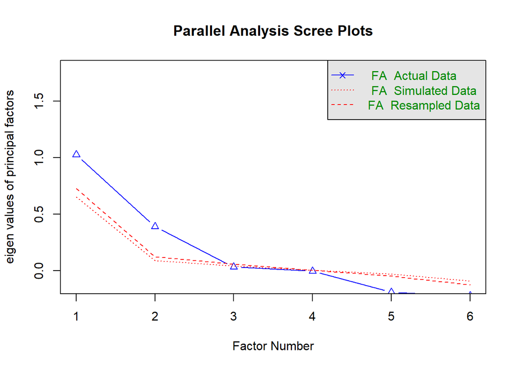

```
## Parallel analysis suggests that the number of factors =  2  and the number of components =  NA
```

Parallel analysis indicates 2 factors emerging.

**Exploratory factor analysis**:

```
##
## Factor analysis with Call: fa(r = ., nfactors = 2, rotate = "Promax", scores = "regression",
##     missing = TRUE, impute = "mean", fm = "ml", use = "pairwise",
##     cor = "cor")
##
## Test of the hypothesis that 2 factors are sufficient.
## The degrees of freedom for the model is 4  and the objective function was  0.02
## The number of observations was  608  with Chi Square =  12.06  with prob <  0.017
##
## The root mean square of the residuals (RMSA) is  0.03
## The df corrected root mean square of the residuals is  0.05
##
## Tucker Lewis Index of factoring reliability =  0.881
## RMSEA index =  0.058  and the 10 % confidence intervals are  0.022 0.096
## BIC =  -13.58
##  With factor correlations of
##      ML1  ML2
## ML1 1.00 0.32
## ML2 0.32 1.00
```

```
##
## Loadings:
##                                       ML1    ML2
## grammatical_sensitivity                       0.539
## one_minute_reading                     0.456
## predictive_sent_proc_RT                       0.410
## selfpaced_gardenpath_target            0.620
## selfpaced_violation_processing_target  0.594
## pragmatic_comprehension                       0.471
##
##                  ML1   ML2
## SS loadings    0.947 0.693
## Proportion Var 0.158 0.115
## Cumulative Var 0.158 0.273
```

```
## # A tibble: 6 × 2
##   names                                     x
##   <chr>                                 <dbl>
## 1 grammatical_sensitivity               0.720
## 2 one_minute_reading                    0.763
## 3 predictive_sent_proc_RT               0.835
## 4 selfpaced_gardenpath_target           0.639
## 5 selfpaced_violation_processing_target 0.642
## 6 pragmatic_comprehension               0.775
```

Since the 2-factor model showed a complex structure, we proceeded with hierarchical cluster analysis to reveal potential single-variable factors.

**Hierarchical cluster analysis**:

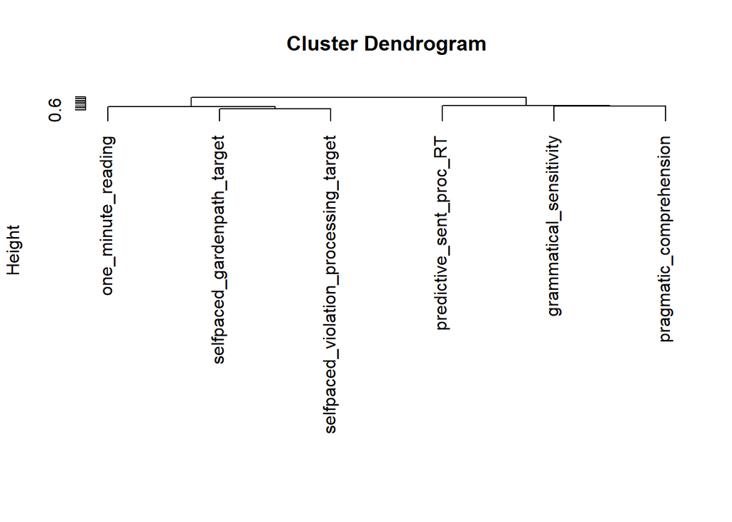

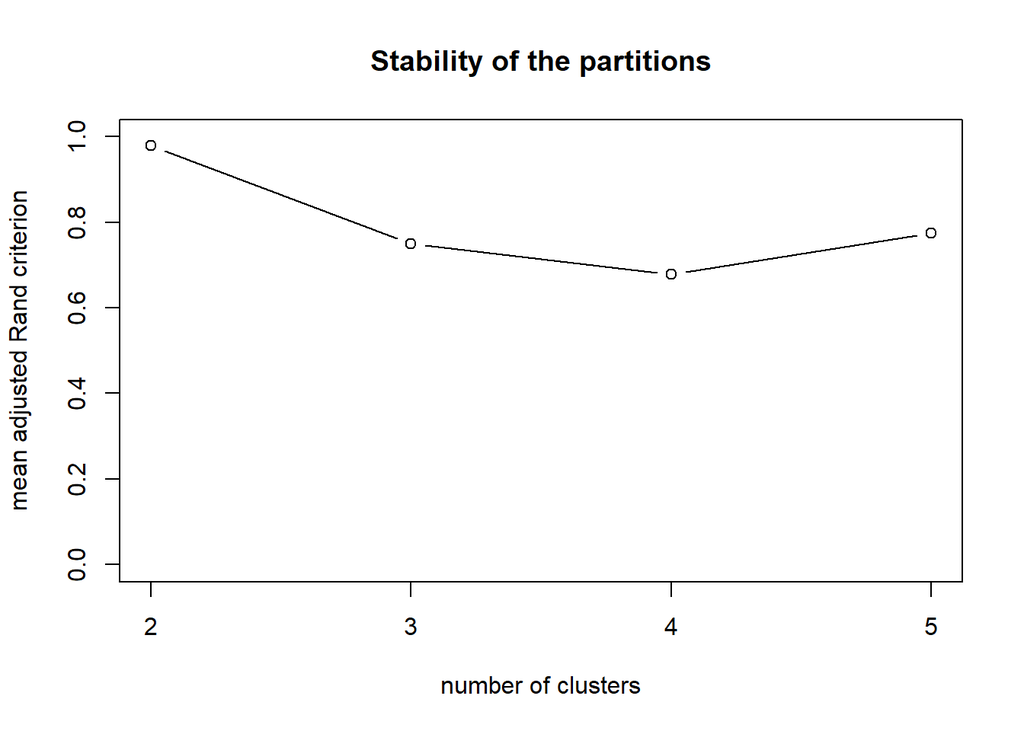

**K-means cluster analysis**:

```
##
## Call:
## kmeansvar(X.quanti = ., init = 5, nstart = 1000)
##
## number of iterations:  1
##
## Data:
##    number of observations:  608
##    number of variables:  6
##    number of clusters:  5
##
## Cluster  1 :
## squared loading     correlation
##               1               1
##
##
## Cluster  2 :
## squared loading     correlation
##               1               1
##
##
## Cluster  3 :
## squared loading     correlation
##               1               1
##
##
## Cluster  4 :
##                                       squared loading correlation
## selfpaced_violation_processing_target            0.68       -0.82
## selfpaced_gardenpath_target                      0.68       -0.82
##
##
## Cluster  5 :
## squared loading     correlation
##               1               1
##
##
## Gain in cohesion (in %):  85.03
```

As a next step, we tested whether these factors show appropriate fit using CFA.

**Confirmatory factor analysis**:

**Fit indices for CFA**:

```
## lavaan 0.6.17 ended normally after 25 iterations
##
##   Estimator                                         ML
##   Optimization method                           NLMINB
##   Number of model parameters                        24
##
##                                                   Used       Total
##   Number of observations                           530         608
##   Number of missing patterns                        21
##
## Model Test User Model:
##                                               Standard      Scaled
##   Test Statistic                                 4.842       5.669
##   Degrees of freedom                                 3           3
##   P-value (Chi-square)                           0.184       0.129
##   Scaling correction factor                                  0.854
##     Yuan-Bentler correction (Mplus variant)
##
## Model Test Baseline Model:
##
##   Test statistic                               182.193     152.145
##   Degrees of freedom                                15          15
##   P-value                                        0.000       0.000
##   Scaling correction factor                                  1.197
##
## User Model versus Baseline Model:
##
##   Comparative Fit Index (CFI)                    0.989       0.981
##   Tucker-Lewis Index (TLI)                       0.945       0.903
##
##   Robust Comparative Fit Index (CFI)                         0.989
##   Robust Tucker-Lewis Index (TLI)                            0.944
##
## Loglikelihood and Information Criteria:
##
##   Loglikelihood user model (H0)              -3578.118   -3578.118
##   Scaling correction factor                                  1.470
##       for the MLR correction
##   Loglikelihood unrestricted model (H1)      -3575.697   -3575.697
##   Scaling correction factor                                  1.401
```

[output cut: 68 more lines]

```
##    .prgmtc_cmprhns    0.096    0.046    2.113    0.035    0.096    0.098
##
## Variances:
##                    Estimate  Std.Err  z-value  P(>|z|)   Std.lv  Std.all
##    .grmmtcl_snstvt    0.000                               0.000    0.000
##    .one_minut_rdng    0.000                               0.000    0.000
##    .prdctv_snt__RT    0.000                               0.000    0.000
##    .slfpcd_grdnpt_    0.678    0.121    5.621    0.000    0.678    0.660
##    .slfpcd_vltn_p_    0.454    0.109    4.175    0.000    0.454    0.614
##    .prgmtc_cmprhns    0.000                               0.000    0.000
##     LANG_MENYET       0.987    0.081   12.189    0.000    1.000    1.000
##     LANG_OMR          0.984    0.087   11.370    0.000    1.000    1.000
##     LANG_pred         1.020    0.042   24.152    0.000    1.000    1.000
##     LANG_space        0.350    0.138    2.536    0.011    1.000    1.000
##     LANG_TROG         0.974    0.073   13.302    0.000    1.000    1.000
```

In conclusion, we used 5 clusters of language related variables to identify latent factors which serve as outcome in the SEM models.

The final structure is:

1. **grammatical sensitivity**
- grammatical_sensitivity [grammatical sensitivity]
2. **reading fluency**
- one_minute_reading [one-minute reading]
3. **semantic prediction**
- predictive_sent_proc_RT [predictive sentence processing - RT]
4. **violation processing**
- selfpaced_gardenpath_target [self-paced reading - garden path sentence processing]
- selfpaced_violation_processing_target [self-paced reading - sentence violation processing]
5. **pragmatic comprehension**
- pragmatic_comprehension [KOBAK - pragmatic comprehension]

### 2.3.5. Summary of the latent factors

**Table 2**

*Latent factors and constituent indices*

[output not shown]

## 2.4. Mediation models (Structural equation modelling)

After the identification of latent factors, we proceeded with assembling the models for mediation analysis. In each model, there was one statistical learning variable, all the core cognitive variables, and the language variables. We specified the models with lavaan syntax. CFA estimator was Robust Maximum Likelihood method. Missing values were imputed using Maximum Likelihood method. An optimal model fit was ascertained based on Comparative Fit Index (CFI) and Tucker-Lewis Index (TLI) values ranging between 0.90–0.95, and an acceptable model fit was indicated by a Root Mean Squared Error of Approximation (RMSEA) index below 0.05 and Standardised Root Mean Square Residual (SRMR) index below 0.08. Inflated indices were expected due to single-item factors.

### 2.4.1. Calculating error variances from reliability indices

### 2.4.2. SEGM RT model

```
## lavaan 0.6.17 ended normally after 70 iterations
##
##   Estimator                                         ML
##   Optimization method                           NLMINB
##   Number of model parameters                       109
##
##   Number of observations                           608
##   Number of missing patterns                       124
##
## Model Test User Model:
##                                               Standard      Scaled
##   Test Statistic                                84.548      83.308
##   Degrees of freedom                                61          61
##   P-value (Chi-square)                           0.025       0.030
##   Scaling correction factor                                  1.015
##     Yuan-Bentler correction (Mplus variant)
##
## Model Test Baseline Model:
##
##   Test statistic                              1601.714    1420.946
##   Degrees of freedom                               136         136
##   P-value                                        0.000       0.000
##   Scaling correction factor                                  1.127
##
## User Model versus Baseline Model:
##
##   Comparative Fit Index (CFI)                    0.984       0.983
##   Tucker-Lewis Index (TLI)                       0.964       0.961
##
##   Robust Comparative Fit Index (CFI)                         0.976
##   Robust Tucker-Lewis Index (TLI)                            0.946
##
## Loglikelihood and Information Criteria:
##
##   Loglikelihood user model (H0)              -9772.859   -9772.859
##   Scaling correction factor                                  1.498
##       for the MLR correction
##   Loglikelihood unrestricted model (H1)      -9730.585   -9730.585
##   Scaling correction factor                                  1.324
##       for the MLR correction
```

[output cut: 277 more lines]

```
##     ind_x1_m2_y4      0.058    0.034    1.718    0.086    0.044    0.044
##     ind_x1_m3_y4      0.071    0.039    1.800    0.072    0.053    0.053
##     ind_x1_m4_y4     -0.008    0.013   -0.596    0.551   -0.006   -0.006
##     ind_x1_m5_y4      0.006    0.013    0.435    0.664    0.004    0.004
##     ind_x1_m6_y4      0.009    0.012    0.726    0.468    0.007    0.007
##     ind_x1_y4         0.124    0.052    2.383    0.017    0.094    0.094
##     tot_x1_y4         0.211    0.102    2.066    0.039    0.159    0.159
##     ind_x1_m1_y5      0.036    0.026    1.382    0.167    0.034    0.034
##     ind_x1_m2_y5      0.045    0.028    1.601    0.109    0.043    0.043
##     ind_x1_m3_y5      0.023    0.030    0.782    0.434    0.022    0.022
##     ind_x1_m4_y5     -0.005    0.012   -0.381    0.703   -0.005   -0.005
##     ind_x1_m5_y5      0.013    0.014    0.876    0.381    0.012    0.012
##     ind_x1_m6_y5     -0.006    0.009   -0.727    0.467   -0.006   -0.006
##     ind_x1_y5         0.107    0.046    2.330    0.020    0.101    0.101
##     tot_x1_y5         0.244    0.093    2.631    0.009    0.231    0.231
```

### 2.4.3. SEGM 2AFC model

```
## lavaan 0.6.17 ended normally after 82 iterations
##
##   Estimator                                         ML
##   Optimization method                           NLMINB
##   Number of model parameters                       110
##
##   Number of observations                           608
##   Number of missing patterns                       121
##
## Model Test User Model:
##                                               Standard      Scaled
##   Test Statistic                                67.303      69.402
##   Degrees of freedom                                60          60
##   P-value (Chi-square)                           0.241       0.190
##   Scaling correction factor                                  0.970
##     Yuan-Bentler correction (Mplus variant)
##
## Model Test Baseline Model:
##
##   Test statistic                              1461.876    1364.847
##   Degrees of freedom                               136         136
##   P-value                                        0.000       0.000
##   Scaling correction factor                                  1.071
##
## User Model versus Baseline Model:
##
##   Comparative Fit Index (CFI)                    0.994       0.992
##   Tucker-Lewis Index (TLI)                       0.988       0.983
##
##   Robust Comparative Fit Index (CFI)                         0.999
##   Robust Tucker-Lewis Index (TLI)                            0.999
##
## Loglikelihood and Information Criteria:
##
##   Loglikelihood user model (H0)              -9893.944   -9893.944
##   Scaling correction factor                                  1.439
##       for the MLR correction
##   Loglikelihood unrestricted model (H1)      -9860.292   -9860.292
##   Scaling correction factor                                  1.273
##       for the MLR correction
```

[output cut: 277 more lines]

```
##     ind_x1_m2_y4      0.088    0.043    2.026    0.043    0.064    0.064
##     ind_x1_m3_y4      0.122    0.053    2.300    0.021    0.088    0.088
##     ind_x1_m4_y4     -0.004    0.031   -0.129    0.897   -0.003   -0.003
##     ind_x1_m5_y4      0.001    0.022    0.055    0.956    0.001    0.001
##     ind_x1_m6_y4      0.020    0.021    0.961    0.336    0.015    0.015
##     ind_x1_y4         0.216    0.068    3.191    0.001    0.157    0.157
##     tot_x1_y4         0.007    0.129    0.055    0.956    0.005    0.005
##     ind_x1_m1_y5      0.057    0.034    1.652    0.099    0.051    0.051
##     ind_x1_m2_y5      0.060    0.033    1.802    0.072    0.054    0.054
##     ind_x1_m3_y5      0.031    0.040    0.776    0.438    0.029    0.029
##     ind_x1_m4_y5     -0.022    0.033   -0.663    0.507   -0.020   -0.020
##     ind_x1_m5_y5      0.023    0.021    1.075    0.282    0.021    0.021
##     ind_x1_m6_y5     -0.020    0.022   -0.890    0.374   -0.018   -0.018
##     ind_x1_y5         0.130    0.050    2.570    0.010    0.118    0.118
##     tot_x1_y5         0.288    0.145    1.982    0.048    0.262    0.262
```

### 2.4.4. SEGM production model

```
## lavaan 0.6.17 ended normally after 63 iterations
##
##   Estimator                                         ML
##   Optimization method                           NLMINB
##   Number of model parameters                       106
##
##   Number of observations                           608
##   Number of missing patterns                       121
##
## Model Test User Model:
##                                               Standard      Scaled
##   Test Statistic                                55.453      57.743
##   Degrees of freedom                                46          46
##   P-value (Chi-square)                           0.160       0.115
##   Scaling correction factor                                  0.960
##     Yuan-Bentler correction (Mplus variant)
##
## Model Test Baseline Model:
##
##   Test statistic                              1475.241    1360.985
##   Degrees of freedom                               120         120
##   P-value                                        0.000       0.000
##   Scaling correction factor                                  1.084
##
## User Model versus Baseline Model:
##
##   Comparative Fit Index (CFI)                    0.993       0.991
##   Tucker-Lewis Index (TLI)                       0.982       0.975
##
##   Robust Comparative Fit Index (CFI)                         0.996
##   Robust Tucker-Lewis Index (TLI)                            0.989
##
## Loglikelihood and Information Criteria:
##
##   Loglikelihood user model (H0)              -9463.689   -9463.689
##   Scaling correction factor                                  1.458
##       for the MLR correction
##   Loglikelihood unrestricted model (H1)      -9435.962   -9435.962
##   Scaling correction factor                                  1.308
##       for the MLR correction
```

[output cut: 273 more lines]

```
##     ind_x1_m2_y4      0.070    0.033    2.140    0.032    0.066    0.066
##     ind_x1_m3_y4      0.081    0.035    2.309    0.021    0.076    0.076
##     ind_x1_m4_y4     -0.028    0.027   -1.039    0.299   -0.027   -0.027
##     ind_x1_m5_y4      0.014    0.023    0.612    0.540    0.013    0.013
##     ind_x1_m6_y4      0.020    0.020    0.971    0.331    0.019    0.019
##     ind_x1_y4         0.118    0.047    2.486    0.013    0.111    0.111
##     tot_x1_y4         0.239    0.066    3.603    0.000    0.225    0.225
##     ind_x1_m1_y5      0.062    0.032    1.938    0.053    0.074    0.074
##     ind_x1_m2_y5      0.049    0.029    1.701    0.089    0.058    0.058
##     ind_x1_m3_y5      0.027    0.031    0.888    0.375    0.032    0.032
##     ind_x1_m4_y5     -0.024    0.024   -1.007    0.314   -0.028   -0.028
##     ind_x1_m5_y5      0.026    0.021    1.225    0.221    0.031    0.031
##     ind_x1_m6_y5     -0.024    0.021   -1.173    0.241   -0.029   -0.029
##     ind_x1_y5         0.117    0.038    3.112    0.002    0.138    0.138
##     tot_x1_y5         0.336    0.063    5.339    0.000    0.396    0.396
```

### 2.4.5. AGL model

```
## lavaan 0.6.17 ended normally after 86 iterations
##
##   Estimator                                         ML
##   Optimization method                           NLMINB
##   Number of model parameters                       110
##
##                                                   Used       Total
##   Number of observations                           606         608
##   Number of missing patterns                       119
##
## Model Test User Model:
##                                               Standard      Scaled
##   Test Statistic                                71.251      74.095
##   Degrees of freedom                                60          60
##   P-value (Chi-square)                           0.152       0.104
##   Scaling correction factor                                  0.962
##     Yuan-Bentler correction (Mplus variant)
##
## Model Test Baseline Model:
##
##   Test statistic                              1511.908    1427.456
##   Degrees of freedom                               136         136
##   P-value                                        0.000       0.000
##   Scaling correction factor                                  1.059
##
## User Model versus Baseline Model:
##
##   Comparative Fit Index (CFI)                    0.992       0.989
##   Tucker-Lewis Index (TLI)                       0.981       0.975
##
##   Robust Comparative Fit Index (CFI)                         0.995
##   Robust Tucker-Lewis Index (TLI)                            0.988
##
## Loglikelihood and Information Criteria:
##
##   Loglikelihood user model (H0)              -9808.012   -9808.012
##   Scaling correction factor                                  1.428
##       for the MLR correction
##   Loglikelihood unrestricted model (H1)      -9772.386   -9772.386
##   Scaling correction factor                                  1.263
```

[output cut: 278 more lines]

```
##     ind_x1_m2_y4      0.126    0.055    2.301    0.021    0.080    0.080
##     ind_x1_m3_y4      0.144    0.080    1.789    0.074    0.091    0.091
##     ind_x1_m4_y4     -0.079    0.064   -1.241    0.214   -0.050   -0.050
##     ind_x1_m5_y4      0.004    0.067    0.060    0.952    0.003    0.003
##     ind_x1_m6_y4      0.035    0.038    0.912    0.362    0.022    0.022
##     ind_x1_y4         0.114    0.134    0.855    0.393    0.072    0.072
##     tot_x1_y4         0.523    0.124    4.231    0.000    0.331    0.331
##     ind_x1_m1_y5      0.064    0.073    0.885    0.376    0.051    0.051
##     ind_x1_m2_y5      0.101    0.049    2.075    0.038    0.080    0.080
##     ind_x1_m3_y5      0.017    0.077    0.217    0.829    0.013    0.013
##     ind_x1_m4_y5     -0.078    0.059   -1.331    0.183   -0.062   -0.062
##     ind_x1_m5_y5      0.033    0.060    0.551    0.581    0.026    0.026
##     ind_x1_m6_y5     -0.050    0.047   -1.068    0.286   -0.040   -0.040
##     ind_x1_y5         0.087    0.123    0.709    0.478    0.069    0.069
##     tot_x1_y5         0.649    0.143    4.545    0.000    0.515    0.515
```

### 2.4.6. AGL phrase model

```
## lavaan 0.6.17 ended normally after 66 iterations
##
##   Estimator                                         ML
##   Optimization method                           NLMINB
##   Number of model parameters                       106
##
##                                                   Used       Total
##   Number of observations                           606         608
##   Number of missing patterns                       119
##
## Model Test User Model:
##                                               Standard      Scaled
##   Test Statistic                                57.614      59.878
##   Degrees of freedom                                46          46
##   P-value (Chi-square)                           0.117       0.082
##   Scaling correction factor                                  0.962
##     Yuan-Bentler correction (Mplus variant)
##
## Model Test Baseline Model:
##
##   Test statistic                              1401.751    1302.775
##   Degrees of freedom                               120         120
##   P-value                                        0.000       0.000
##   Scaling correction factor                                  1.076
##
## User Model versus Baseline Model:
##
##   Comparative Fit Index (CFI)                    0.991       0.988
##   Tucker-Lewis Index (TLI)                       0.976       0.969
##
##   Robust Comparative Fit Index (CFI)                         0.992
##   Robust Tucker-Lewis Index (TLI)                            0.979
##
## Loglikelihood and Information Criteria:
##
##   Loglikelihood user model (H0)              -9486.081   -9486.081
##   Scaling correction factor                                  1.451
##       for the MLR correction
##   Loglikelihood unrestricted model (H1)      -9457.274   -9457.274
##   Scaling correction factor                                  1.303
```

[output cut: 274 more lines]

```
##     ind_x1_m2_y4      0.032    0.022    1.427    0.154    0.031    0.031
##     ind_x1_m3_y4      0.039    0.023    1.728    0.084    0.038    0.038
##     ind_x1_m4_y4     -0.008    0.015   -0.569    0.569   -0.008   -0.008
##     ind_x1_m5_y4      0.006    0.015    0.429    0.668    0.006    0.006
##     ind_x1_m6_y4      0.015    0.014    1.077    0.282    0.015    0.015
##     ind_x1_y4         0.076    0.038    2.010    0.044    0.073    0.073
##     tot_x1_y4         0.002    0.064    0.028    0.978    0.002    0.002
##     ind_x1_m1_y5      0.036    0.019    1.858    0.063    0.044    0.044
##     ind_x1_m2_y5      0.026    0.017    1.552    0.121    0.031    0.031
##     ind_x1_m3_y5      0.016    0.016    1.003    0.316    0.019    0.019
##     ind_x1_m4_y5     -0.009    0.014   -0.597    0.550   -0.010   -0.010
##     ind_x1_m5_y5      0.013    0.014    0.920    0.358    0.016    0.016
##     ind_x1_m6_y5     -0.015    0.014   -1.079    0.280   -0.019   -0.019
##     ind_x1_y5         0.066    0.031    2.111    0.035    0.081    0.081
##     tot_x1_y5         0.156    0.066    2.351    0.019    0.190    0.190
```

### 2.4.7. Unified model

We also tested a unified model With all the variables for calculating total effect sizes.

```
## lavaan 0.6.17 ended normally after 103 iterations
##
##   Estimator                                         ML
##   Optimization method                           NLMINB
##   Number of model parameters                       180
##
##   Number of observations                           608
##   Number of missing patterns                       150
##
## Model Test User Model:
##                                               Standard      Scaled
##   Test Statistic                               138.833     139.724
##   Degrees of freedom                               119         119
##   P-value (Chi-square)                           0.103       0.094
##   Scaling correction factor                                  0.994
##     Yuan-Bentler correction (Mplus variant)
##
## Model Test Baseline Model:
##
##   Test statistic                              2019.388    1927.308
##   Degrees of freedom                               253         253
##   P-value                                        0.000       0.000
##   Scaling correction factor                                  1.048
##
## User Model versus Baseline Model:
##
##   Comparative Fit Index (CFI)                    0.989       0.988
##   Tucker-Lewis Index (TLI)                       0.976       0.974
##
##   Robust Comparative Fit Index (CFI)                         0.986
##   Robust Tucker-Lewis Index (TLI)                            0.970
##
## Loglikelihood and Information Criteria:
##
##   Loglikelihood user model (H0)             -11891.083  -11891.083
##   Scaling correction factor                                  1.277
##       for the MLR correction
##   Loglikelihood unrestricted model (H1)     -11821.666  -11821.666
##   Scaling correction factor                                  1.164
##       for the MLR correction
```

[output cut: 536 more lines]

```
##     ind_y1            0.242    0.169    1.437    0.151    0.215    0.215
##     tot_y1            0.592    0.148    4.006    0.000    0.551    0.551
##     ind_y2            0.233    0.171    1.365    0.172    0.174    0.174
##     tot_y2            0.389    0.132    2.941    0.003    0.253    0.253
##     ind_y3            0.292    0.126    2.310    0.021    0.340    0.340
##     tot_y3            0.409    0.128    3.200    0.001    0.491    0.491
##     ind_y4            0.151    0.179    0.840    0.401    0.117    0.117
##     tot_y4            0.530    0.161    3.298    0.001    0.308    0.308
##     ind_y5           -0.004    0.158   -0.028    0.978   -0.009   -0.009
##     tot_y5            0.838    0.145    5.782    0.000    0.617    0.617
##     dir_y1            0.349    0.262    1.335    0.182    0.336    0.336
##     dir_y2            0.156    0.255    0.612    0.541    0.079    0.079
##     dir_y3            0.117    0.187    0.626    0.531    0.152    0.152
##     dir_y4            0.379    0.278    1.365    0.172    0.191    0.191
##     dir_y5            0.842    0.255    3.302    0.001    0.625    0.625
```

### 2.4.8. Summary of mediation models

**Table 3**

*Fit indices of mediation models*

[output not shown]

*Note.* CFI: = Comparative Fit Index, R-CFI: = Robust Comparative Fit Index, TLI: = Tucker-Lewis Index, R-TLI: = Robust Tucker-Lewis Index, R-RMSEA: = Robust Root Mean Square Error of Approximation, SRMR: = Standardised Root Mean Square Residual.

**Table 4**

*Reliability values and average variance extracted (AVE) for latent variables*

```
##               SL        PS        DS     nback     space
## alpha  0.8077133 0.6682169 0.7364526 0.7232017 0.5475425
## omega  0.8118431 0.7063183 0.7385981 0.7258170 0.5516098
## omega2 0.8118431 0.7063183 0.7385981 0.7258170 0.5516098
## omega3 0.8166808 0.7066088 0.7401475 0.7278632 0.5526353
## avevar 0.6832794 0.5587744 0.5859091 0.5702113 0.3814531
```

```
##               SL        PS        DS     nback     space
## alpha  0.5012591 0.6677011 0.7369455 0.7233994 0.5472432
## omega  0.5299047 0.7099418 0.7388099 0.7244745 0.5514447
## omega2 0.5299047 0.7099418 0.7388099 0.7244745 0.5514447
## omega3 0.5333164 0.7109013 0.7386264 0.7256744 0.5526423
## avevar 0.3709744 0.5641746 0.5863060 0.5681176 0.3813551
```

```
##               PS        DS     nback     space
## alpha  0.6680699 0.7380848 0.7241626 0.5473102
## omega  0.7087217 0.7384017 0.7253163 0.5525492
## omega2 0.7087217 0.7384017 0.7253163 0.5525492
## omega3 0.7094922 0.7377250 0.7263510 0.5534455
## avevar 0.5623114 0.5853538 0.5692065 0.3829200
```

```
##               SL        PS        DS     nback     space
## alpha  0.5663102 0.6681104 0.7363956 0.7237570 0.5474969
## omega  0.5662470 0.7078870 0.7392167 0.7255615 0.5523362
## omega2 0.5662470 0.7078870 0.7392167 0.7255615 0.5523362
## omega3 0.5666714 0.7086507 0.7393525 0.7262851 0.5533155
## avevar 0.3952071 0.5610544 0.5870499 0.5697819 0.3822126
```

```
##               PS        DS     nback     space
## alpha  0.6678463 0.7370114 0.7236242 0.5470431
## omega  0.7086385 0.7386214 0.7244436 0.5547384
## omega2 0.7086385 0.7386214 0.7244436 0.5547384
## omega3 0.7094435 0.7382343 0.7256873 0.5549339
## avevar 0.5622686 0.5860036 0.5679927 0.3862661
```

```
##            SL_RT    SL_AGL SL_SEGM_tribi        PS        DS     nback
## alpha  0.8085921 0.5614387     0.5007022 0.6684070 0.7364038 0.7235658
## omega  0.8365184 0.5639711     0.5657442 0.7107002 0.7381923 0.7247922
## omega2 0.8365184 0.5639711     0.5657442 0.7107002 0.7381923 0.7247922
## omega3 0.8402186 0.5645076     0.5705196 0.7117329 0.7404806 0.7258820
## avevar 0.7246914 0.3928100     0.4183160 0.5651502 0.5851824 0.5685826
##            space
## alpha  0.5459158
## omega  0.5525150
## omega2 0.5525150
## omega3 0.5540614
## avevar 0.3832474
```

**Table 5**

*Mediation models*

[output not shown]

*Note.* *: p < .05, **: p < .01, ***: p < .001

## 2.5. Complementary models for testing reversed pathways

### 2.5.1. Reversed independent - mediator model

```
## lavaan 0.6.17 ended normally after 59 iterations
##
##   Estimator                                         ML
##   Optimization method                           NLMINB
##   Number of model parameters                        64
##
##                                                   Used       Total
##   Number of observations                           595         608
##   Number of missing patterns                        89
##
## Model Test User Model:
##                                               Standard      Scaled
##   Test Statistic                               464.455     456.601
##   Degrees of freedom                               106         106
##   P-value (Chi-square)                           0.000       0.000
##   Scaling correction factor                                  1.017
##     Yuan-Bentler correction (Mplus variant)
##
## Model Test Baseline Model:
##
##   Test statistic                              1544.894    1443.782
##   Degrees of freedom                               136         136
##   P-value                                        0.000       0.000
##   Scaling correction factor                                  1.070
##
## User Model versus Baseline Model:
##
##   Comparative Fit Index (CFI)                    0.746       0.732
##   Tucker-Lewis Index (TLI)                       0.674       0.656
##
##   Robust Comparative Fit Index (CFI)                         0.803
##   Robust Tucker-Lewis Index (TLI)                            0.747
##
## Loglikelihood and Information Criteria:
##
##   Loglikelihood user model (H0)              -8624.348   -8624.348
##   Scaling correction factor                                  1.574
##       for the MLR correction
##   Loglikelihood unrestricted model (H1)      -8392.120   -8392.120
##   Scaling correction factor                                  1.227
```

[output cut: 145 more lines]

```
##     AGL_2AFC_phras    1.000
##     prcptl_spd__RT    0.550
##     prcptl_spd__RT    0.259
##     digt_spn_frwrd    0.198
##     dgt_spn_bckwrd    0.183
##     nbck_2_bck_dpr    0.168
##     nbck_3_bck_dpr    0.154
##     stroop_RT         0.235
##     simon_RT          0.360
##     prcptl_spd_vs_    0.573
##     SL_RT             0.044
##     SL_AGL            0.466
##     SL_SEGM_prod      0.208
##     SL_SEGM_tribi     0.118
##     SL_phr            0.057
```

### 2.5.2. Reversed mediator - dependent model

```
## lavaan 0.6.17 ended normally after 44 iterations
##
##   Estimator                                         ML
##   Optimization method                           NLMINB
##   Number of model parameters                        56
##
##                                                   Used       Total
##   Number of observations                           606         608
##   Number of missing patterns                       100
##
## Model Test User Model:
##                                               Standard      Scaled
##   Test Statistic                               432.889     413.026
##   Degrees of freedom                                79          79
##   P-value (Chi-square)                           0.000       0.000
##   Scaling correction factor                                  1.048
##     Yuan-Bentler correction (Mplus variant)
##
## Model Test Baseline Model:
##
##   Test statistic                              1374.724    1249.966
##   Degrees of freedom                               105         105
##   P-value                                        0.000       0.000
##   Scaling correction factor                                  1.100
##
## User Model versus Baseline Model:
##
##   Comparative Fit Index (CFI)                    0.721       0.708
##   Tucker-Lewis Index (TLI)                       0.630       0.612
##
##   Robust Comparative Fit Index (CFI)                         0.771
##   Robust Tucker-Lewis Index (TLI)                            0.695
##
## Loglikelihood and Information Criteria:
##
##   Loglikelihood user model (H0)              -9316.929   -9316.929
##   Scaling correction factor                                  1.780
##       for the MLR correction
##   Loglikelihood unrestricted model (H1)      -9100.484   -9100.484
##   Scaling correction factor                                  1.352
```

[output cut: 138 more lines]

```
##     nbck_3_bck_dpr    0.134
##     stroop_RT         0.243
##     simon_RT          0.371
##     prcptl_spd_vs_    0.601
##     grmmtcl_snstvt    1.000
##     prdctv_snt__RT    1.000
##     slfpcd_grdnpt_    0.359
##     slfpcd_vltn_p_    0.405
##     one_minut_rdng    1.000
##     prgmtc_cmprhns    1.000
##     MENYET            0.160
##     pred              0.077
##     space             0.223
##     OMR               0.155
##     TROG              0.132
```

## 2.6. Latent factor identification without predefined domains

### 2.6.1. Summary for the process of latent factor identification

To identify latent factors wtih a purely data-driven approach, we did not categorised the measurement indices into domains, as we have done so in our main model. Instead, we allowed all indices in the same statistical models.

Our classification method was the following:

### 2.6.2. Latent factors without domain specification

**Kaiser-Meyer-Olkin test**:

```
## ℹ 'x' was not a correlation matrix. Correlations are found from entered raw data.
```

```
##
## ── Kaiser-Meyer-Olkin criterion (KMO) ──────────────────────────────────────────
##
## ! The overall KMO value for your data is mediocre.
##   These data are probably suitable for factor analysis.
##
##   Overall: 0.661
##
##   For each variable:
##                      SEGM_RT_training                     SEGM_RT_TRN3_RND4
##                                 0.579                                 0.515
##                     SEGM_RT_RND4_REC5                     SEGM_ACC_training
##                                 0.554                                 0.348
##                    SEGM_ACC_TRN3_RND4                    SEGM_ACC_RND4_REC5
##                                 0.418                                 0.351
##                      SEGM_2AFC_bigram                     SEGM_2AFC_trigram
##                                 0.577                                 0.692
##                       SEGM_production                      AGL_ACC_training
##                                 0.739                                 0.423
##                       AGL_2AFC_phrase                     AGL_2AFC_sentence
##                                 0.649                                 0.853
##                        AGL_production            perceptual_speed_visual_RT
##                                 0.703                                 0.750
##          perceptual_speed_auditory_RT      perceptual_speed_visual_decision
##                                 0.676                                 0.871
##                    digit_span_forward                   digit_span_backward
##                                 0.752                                 0.655
##                   nback_1_back_dprime                   nback_2_back_dprime
##                                 0.714                                 0.681
##                   nback_3_back_dprime                             stroop_RT
##                                 0.726                                 0.770
##                       stroop_accuracy                              simon_RT
##                                 0.657                                 0.761
##                        simon_accuracy               grammatical_sensitivity
##                                 0.436                                 0.713
##                    one_minute_reading               predictive_sent_proc_RT
##                                 0.705                                 0.751
##         predictive_sent_proc_accuracy           selfpaced_gardenpath_target
##                                 0.487                                 0.622
## selfpaced_violation_processing_target               pragmatic_comprehension
##                                 0.681                                 0.820
```

The previously identified indices with unsatisfactory fit for EFA (MSA < 0.5) show similarly worse fit in this model resulting in their exclusion: - SEGM_ACC_training [speech segmentation - SEGM ACC training] - SEGM_ACC_TRN3_RND4 [speech segmentation - SEGM ACC TRN3-RND4] - SEGM_ACC_RND4_REC5 [speech segmentation - SEGM ACC RND4-REC5] - AGL_ACC_training [artificial grammar learning - AGL ACC training]

After their exclusion, KMO test was repeated.

```
## ℹ 'x' was not a correlation matrix. Correlations are found from entered raw data.
```

```
##
## ── Kaiser-Meyer-Olkin criterion (KMO) ──────────────────────────────────────────
##
## ✔ The overall KMO value for your data is middling.
##   These data are probably suitable for factor analysis.
##
##   Overall: 0.707
##
##   For each variable:
##                      SEGM_RT_training                     SEGM_RT_TRN3_RND4
##                                 0.608                                 0.526
##                     SEGM_RT_RND4_REC5                      SEGM_2AFC_bigram
##                                 0.570                                 0.595
##                     SEGM_2AFC_trigram                       SEGM_production
##                                 0.695                                 0.799
##                       AGL_2AFC_phrase                     AGL_2AFC_sentence
##                                 0.650                                 0.869
##                        AGL_production            perceptual_speed_visual_RT
##                                 0.708                                 0.753
##          perceptual_speed_auditory_RT      perceptual_speed_visual_decision
##                                 0.686                                 0.888
##                    digit_span_forward                   digit_span_backward
##                                 0.758                                 0.652
##                   nback_1_back_dprime                   nback_2_back_dprime
##                                 0.766                                 0.682
##                   nback_3_back_dprime                             stroop_RT
##                                 0.742                                 0.770
##                       stroop_accuracy                              simon_RT
##                                 0.653                                 0.807
##                        simon_accuracy               grammatical_sensitivity
##                                 0.469                                 0.733
##                    one_minute_reading               predictive_sent_proc_RT
##                                 0.726                                 0.767
##         predictive_sent_proc_accuracy           selfpaced_gardenpath_target
##                                 0.479                                 0.640
## selfpaced_violation_processing_target               pragmatic_comprehension
##                                 0.672                                 0.821
```

The reaction time based indices showed poor fit (< 0.6), however, we did not omit them for their possible exploratory power. To stick to the data-driven approach, we did not divided the variables into neither domains, nor subclasses (i.e. RT vs. powertests).

**Bartlett’s test**:

```
## ℹ 'x' was not a correlation matrix. Correlations are found from entered raw data.
```

```
##
## ✔ The Bartlett's test of sphericity was significant at an alpha level of .05.
##   These data are probably suitable for factor analysis.
##
##   𝜒²(378) = 4363.58, p < .001
```

**Parallel analysis**:

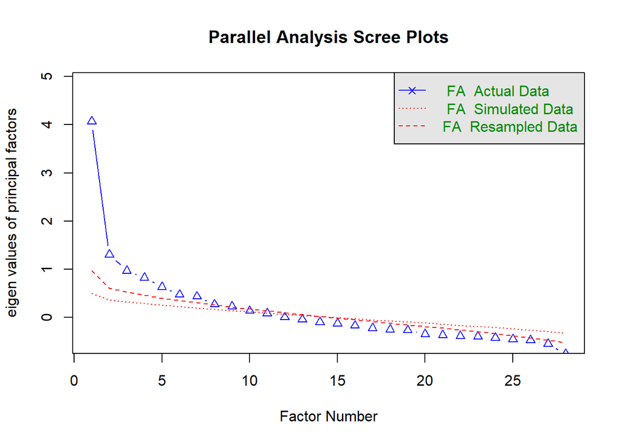

```
## Parallel analysis suggests that the number of factors =  10  and the number of components =  NA
```

Parallel analysis suggests that the number of factors formed should be 10. Notice that based on the scree plot, one factor emerges as a crucial latent variable. This could be due to the well-described phenomenon of the positive manifold in cognitive abilities in which the solitary factor would be the g factor (independent of whether we see it as a formative or reflective variable, for further details see Process Overlap Theory (Kovacs & Conway, 2016))

**Exploratory factor analysis**:

```
##
## Factor analysis with Call: fa(r = ., nfactors = 10, rotate = "Promax", scores = "regression",
##     missing = TRUE, impute = "mean", fm = "ml", use = "pairwise",
##     cor = "cor")
##
## Test of the hypothesis that 10 factors are sufficient.
## The degrees of freedom for the model is 143  and the objective function was  0.62
## The number of observations was  608  with Chi Square =  365.9  with prob <  1.8e-21
##
## The root mean square of the residuals (RMSA) is  0.03
## The df corrected root mean square of the residuals is  0.05
##
## Tucker Lewis Index of factoring reliability =  0.85
## RMSEA index =  0.051  and the 10 % confidence intervals are  0.044 0.057
## BIC =  -550.76
##  With factor correlations of
##        ML3  ML6  ML5   ML2  ML9  ML4  ML1  ML8   ML7  ML10
## ML3   1.00 0.10 0.08 -0.01 0.07 0.15 0.04 0.14 -0.02 -0.04
## ML6   0.10 1.00 0.34  0.34 0.49 0.41 0.28 0.48  0.30  0.27
## ML5   0.08 0.34 1.00  0.18 0.28 0.29 0.25 0.15  0.22  0.17
## ML2  -0.01 0.34 0.18  1.00 0.40 0.34 0.22 0.09  0.27  0.21
## ML9   0.07 0.49 0.28  0.40 1.00 0.52 0.29 0.33  0.41  0.32
## ML4   0.15 0.41 0.29  0.34 0.52 1.00 0.31 0.26  0.43  0.41
## ML1   0.04 0.28 0.25  0.22 0.29 0.31 1.00 0.16  0.30  0.46
## ML8   0.14 0.48 0.15  0.09 0.33 0.26 0.16 1.00  0.18  0.30
## ML7  -0.02 0.30 0.22  0.27 0.41 0.43 0.30 0.18  1.00  0.34
## ML10 -0.04 0.27 0.17  0.21 0.32 0.41 0.46 0.30  0.34  1.00
```

```
##
## Loadings:
##                                       ML3    ML6    ML5    ML2    ML9    ML4
## SEGM_RT_training                       0.708                       0.162
## SEGM_RT_TRN3_RND4                      0.961
## SEGM_RT_RND4_REC5                      0.551
## SEGM_2AFC_bigram                             -0.110
## SEGM_2AFC_trigram
## SEGM_production                                                           1.072
## AGL_2AFC_phrase                       -0.101                       0.494
## AGL_2AFC_sentence                             0.106                0.551
## AGL_production                                                     0.691 -0.129
## perceptual_speed_visual_RT                    0.914
## perceptual_speed_auditory_RT                  0.722
## perceptual_speed_visual_decision              0.542
## digit_span_forward                            0.130         0.507         0.130
## digit_span_backward                                         1.016
## nback_1_back_dprime                           0.104  0.510
## nback_2_back_dprime                                  0.921
## nback_3_back_dprime                                  0.618
## stroop_RT
## stroop_accuracy
## simon_RT                                      0.246
## simon_accuracy                               -0.177
## grammatical_sensitivity               -0.210                              0.222
## one_minute_reading                                                        0.177
## predictive_sent_proc_RT                       0.207                0.136 -0.131
## predictive_sent_proc_accuracy         -0.135  0.196               -0.178
## selfpaced_gardenpath_target                                        0.128 -0.106
## selfpaced_violation_processing_target        -0.201
## pragmatic_comprehension                                            0.341  0.188
##                                       ML1    ML8    ML7    ML10
## SEGM_RT_training
## SEGM_RT_TRN3_RND4                                           0.343
## SEGM_RT_RND4_REC5                                           0.739
## SEGM_2AFC_bigram                       0.247                0.247
## SEGM_2AFC_trigram                      1.049
## SEGM_production
## AGL_2AFC_phrase                                            -0.129
## AGL_2AFC_sentence                                           0.112
```

[output cut: 10 more lines]

```
## stroop_accuracy                              -0.114  0.684
## simon_RT                                      0.144  0.338
## simon_accuracy                         0.146 -0.108  0.228
## grammatical_sensitivity                0.117         0.144  0.171
## one_minute_reading                    -0.107  0.476  0.112
## predictive_sent_proc_RT                                     0.153
## predictive_sent_proc_accuracy          0.134  0.196 -0.172
## selfpaced_gardenpath_target                   0.568
## selfpaced_violation_processing_target         0.726
## pragmatic_comprehension                                     0.187
##
##                  ML3   ML6   ML5   ML2   ML9   ML4   ML1   ML8   ML7  ML10
## SS loadings    1.850 1.956 1.546 1.371 1.282 1.362 1.298 1.255 1.223 0.908
## Proportion Var 0.066 0.070 0.055 0.049 0.046 0.049 0.046 0.045 0.044 0.032
## Cumulative Var 0.066 0.136 0.191 0.240 0.286 0.335 0.381 0.426 0.469 0.502
```

```
## # A tibble: 28 × 2
##    names                            x
##    <chr>                        <dbl>
##  1 SEGM_RT_training           0.415
##  2 SEGM_RT_TRN3_RND4          0.00499
##  3 SEGM_RT_RND4_REC5          0.318
##  4 SEGM_2AFC_bigram           0.806
##  5 SEGM_2AFC_trigram          0.00500
##  6 SEGM_production            0.00500
##  7 AGL_2AFC_phrase            0.778
##  8 AGL_2AFC_sentence          0.611
##  9 AGL_production             0.549
## 10 perceptual_speed_visual_RT 0.309
## # ℹ 18 more rows
```

| theoretical domain | index | data driven latent factor |
| --- | --- | --- |
| SL | SEGM RT TRN3–RND4 | SEGM RT |
| SL | SEGM RT RND4–REC5 | SEGM RT |
| SL | SEGM RT train | SEGM RT |
| SL | SEGM 2AFC bigram | SEGM 2AFC |
| SL | SEGM 2AFC trigram | SEGM 2AFC |
| SL | SEGM production | SEGM production |
| SL | AGL 2AFC sentence | AGL |
| SL | AGL 2AFC production | AGL |
| SL | AGL phrase | AGL |
| LANG | garden path sentence processing | reading |
| LANG | sentence violation processing | reading |
| LANG | one minute reading | reading |
| COG | visual reaction time | perceptual speed |
| COG | auditory reaction time | perceptual speed |
| COG | visual decision time | perceptual speed |
| COG | forward digit span | digit span |
| COG | backward digit span | digit span |
| COG | 2-back d-prime | nback |
| COG | 3-back d-prime | nback |
| COG | Stroop RT | Stroop |

To assess the hierarchical structure of all indices, we performed hierarchical cluster analysis as well.

**Hierarchical cluster analysis**:

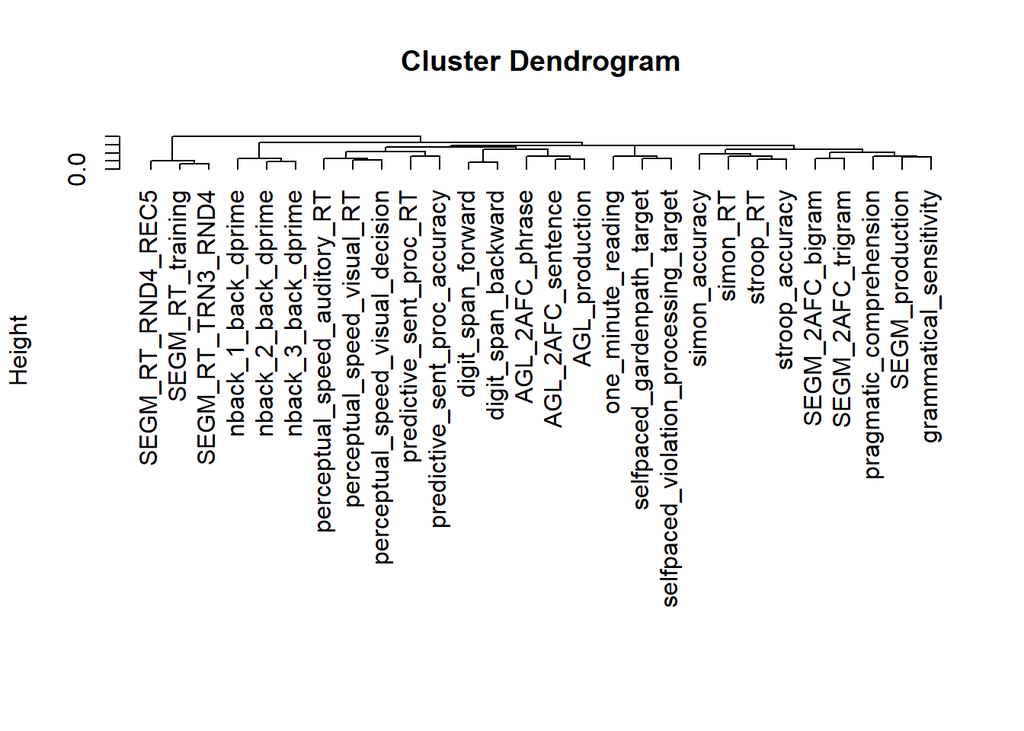

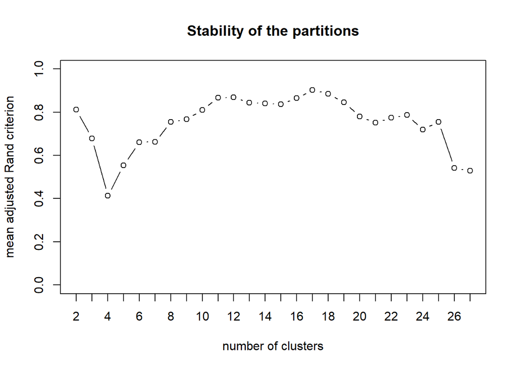

Since the Rand criterion shows that there is two local maxima (at 11-12 and 17) regarding the number of clusters, we selected the smaller number to get more information about the relationship of the indices.

**K-means cluster analysis**:

```
##
## Call:
## kmeansvar(X.quanti = ., init = 12, nstart = 1000)
##
## number of iterations:  1
##
## Data:
##    number of observations:  608
##    number of variables:  28
##    number of clusters:  12
##
## Cluster  1 :
##                   squared loading correlation
## SEGM_RT_TRN3_RND4            0.89       -0.94
## SEGM_RT_training             0.64       -0.80
## SEGM_RT_RND4_REC5            0.64       -0.80
##
##
## Cluster  2 :
##                   squared loading correlation
## SEGM_2AFC_trigram            0.67       -0.82
## SEGM_2AFC_bigram             0.67       -0.82
##
##
## Cluster  3 :
##                   squared loading correlation
## AGL_production               0.59       -0.77
## AGL_2AFC_sentence            0.59       -0.77
## AGL_2AFC_phrase              0.42       -0.65
##
##
## Cluster  4 :
##                                  squared loading correlation
## perceptual_speed_visual_RT                  0.71       -0.85
## perceptual_speed_visual_decision            0.56       -0.78
## perceptual_speed_auditory_RT                0.56       -0.75
##
##
## Cluster  5 :
##                     squared loading correlation
```

[output cut: 33 more lines]

```
##
##
## Cluster  11 :
## squared loading     correlation
##               1               1
##
##
## Cluster  12 :
##                                       squared loading correlation
## selfpaced_violation_processing_target            0.57        0.76
## selfpaced_gardenpath_target                      0.57        0.76
## one_minute_reading                               0.43        0.67
##
##
## Gain in cohesion (in %):  58.62
```

In conclusion, the hierarchical cluster shows similar clusters to both the novel EFA results and to the main model on a fine-grained level. However, the higher we go in the tree, the more mixed up the structure is. Notable, the indices of the three domains get scrambled, for instance SEGM production is closest to grammatical sensitivity, the AGL indices are closest to digit span indices. The results suggest an inconclusive higher level structure, which would prevent us from conducting either an ordinary latent variable regression or a more complex mediation analysis.

## 2.7. Exploring developmental effects

### 2.7.1. Data preparation

To perform invariance tests, we created subsamples based on age.

```r
df_all = df %>%
  mutate(age_group = case_when(
    age_years > 18 & age_years < 26 ~ "young_adult",
    age_years < 18 ~ "child",
    age_years >= 26 ~ "adult"
  ))

df_invtest = df_all %>%
  filter(age_group == "young_adult" | age_group == "adult")
```

### 2.7.2. Summary

Invariance test are used to assess whether a proposed structure of the model would hold between different groups of responders. There are usually three types of invariance tests performed to assess different parameters of a structure: - configural invariance: it assumes similar structure between latent and manifest variables across samples, - metric invariance: it assumes not only similar structure, but similar factor loadings between latent and manifest variables across samples, - scalar invariance: it assumes similar structure, similar factor loadings, and similar intercepts across samples. The three invariance tests are nested suggesting that if metric invariance holds, then configural invariance holds as well, and when scalar invariance holds, the other two invariance holds as well.

We conducted two approaches in testing invariance. First, we assessed the latent variable structure for three samples: all participants, young adults (18 < age < 26), and other adults (26 <= age). Participants under 18 years were not sorted into a separate group due to their small sample size. Second, we tested the three types of invariances across young adults and other adults.

### 2.7.3. Models testing invariance

#### 2.7.3.1. SEGM RT model

##### 2.7.3.1.1. Structure

```r
model_RT =
"
# statistical learning
SL =~ 1*SEGM_RT_TRN3_RND4 + 1*SEGM_RT_RND4_REC5

# cognitive
PS =~ perceptual_speed_visual_RT + perceptual_speed_auditory_RT
DS =~ digit_span_forward + digit_span_backward
nback =~ nback_2_back_dprime + nback_3_back_dprime
stroop =~ stroop_RT
simon =~ simon_RT
PS_visdec =~ perceptual_speed_visual_decision

# language
MENYET =~ grammatical_sensitivity
pred =~ predictive_sent_proc_RT
space =~ selfpaced_gardenpath_target + selfpaced_violation_processing_target
OMR =~ one_minute_reading
TROG =~ pragmatic_comprehension

# direct effect: c paths
MENYET ~ c11*SL
pred ~ c21*SL
space ~ c31*SL
OMR ~ c41*SL
TROG ~ c51*SL

# mediator regression: a paths (SL -> cog)
DS ~ a11*SL
simon ~ a21*SL
PS_visdec ~ a31*SL
nback ~ a41*SL
PS ~ a51*SL
stroop ~ a61*SL

# mediator regression: b paths (cog -> lang)
MENYET ~ b11*DS + b12*simon + b13*PS_visdec + b14*nback + b15*PS + b16*stroop
pred ~ b21*DS + b22*simon + b23*PS_visdec + b24*nback + b25*PS + b26*stroop
space ~ b31*DS + b32*simon + b33*PS_visdec + b34*nback + b35*PS + b36*stroop
OMR ~ b41*DS + b42*simon + b43*PS_visdec + b44*nback + b45*PS + b46*stroop
TROG ~ b51*DS + b52*simon + b53*PS_visdec + b54*nback + b55*PS + b56*stroop

# mediator residual covariance
DS ~~ simon
DS ~~ PS_visdec
simon ~~ PS_visdec
DS ~~ nback
simon ~~ nback
PS_visdec ~~ nback
DS ~~ PS
simon ~~ PS
PS_visdec ~~ PS
nback ~~ PS
DS ~~ stroop
simon ~~ stroop
PS_visdec ~~ stroop
nback ~~ stroop
PS ~~ stroop

# dependent residual covariance
MENYET ~~ pred
MENYET ~~ space
pred ~~ space
MENYET ~~ OMR
pred ~~ OMR
space ~~ OMR
TROG ~~ MENYET
TROG ~~ space
TROG ~~ pred
TROG ~~ OMR

# effect decomposition
# y1 ~ x1
ind_x1_m1_y1 := a11*b11
ind_x1_m2_y1 := a21*b12
ind_x1_m3_y1 := a31*b13
ind_x1_m4_y1 := a41*b14
ind_x1_m5_y1 := a51*b15
ind_x1_m6_y1 := a61*b16
ind_x1_y1 := ind_x1_m1_y1 + ind_x1_m2_y1 + ind_x1_m3_y1 + ind_x1_m4_y1 + ind_x1_m5_y1 + ind_x1_m6_y1
tot_x1_y1 := ind_x1_y1 + c11

# y2 ~ x1
ind_x1_m1_y2 := a11*b21
ind_x1_m2_y2 := a21*b22
ind_x1_m3_y2 := a31*b23
ind_x1_m4_y2 := a41*b24
ind_x1_m5_y2 := a51*b25
ind_x1_m6_y2 := a61*b26
ind_x1_y2 := ind_x1_m1_y2 + ind_x1_m2_y2 + ind_x1_m3_y2 + ind_x1_m4_y2 + ind_x1_m5_y2 + ind_x1_m6_y2
tot_x1_y2 := ind_x1_y2 + c21

# y3 ~ x1
ind_x1_m1_y3 := a11*b31
ind_x1_m2_y3 := a21*b32
ind_x1_m3_y3 := a31*b33
ind_x1_m4_y3 := a41*b34
ind_x1_m5_y3 := a51*b35
ind_x1_m6_y3 := a61*b36
ind_x1_y3 := ind_x1_m1_y3 + ind_x1_m2_y3 + ind_x1_m3_y3 + ind_x1_m4_y3 + ind_x1_m5_y3 + ind_x1_m6_y3
tot_x1_y3 := ind_x1_y3 + c31

# y4 ~ x1
ind_x1_m1_y4 := a11*b41
ind_x1_m2_y4 := a21*b42
ind_x1_m3_y4 := a31*b43
ind_x1_m4_y4 := a41*b44
ind_x1_m5_y4 := a51*b45
ind_x1_m6_y4 := a61*b46
ind_x1_y4 := ind_x1_m1_y4 + ind_x1_m2_y4 + ind_x1_m3_y4 + ind_x1_m4_y4 + ind_x1_m5_y4 + ind_x1_m6_y4
tot_x1_y4 := ind_x1_y4 + c41

# y5 ~ x1
ind_x1_m1_y5 := a11*b51
ind_x1_m2_y5 := a21*b52
ind_x1_m3_y5 := a31*b53
ind_x1_m4_y5 := a41*b54
ind_x1_m5_y5 := a51*b55
ind_x1_m6_y5 := a61*b56
ind_x1_y5 := ind_x1_m1_y5 + ind_x1_m2_y5 + ind_x1_m3_y5 + ind_x1_m4_y5 + ind_x1_m5_y5 + ind_x1_m6_y5
tot_x1_y5 := ind_x1_y5 + c51

# single indicator factors

stroop_RT ~~ 0.152*stroop_RT
simon_RT ~~ 0.274*simon_RT
perceptual_speed_visual_decision ~~ 0.043*perceptual_speed_visual_decision
grammatical_sensitivity ~~ 0.334*grammatical_sensitivity
predictive_sent_proc_RT ~~ 0.136*predictive_sent_proc_RT
pragmatic_comprehension ~~ 0.326*pragmatic_comprehension
"
```

##### 2.7.3.1.2. Estimating model fits for different age groups

```r
RT_fit_all = cfa(model_RT, df_all, missing = "ML", estimator = "ML")
RT_fit_youngadults = cfa(model_RT, filter(df_all, age_group == "young_adult"), missing = "ML", estimator = "ML")
RT_fit_adults = cfa(model_RT, filter(df_all, age_group == "adult"), missing = "ML", estimator = "ML")
summary(RT_fit_all, standardized = TRUE, rsquare = TRUE, fit.measures = TRUE)
```

```
## lavaan 0.6.17 ended normally after 70 iterations
##
##   Estimator                                         ML
##   Optimization method                           NLMINB
##   Number of model parameters                       109
##
##   Number of observations                           608
##   Number of missing patterns                       124
##
## Model Test User Model:
##
##   Test statistic                                84.548
##   Degrees of freedom                                61
##   P-value (Chi-square)                           0.025
##
## Model Test Baseline Model:
##
##   Test statistic                              1601.714
##   Degrees of freedom                               136
##   P-value                                        0.000
##
## User Model versus Baseline Model:
##
##   Comparative Fit Index (CFI)                    0.984
##   Tucker-Lewis Index (TLI)                       0.964
##
##   Robust Comparative Fit Index (CFI)             0.970
##   Robust Tucker-Lewis Index (TLI)                0.933
##
## Loglikelihood and Information Criteria:
##
##   Loglikelihood user model (H0)              -9772.859
##   Loglikelihood unrestricted model (H1)      -9730.585
##
##   Akaike (AIC)                               19763.717
##   Bayesian (BIC)                             20244.426
##   Sample-size adjusted Bayesian (SABIC)      19898.377
##
## Root Mean Square Error of Approximation:
##
```

[output cut: 270 more lines]

```
##     ind_x1_m2_y4      0.058    0.034    1.711    0.087    0.044    0.044
##     ind_x1_m3_y4      0.071    0.035    2.044    0.041    0.053    0.053
##     ind_x1_m4_y4     -0.008    0.013   -0.608    0.543   -0.006   -0.006
##     ind_x1_m5_y4      0.006    0.013    0.445    0.656    0.004    0.004
##     ind_x1_m6_y4      0.009    0.011    0.828    0.408    0.007    0.007
##     ind_x1_y4         0.124    0.047    2.625    0.009    0.094    0.094
##     tot_x1_y4         0.211    0.099    2.127    0.033    0.159    0.159
##     ind_x1_m1_y5      0.036    0.024    1.529    0.126    0.034    0.034
##     ind_x1_m2_y5      0.045    0.029    1.541    0.123    0.043    0.043
##     ind_x1_m3_y5      0.023    0.028    0.826    0.409    0.022    0.022
##     ind_x1_m4_y5     -0.005    0.013   -0.380    0.704   -0.005   -0.005
##     ind_x1_m5_y5      0.013    0.014    0.892    0.373    0.012    0.012
##     ind_x1_m6_y5     -0.006    0.009   -0.708    0.479   -0.006   -0.006
##     ind_x1_y5         0.107    0.042    2.519    0.012    0.101    0.101
##     tot_x1_y5         0.244    0.088    2.773    0.006    0.231    0.231
```

```r
summary(RT_fit_youngadults, standardized = TRUE, rsquare = TRUE, fit.measures = TRUE)
```

```
## lavaan 0.6.17 ended normally after 128 iterations
##
##   Estimator                                         ML
##   Optimization method                           NLMINB
##   Number of model parameters                       109
##
##   Number of observations                           303
##   Number of missing patterns                        49
##
## Model Test User Model:
##
##   Test statistic                                62.541
##   Degrees of freedom                                61
##   P-value (Chi-square)                           0.421
##
## Model Test Baseline Model:
##
##   Test statistic                               545.115
##   Degrees of freedom                               136
##   P-value                                        0.000
##
## User Model versus Baseline Model:
##
##   Comparative Fit Index (CFI)                    0.996
##   Tucker-Lewis Index (TLI)                       0.992
##
##   Robust Comparative Fit Index (CFI)             0.994
##   Robust Tucker-Lewis Index (TLI)                0.986
##
## Loglikelihood and Information Criteria:
##
##   Loglikelihood user model (H0)              -4414.299
##   Loglikelihood unrestricted model (H1)      -4383.028
##
##   Akaike (AIC)                                9046.597
##   Bayesian (BIC)                              9451.394
##   Sample-size adjusted Bayesian (SABIC)       9105.703
##
## Root Mean Square Error of Approximation:
##
```

[output cut: 270 more lines]

```
##     ind_x1_m2_y4      0.026    0.046    0.562    0.574    0.021    0.021
##     ind_x1_m3_y4      0.033    0.031    1.075    0.282    0.028    0.028
##     ind_x1_m4_y4     -0.002    0.009   -0.203    0.839   -0.001   -0.001
##     ind_x1_m5_y4      0.009    0.041    0.208    0.835    0.007    0.007
##     ind_x1_m6_y4      0.048    0.045    1.077    0.282    0.040    0.040
##     ind_x1_y4         0.092    0.087    1.050    0.294    0.076    0.076
##     tot_x1_y4         0.160    0.159    1.004    0.315    0.132    0.132
##     ind_x1_m1_y5      0.028    0.039    0.702    0.483    0.032    0.032
##     ind_x1_m2_y5      0.017    0.033    0.515    0.607    0.020    0.020
##     ind_x1_m3_y5      0.001    0.021    0.041    0.967    0.001    0.001
##     ind_x1_m4_y5      0.003    0.016    0.216    0.829    0.004    0.004
##     ind_x1_m5_y5      0.002    0.009    0.175    0.861    0.002    0.002
##     ind_x1_m6_y5     -0.042    0.039   -1.074    0.283   -0.048   -0.048
##     ind_x1_y5         0.009    0.071    0.121    0.904    0.010    0.010
##     tot_x1_y5         0.053    0.127    0.418    0.676    0.061    0.061
```

```r
summary(RT_fit_adults, standardized = TRUE, rsquare = TRUE, fit.measures = TRUE)
```

```
## lavaan 0.6.17 did NOT end normally after 699 iterations
## ** WARNING ** Estimates below are most likely unreliable
##
##   Estimator                                         ML
##   Optimization method                           NLMINB
##   Number of model parameters                       109
##
##   Number of observations                           280
##   Number of missing patterns                        92
##
##
## Parameter Estimates:
##
##   Standard errors                             Standard
##   Information                                 Observed
##   Observed information based on                Hessian
##
## Latent Variables:
##                    Estimate    Std.Err  z-value  P(>|z|)   Std.lv    Std.all
##   SL =~
##     SEGM_RT_TRN3_R      1.000                                 0.785      0.906
##     SEGM_RT_RND4_R      1.000                                 0.785      0.791
##   PS =~
##     prcptl_spd__RT      1.000                                 1.133      1.041
##     prcptl_spd__RT      0.529       NA                        0.599      0.597
##   DS =~
##     digt_spn_frwrd      1.000                                 0.918      0.842
##     dgt_spn_bckwrd      0.851       NA                        0.782      0.731
##   nback =~
##     nbck_2_bck_dpr      1.000                                 0.641      0.668
##     nbck_3_bck_dpr      1.475       NA                        0.945      0.846
##   stroop =~
##     stroop_RT           1.000                                 1.151      0.947
##   simon =~
##     simon_RT            1.000                                 1.115      0.905
##   PS_visdec =~
##     prcptl_spd_vs_      1.000                                 1.342      0.988
##   MENYET =~
##     grmmtcl_snstvt      1.000                                 0.943      0.853
##   pred =~
```

[output cut: 225 more lines]

```
##     ind_x1_m2_y4        0.050                                 0.037      0.037
##     ind_x1_m3_y4        0.155                                 0.114      0.114
##     ind_x1_m4_y4       -0.021                                -0.015     -0.015
##     ind_x1_m5_y4        0.015                                 0.011      0.011
##     ind_x1_m6_y4        0.001                                 0.000      0.000
##     ind_x1_y4           0.205                                 0.150      0.150
##     tot_x1_y4           0.073                                 0.054      0.054
##     ind_x1_m1_y5        0.044                                 0.039      0.039
##     ind_x1_m2_y5        0.014                                 0.012      0.012
##     ind_x1_m3_y5        0.027                                 0.024      0.024
##     ind_x1_m4_y5        0.013                                 0.012      0.012
##     ind_x1_m5_y5        0.024                                 0.022      0.022
##     ind_x1_m6_y5        0.002                                 0.002      0.002
##     ind_x1_y5           0.125                                 0.111      0.111
##     tot_x1_y5           0.343                                 0.305      0.305
```

```r
tidy(anova(RT_fit_all, RT_fit_youngadults))
```

```
## # A tibble: 2 × 9
##   term               df    AIC    BIC statistic Chisq.diff RMSEA Df.diff p.value
##   <chr>           <int>  <dbl>  <dbl>     <dbl>      <dbl> <dbl>   <int>   <dbl>
## 1 RT_fit_all         61 19764. 20244.      84.5       NA      NA      NA      NA
## 2 RT_fit_youngad…    61  9047.  9451.      62.5      -22.0     0       0      NA
```

##### 2.7.3.1.3. Invariance tests for different age groups

```r
# configural invariance
fit1_RT = cfa(model_RT, data = df_invtest, group = "age_group", missing = "ML", estimator = "ML")
# metric invariance
fit2_RT = cfa(model_RT, data = df_invtest, group = "age_group", missing = "ML", estimator = "ML",
            group.equal = "loadings")
# scalar invariance
fit3_RT = cfa(model_RT, data = df_invtest, group = "age_group", missing = "ML", estimator = "ML",
            group.equal = c("intercepts", "loadings"))
compfit_RT = compareFit(fit1_RT, fit2_RT, fit3_RT)
summary(compfit_RT)
```

```
## ################### Nested Model Comparison #########################
##
## Chi-Squared Difference Test
##
##          Df   AIC   BIC  Chisq Chisq diff   RMSEA Df diff Pr(>Chisq)
## fit1_RT 163 18296 19070 199.12
## fit2_RT 167 18317 19072 227.25     28.129 0.14385       4  1.175e-05 ***
## fit3_RT 172 18313 19047 233.78      6.531 0.03241       5     0.2579
## ---
## Signif. codes:  0 '***' 0.001 '**' 0.01 '*' 0.05 '.' 0.1 ' ' 1
##
## ####################### Model Fit Indices ###########################
##            chisq  df pvalue rmsea   cfi   tli  srmr        aic        bic
## fit1_RT 199.117† 163   .028 .028† .971† .951† .067  18296.343† 19069.512
## fit2_RT 227.245  167   .001 .035  .951  .920  .063† 18316.471  19072.168
## fit3_RT 233.776  172   .001 .035  .950  .920  .064  18313.002  19046.858†
##
## ################## Differences in Fit Indices #######################
##                   df rmsea    cfi    tli   srmr    aic     bic
## fit2_RT - fit1_RT  4 0.008 -0.020 -0.031 -0.003 20.129   2.656
## fit3_RT - fit2_RT  5 0.000 -0.001  0.000  0.001 -3.469 -25.310
```

#### 2.7.3.2. SEGM 2AFC model

##### 2.7.3.2.1. Structure

```r
model_SEGM_tribi =
"
# statistical learning
SL =~ SEGM_2AFC_trigram + SEGM_2AFC_bigram

# cognitive
PS =~ perceptual_speed_visual_RT + perceptual_speed_auditory_RT
DS =~ digit_span_forward + digit_span_backward
nback =~ nback_2_back_dprime + nback_3_back_dprime
stroop =~ stroop_RT
simon =~ simon_RT
PS_visdec =~ perceptual_speed_visual_decision

# language
MENYET =~ grammatical_sensitivity
pred =~ predictive_sent_proc_RT
space =~ selfpaced_gardenpath_target + selfpaced_violation_processing_target
OMR =~ one_minute_reading
TROG =~ pragmatic_comprehension

# direct effect: c paths
MENYET ~ c11*SL
pred ~ c21*SL
space ~ c31*SL
OMR ~ c41*SL
TROG ~ c51*SL

# mediator regression: a paths (SL -> cog)
DS ~ a11*SL
simon ~ a21*SL
PS_visdec ~ a31*SL
nback ~ a41*SL
PS ~ a51*SL
stroop ~ a61*SL

# mediator regression: b paths (cog -> lang)
MENYET ~ b11*DS + b12*simon + b13*PS_visdec + b14*nback + b15*PS + b16*stroop
pred ~ b21*DS + b22*simon + b23*PS_visdec + b24*nback + b25*PS + b26*stroop
space ~ b31*DS + b32*simon + b33*PS_visdec + b34*nback + b35*PS + b36*stroop
OMR ~ b41*DS + b42*simon + b43*PS_visdec + b44*nback + b45*PS + b46*stroop
TROG ~ b51*DS + b52*simon + b53*PS_visdec + b54*nback + b55*PS + b56*stroop

# mediator residual covariance
DS ~~ simon
DS ~~ PS_visdec
simon ~~ PS_visdec
DS ~~ nback
simon ~~ nback
PS_visdec ~~ nback
DS ~~ PS
simon ~~ PS
PS_visdec ~~ PS
nback ~~ PS
DS ~~ stroop
simon ~~ stroop
PS_visdec ~~ stroop
nback ~~ stroop
PS ~~ stroop

# dependent residual covariance
MENYET ~~ pred
MENYET ~~ space
pred ~~ space
MENYET ~~ OMR
pred ~~ OMR
space ~~ OMR
TROG ~~ MENYET
TROG ~~ space
TROG ~~ pred
TROG ~~ OMR

# effect decomposition
# y1 ~ x1
ind_x1_m1_y1 := a11*b11
ind_x1_m2_y1 := a21*b12
ind_x1_m3_y1 := a31*b13
ind_x1_m4_y1 := a41*b14
ind_x1_m5_y1 := a51*b15
ind_x1_m6_y1 := a61*b16
ind_x1_y1 := ind_x1_m1_y1 + ind_x1_m2_y1 + ind_x1_m3_y1 + ind_x1_m4_y1 + ind_x1_m5_y1 + ind_x1_m6_y1
tot_x1_y1 := ind_x1_y1 + c11

# y2 ~ x1
ind_x1_m1_y2 := a11*b21
ind_x1_m2_y2 := a21*b22
ind_x1_m3_y2 := a31*b23
ind_x1_m4_y2 := a41*b24
ind_x1_m5_y2 := a51*b25
ind_x1_m6_y2 := a61*b26
ind_x1_y2 := ind_x1_m1_y2 + ind_x1_m2_y2 + ind_x1_m3_y2 + ind_x1_m4_y2 + ind_x1_m5_y2 + ind_x1_m6_y2
tot_x1_y2 := ind_x1_y2 + c21

# y3 ~ x1
ind_x1_m1_y3 := a11*b31
ind_x1_m2_y3 := a21*b32
ind_x1_m3_y3 := a31*b33
ind_x1_m4_y3 := a41*b34
ind_x1_m5_y3 := a51*b35
ind_x1_m6_y3 := a61*b36
ind_x1_y3 := ind_x1_m1_y3 + ind_x1_m2_y3 + ind_x1_m3_y3 + ind_x1_m4_y3 + ind_x1_m5_y3 + ind_x1_m6_y3
tot_x1_y3 := ind_x1_y3 + c31

# y4 ~ x1
ind_x1_m1_y4 := a11*b41
ind_x1_m2_y4 := a21*b42
ind_x1_m3_y4 := a31*b43
ind_x1_m4_y4 := a41*b44
ind_x1_m5_y4 := a51*b45
ind_x1_m6_y4 := a61*b46
ind_x1_y4 := ind_x1_m1_y4 + ind_x1_m2_y4 + ind_x1_m3_y4 + ind_x1_m4_y4 + ind_x1_m5_y4 + ind_x1_m6_y4
tot_x1_y4 := ind_x1_y4 + c41

# y5 ~ x1
ind_x1_m1_y5 := a11*b51
ind_x1_m2_y5 := a21*b52
ind_x1_m3_y5 := a31*b53
ind_x1_m4_y5 := a41*b54
ind_x1_m5_y5 := a51*b55
ind_x1_m6_y5 := a61*b56
ind_x1_y5 := ind_x1_m1_y5 + ind_x1_m2_y5 + ind_x1_m3_y5 + ind_x1_m4_y5 + ind_x1_m5_y5 + ind_x1_m6_y5
tot_x1_y5 := ind_x1_y5 + c51

# single indicator factors

stroop_RT ~~ 0.152*stroop_RT
simon_RT ~~ 0.274*simon_RT
perceptual_speed_visual_decision ~~ 0.043*perceptual_speed_visual_decision
grammatical_sensitivity ~~ 0.334*grammatical_sensitivity
predictive_sent_proc_RT ~~ 0.136*predictive_sent_proc_RT
pragmatic_comprehension ~~ 0.326*pragmatic_comprehension
"
```

##### 2.7.3.2.2. Estimating model fits for different age groups

```r
SEGM_tribi_fit_all = cfa(model_SEGM_tribi, df_all, missing = "ML", estimator = "ML")
SEGM_tribi_fit_youngadults = cfa(model_SEGM_tribi, filter(df_all, age_group == "young_adult"), missing = "ML", estimator = "ML")
SEGM_tribi_fit_adults = cfa(model_SEGM_tribi, filter(df_all, age_group == "adult"), missing = "ML", estimator = "ML")
summary(SEGM_tribi_fit_all, standardized = TRUE, rsquare = TRUE, fit.measures = TRUE)
```

```
## lavaan 0.6.17 ended normally after 82 iterations
##
##   Estimator                                         ML
##   Optimization method                           NLMINB
##   Number of model parameters                       110
##
##   Number of observations                           608
##   Number of missing patterns                       121
##
## Model Test User Model:
##
##   Test statistic                                67.303
##   Degrees of freedom                                60
##   P-value (Chi-square)                           0.241
##
## Model Test Baseline Model:
##
##   Test statistic                              1461.876
##   Degrees of freedom                               136
##   P-value                                        0.000
##
## User Model versus Baseline Model:
##
##   Comparative Fit Index (CFI)                    0.994
##   Tucker-Lewis Index (TLI)                       0.988
##
##   Robust Comparative Fit Index (CFI)             0.997
##   Robust Tucker-Lewis Index (TLI)                0.994
##
## Loglikelihood and Information Criteria:
##
##   Loglikelihood user model (H0)              -9893.944
##   Loglikelihood unrestricted model (H1)      -9860.292
##
##   Akaike (AIC)                               20007.888
##   Bayesian (BIC)                             20493.007
##   Sample-size adjusted Bayesian (SABIC)      20143.782
##
## Root Mean Square Error of Approximation:
##
```

[output cut: 270 more lines]

```
##     ind_x1_m2_y4      0.088    0.051    1.728    0.084    0.064    0.064
##     ind_x1_m3_y4      0.122    0.058    2.105    0.035    0.088    0.088
##     ind_x1_m4_y4     -0.004    0.029   -0.135    0.892   -0.003   -0.003
##     ind_x1_m5_y4      0.001    0.022    0.055    0.956    0.001    0.001
##     ind_x1_m6_y4      0.020    0.022    0.913    0.361    0.015    0.015
##     ind_x1_y4         0.216    0.084    2.572    0.010    0.157    0.157
##     tot_x1_y4         0.007    0.119    0.059    0.953    0.005    0.005
##     ind_x1_m1_y5      0.057    0.033    1.733    0.083    0.051    0.051
##     ind_x1_m2_y5      0.060    0.038    1.596    0.110    0.054    0.054
##     ind_x1_m3_y5      0.031    0.039    0.813    0.416    0.029    0.029
##     ind_x1_m4_y5     -0.022    0.032   -0.671    0.502   -0.020   -0.020
##     ind_x1_m5_y5      0.023    0.023    1.015    0.310    0.021    0.021
##     ind_x1_m6_y5     -0.020    0.021   -0.947    0.343   -0.018   -0.018
##     ind_x1_y5         0.130    0.057    2.271    0.023    0.118    0.118
##     tot_x1_y5         0.288    0.138    2.090    0.037    0.262    0.262
```

```r
summary(SEGM_tribi_fit_youngadults, standardized = TRUE, rsquare = TRUE, fit.measures = TRUE)
```

```
## lavaan 0.6.17 ended normally after 141 iterations
##
##   Estimator                                         ML
##   Optimization method                           NLMINB
##   Number of model parameters                       110
##
##   Number of observations                           303
##   Number of missing patterns                        47
##
## Model Test User Model:
##
##   Test statistic                                54.184
##   Degrees of freedom                                60
##   P-value (Chi-square)                           0.687
##
## Model Test Baseline Model:
##
##   Test statistic                               494.094
##   Degrees of freedom                               136
##   P-value                                        0.000
##
## User Model versus Baseline Model:
##
##   Comparative Fit Index (CFI)                    1.000
##   Tucker-Lewis Index (TLI)                       1.037
##
##   Robust Comparative Fit Index (CFI)             1.000
##   Robust Tucker-Lewis Index (TLI)                1.054
##
## Loglikelihood and Information Criteria:
##
##   Loglikelihood user model (H0)              -4462.019
##   Loglikelihood unrestricted model (H1)      -4434.928
##
##   Akaike (AIC)                                9144.039
##   Bayesian (BIC)                              9552.550
##   Sample-size adjusted Bayesian (SABIC)       9203.687
##
## Root Mean Square Error of Approximation:
##
```

[output cut: 270 more lines]

```
##     ind_x1_m2_y4      0.147    0.195    0.754    0.451    0.108    0.108
##     ind_x1_m3_y4      0.039    0.074    0.526    0.599    0.029    0.029
##     ind_x1_m4_y4      0.030    0.050    0.596    0.551    0.022    0.022
##     ind_x1_m5_y4     -0.028    0.075   -0.370    0.711   -0.020   -0.020
##     ind_x1_m6_y4      0.043    0.081    0.528    0.598    0.031    0.031
##     ind_x1_y4         0.185    0.246    0.754    0.451    0.136    0.136
##     tot_x1_y4        -0.458    0.243   -1.881    0.060   -0.337   -0.337
##     ind_x1_m1_y5      0.059    0.046    1.298    0.194    0.061    0.061
##     ind_x1_m2_y5      0.007    0.072    0.093    0.926    0.007    0.007
##     ind_x1_m3_y5     -0.002    0.023   -0.103    0.918   -0.002   -0.002
##     ind_x1_m4_y5     -0.039    0.049   -0.780    0.435   -0.040   -0.040
##     ind_x1_m5_y5     -0.002    0.017   -0.117    0.907   -0.002   -0.002
##     ind_x1_m6_y5     -0.032    0.061   -0.533    0.594   -0.033   -0.033
##     ind_x1_y5        -0.009    0.107   -0.089    0.929   -0.010   -0.010
##     tot_x1_y5         0.440    0.240    1.831    0.067    0.452    0.452
```

```r
summary(SEGM_tribi_fit_adults, standardized = TRUE, rsquare = TRUE, fit.measures = TRUE)
```

```
## lavaan 0.6.17 did NOT end normally after 1181 iterations
## ** WARNING ** Estimates below are most likely unreliable
##
##   Estimator                                         ML
##   Optimization method                           NLMINB
##   Number of model parameters                       110
##
##   Number of observations                           280
##   Number of missing patterns                        92
##
##
## Parameter Estimates:
##
##   Standard errors                             Standard
##   Information                                 Observed
##   Observed information based on                Hessian
##
## Latent Variables:
##                    Estimate    Std.Err  z-value  P(>|z|)   Std.lv    Std.all
##   SL =~
##     SEGM_2AFC_trgr      1.000                               130.558    127.973
##     SEGM_2AFC_bgrm      0.000       NA                        0.002      0.002
##   PS =~
##     prcptl_spd__RT      1.000                                 1.135      1.042
##     prcptl_spd__RT      0.528       NA                        0.599      0.597
##   DS =~
##     digt_spn_frwrd      1.000                                 0.915      0.839
##     dgt_spn_bckwrd      0.857       NA                        0.785      0.734
##   nback =~
##     nbck_2_bck_dpr      1.000                                 0.679      0.707
##     nbck_3_bck_dpr      1.320       NA                        0.896      0.802
##   stroop =~
##     stroop_RT           1.000                                 1.157      0.948
##   simon =~
##     simon_RT            1.000                                 1.115      0.905
##   PS_visdec =~
##     prcptl_spd_vs_      1.000                                 1.338      0.988
##   MENYET =~
##     grmmtcl_snstvt      1.000                                 0.940      0.852
##   pred =~
```

[output cut: 225 more lines]

```
##     ind_x1_m2_y4        0.000                                 0.000      0.000
##     ind_x1_m3_y4        0.000                                 0.001      0.001
##     ind_x1_m4_y4       -0.000                                -0.000     -0.000
##     ind_x1_m5_y4        0.000                                 0.000      0.000
##     ind_x1_m6_y4        0.000                                 0.000      0.000
##     ind_x1_y4           0.000                                 0.001      0.001
##     tot_x1_y4           0.000                                 0.001      0.001
##     ind_x1_m1_y5        0.000                                 0.000      0.000
##     ind_x1_m2_y5        0.000                                 0.000      0.000
##     ind_x1_m3_y5        0.000                                 0.000      0.000
##     ind_x1_m4_y5        0.000                                 0.000      0.000
##     ind_x1_m5_y5        0.000                                 0.000      0.000
##     ind_x1_m6_y5        0.000                                 0.000      0.000
##     ind_x1_y5           0.000                                 0.001      0.001
##     tot_x1_y5           0.000                                 0.001      0.001
```

```r
tidy(anova(SEGM_tribi_fit_all, SEGM_tribi_fit_youngadults))
```

```
## # A tibble: 2 × 9
##   term               df    AIC    BIC statistic Chisq.diff RMSEA Df.diff p.value
##   <chr>           <int>  <dbl>  <dbl>     <dbl>      <dbl> <dbl>   <int>   <dbl>
## 1 SEGM_tribi_fit…    60 20008. 20493.      67.3       NA      NA      NA      NA
## 2 SEGM_tribi_fit…    60  9144.  9553.      54.2      -13.1     0       0      NA
```

##### 2.7.3.2.3. Invariance tests for different age groups

```r
# configural invariance
fit1_SEGM_tribi = cfa(model_SEGM_tribi, data = df_invtest, group = "age_group", missing = "ML", estimator = "ML")
# metric invariance
fit2_SEGM_tribi = cfa(model_SEGM_tribi, data = df_invtest, group = "age_group", missing = "ML", estimator = "ML",
            group.equal = "loadings")
# scalar invariance
fit3_SEGM_tribi = cfa(model_SEGM_tribi, data = df_invtest, group = "age_group", missing = "ML", estimator = "ML",
            group.equal = c("intercepts", "loadings"))
compfit_SEGM_tribi = compareFit(fit1_SEGM_tribi, fit2_SEGM_tribi, fit3_SEGM_tribi)
```

```
## The following models did not converge, so they are ignored:
## fit1_SEGM_tribi
```

```r
summary(compfit_SEGM_tribi)
```

```
## ################### Nested Model Comparison #########################
##
## Chi-Squared Difference Test
##
##                  Df   AIC   BIC  Chisq Chisq diff     RMSEA Df diff Pr(>Chisq)
## fit2_SEGM_tribi 166 18546 19306 213.24
## fit3_SEGM_tribi 171 18541 19279 218.27     5.0268 0.0042905       5     0.4126
##
## ####################### Model Fit Indices ###########################
##                    chisq  df pvalue rmsea   cfi   tli  srmr        aic
## fit2_SEGM_tribi 213.242† 166   .008 .031  .956† .929  .060† 18545.854
## fit3_SEGM_tribi 218.269  171   .008 .031† .956  .931† .061  18540.881†
##                        bic
## fit2_SEGM_tribi 19305.919
## fit3_SEGM_tribi 19279.105†
##
## ################## Differences in Fit Indices #######################
##                                   df rmsea cfi   tli  srmr    aic     bic
## fit3_SEGM_tribi - fit2_SEGM_tribi  5     0   0 0.002 0.001 -4.973 -26.814
```

#### 2.7.3.3. SEGM production model

##### 2.7.3.3.1. Structure

```r
model_SEGM_prod =
"
# statistical learning
SL =~ SEGM_production

# cognitive
PS =~ perceptual_speed_visual_RT + perceptual_speed_auditory_RT
DS =~ digit_span_forward + digit_span_backward
nback =~ nback_2_back_dprime + nback_3_back_dprime
stroop =~ stroop_RT
simon =~ simon_RT
PS_visdec =~ perceptual_speed_visual_decision

# language
MENYET =~ grammatical_sensitivity
pred =~ predictive_sent_proc_RT
space =~ selfpaced_gardenpath_target + selfpaced_violation_processing_target
OMR =~ one_minute_reading
TROG =~ pragmatic_comprehension

# direct effect: c paths
MENYET ~ c11*SL
pred ~ c21*SL
space ~ c31*SL
OMR ~ c41*SL
TROG ~ c51*SL

# mediator regression: a paths (SL -> cog)
DS ~ a11*SL
simon ~ a21*SL
PS_visdec ~ a31*SL
nback ~ a41*SL
PS ~ a51*SL
stroop ~ a61*SL

# mediator regression: b paths (cog -> lang)
MENYET ~ b11*DS + b12*simon + b13*PS_visdec + b14*nback + b15*PS + b16*stroop
pred ~ b21*DS + b22*simon + b23*PS_visdec + b24*nback + b25*PS + b26*stroop
space ~ b31*DS + b32*simon + b33*PS_visdec + b34*nback + b35*PS + b36*stroop
OMR ~ b41*DS + b42*simon + b43*PS_visdec + b44*nback + b45*PS + b46*stroop
TROG ~ b51*DS + b52*simon + b53*PS_visdec + b54*nback + b55*PS + b56*stroop

# mediator residual covariance
DS ~~ simon
DS ~~ PS_visdec
simon ~~ PS_visdec
DS ~~ nback
simon ~~ nback
PS_visdec ~~ nback
DS ~~ PS
simon ~~ PS
PS_visdec ~~ PS
nback ~~ PS
DS ~~ stroop
simon ~~ stroop
PS_visdec ~~ stroop
nback ~~ stroop
PS ~~ stroop

# dependent residual covariance
MENYET ~~ pred
MENYET ~~ space
pred ~~ space
MENYET ~~ OMR
pred ~~ OMR
space ~~ OMR
TROG ~~ MENYET
TROG ~~ space
TROG ~~ pred
TROG ~~ OMR

# effect decomposition
# y1 ~ x1
ind_x1_m1_y1 := a11*b11
ind_x1_m2_y1 := a21*b12
ind_x1_m3_y1 := a31*b13
ind_x1_m4_y1 := a41*b14
ind_x1_m5_y1 := a51*b15
ind_x1_m6_y1 := a61*b16
ind_x1_y1 := ind_x1_m1_y1 + ind_x1_m2_y1 + ind_x1_m3_y1 + ind_x1_m4_y1 + ind_x1_m5_y1 + ind_x1_m6_y1
tot_x1_y1 := ind_x1_y1 + c11

# y2 ~ x1
ind_x1_m1_y2 := a11*b21
ind_x1_m2_y2 := a21*b22
ind_x1_m3_y2 := a31*b23
ind_x1_m4_y2 := a41*b24
ind_x1_m5_y2 := a51*b25
ind_x1_m6_y2 := a61*b26
ind_x1_y2 := ind_x1_m1_y2 + ind_x1_m2_y2 + ind_x1_m3_y2 + ind_x1_m4_y2 + ind_x1_m5_y2 + ind_x1_m6_y2
tot_x1_y2 := ind_x1_y2 + c21

# y3 ~ x1
ind_x1_m1_y3 := a11*b31
ind_x1_m2_y3 := a21*b32
ind_x1_m3_y3 := a31*b33
ind_x1_m4_y3 := a41*b34
ind_x1_m5_y3 := a51*b35
ind_x1_m6_y3 := a61*b36
ind_x1_y3 := ind_x1_m1_y3 + ind_x1_m2_y3 + ind_x1_m3_y3 + ind_x1_m4_y3 + ind_x1_m5_y3 + ind_x1_m6_y3
tot_x1_y3 := ind_x1_y3 + c31

# y4 ~ x1
ind_x1_m1_y4 := a11*b41
ind_x1_m2_y4 := a21*b42
ind_x1_m3_y4 := a31*b43
ind_x1_m4_y4 := a41*b44
ind_x1_m5_y4 := a51*b45
ind_x1_m6_y4 := a61*b46
ind_x1_y4 := ind_x1_m1_y4 + ind_x1_m2_y4 + ind_x1_m3_y4 + ind_x1_m4_y4 + ind_x1_m5_y4 + ind_x1_m6_y4
tot_x1_y4 := ind_x1_y4 + c41

# y5 ~ x1
ind_x1_m1_y5 := a11*b51
ind_x1_m2_y5 := a21*b52
ind_x1_m3_y5 := a31*b53
ind_x1_m4_y5 := a41*b54
ind_x1_m5_y5 := a51*b55
ind_x1_m6_y5 := a61*b56
ind_x1_y5 := ind_x1_m1_y5 + ind_x1_m2_y5 + ind_x1_m3_y5 + ind_x1_m4_y5 + ind_x1_m5_y5 + ind_x1_m6_y5
tot_x1_y5 := ind_x1_y5 + c51

# single indicator factors

stroop_RT ~~ 0.152*stroop_RT
simon_RT ~~ 0.274*simon_RT
perceptual_speed_visual_decision ~~ 0.043*perceptual_speed_visual_decision
grammatical_sensitivity ~~ 0.334*grammatical_sensitivity
predictive_sent_proc_RT ~~ 0.136*predictive_sent_proc_RT
pragmatic_comprehension ~~ 0.326*pragmatic_comprehension
"
```

##### 2.7.3.3.2. Estimating model fits for different age groups

```r
SEGM_prod_fit_all = cfa(model_SEGM_prod, df_all, missing = "ML", estimator = "ML")
SEGM_prod_fit_youngadults = cfa(model_SEGM_prod, filter(df_all, age_group == "young_adult"), missing = "ML", estimator = "ML")
SEGM_prod_fit_adults = cfa(model_SEGM_prod, filter(df_all, age_group == "adult"), missing = "ML", estimator = "ML")
summary(SEGM_prod_fit_all, standardized = TRUE, rsquare = TRUE, fit.measures = TRUE)
```

```
## lavaan 0.6.17 ended normally after 63 iterations
##
##   Estimator                                         ML
##   Optimization method                           NLMINB
##   Number of model parameters                       106
##
##   Number of observations                           608
##   Number of missing patterns                       121
##
## Model Test User Model:
##
##   Test statistic                                55.453
##   Degrees of freedom                                46
##   P-value (Chi-square)                           0.160
##
## Model Test Baseline Model:
##
##   Test statistic                              1475.241
##   Degrees of freedom                               120
##   P-value                                        0.000
##
## User Model versus Baseline Model:
##
##   Comparative Fit Index (CFI)                    0.993
##   Tucker-Lewis Index (TLI)                       0.982
##
##   Robust Comparative Fit Index (CFI)             0.995
##   Robust Tucker-Lewis Index (TLI)                0.986
##
## Loglikelihood and Information Criteria:
##
##   Loglikelihood user model (H0)              -9463.689
##   Loglikelihood unrestricted model (H1)      -9435.962
##
##   Akaike (AIC)                               19139.378
##   Bayesian (BIC)                             19606.856
##   Sample-size adjusted Bayesian (SABIC)      19270.331
##
## Root Mean Square Error of Approximation:
##
```

[output cut: 266 more lines]

```
##     ind_x1_m2_y4      0.070    0.036    1.959    0.050    0.066    0.066
##     ind_x1_m3_y4      0.081    0.033    2.451    0.014    0.076    0.076
##     ind_x1_m4_y4     -0.028    0.026   -1.076    0.282   -0.027   -0.027
##     ind_x1_m5_y4      0.014    0.024    0.593    0.554    0.013    0.013
##     ind_x1_m6_y4      0.020    0.021    0.940    0.347    0.019    0.019
##     ind_x1_y4         0.118    0.048    2.442    0.015    0.111    0.111
##     tot_x1_y4         0.239    0.069    3.460    0.001    0.225    0.225
##     ind_x1_m1_y5      0.062    0.030    2.060    0.039    0.074    0.074
##     ind_x1_m2_y5      0.049    0.032    1.552    0.121    0.058    0.058
##     ind_x1_m3_y5      0.027    0.029    0.950    0.342    0.032    0.032
##     ind_x1_m4_y5     -0.024    0.025   -0.972    0.331   -0.028   -0.028
##     ind_x1_m5_y5      0.026    0.022    1.213    0.225    0.031    0.031
##     ind_x1_m6_y5     -0.024    0.019   -1.254    0.210   -0.029   -0.029
##     ind_x1_y5         0.117    0.040    2.897    0.004    0.138    0.138
##     tot_x1_y5         0.336    0.058    5.752    0.000    0.396    0.396
```

```r
summary(SEGM_prod_fit_youngadults, standardized = TRUE, rsquare = TRUE, fit.measures = TRUE)
```

```
## lavaan 0.6.17 ended normally after 121 iterations
##
##   Estimator                                         ML
##   Optimization method                           NLMINB
##   Number of model parameters                       106
##
##   Number of observations                           303
##   Number of missing patterns                        47
##
## Model Test User Model:
##
##   Test statistic                                45.136
##   Degrees of freedom                                46
##   P-value (Chi-square)                           0.508
##
## Model Test Baseline Model:
##
##   Test statistic                               496.248
##   Degrees of freedom                               120
##   P-value                                        0.000
##
## User Model versus Baseline Model:
##
##   Comparative Fit Index (CFI)                    1.000
##   Tucker-Lewis Index (TLI)                       1.006
##
##   Robust Comparative Fit Index (CFI)             1.000
##   Robust Tucker-Lewis Index (TLI)                1.008
##
## Loglikelihood and Information Criteria:
##
##   Loglikelihood user model (H0)              -4277.476
##   Loglikelihood unrestricted model (H1)      -4254.908
##
##   Akaike (AIC)                                8766.951
##   Bayesian (BIC)                              9160.607
##   Sample-size adjusted Bayesian (SABIC)       8824.431
##
## Root Mean Square Error of Approximation:
##
```

[output cut: 266 more lines]

```
##     ind_x1_m2_y4      0.024    0.035    0.674    0.500    0.023    0.023
##     ind_x1_m3_y4      0.004    0.017    0.249    0.804    0.004    0.004
##     ind_x1_m4_y4      0.024    0.040    0.605    0.545    0.023    0.023
##     ind_x1_m5_y4     -0.023    0.035   -0.656    0.512   -0.021   -0.021
##     ind_x1_m6_y4      0.038    0.033    1.135    0.256    0.036    0.036
##     ind_x1_y4        -0.027    0.086   -0.318    0.751   -0.026   -0.026
##     tot_x1_y4        -0.010    0.127   -0.076    0.939   -0.009   -0.009
##     ind_x1_m1_y5      0.047    0.047    0.989    0.323    0.062    0.062
##     ind_x1_m2_y5      0.019    0.024    0.792    0.428    0.025    0.025
##     ind_x1_m3_y5      0.002    0.007    0.259    0.795    0.002    0.002
##     ind_x1_m4_y5     -0.080    0.044   -1.822    0.069   -0.106   -0.106
##     ind_x1_m5_y5     -0.006    0.016   -0.344    0.731   -0.008   -0.008
##     ind_x1_m6_y5     -0.032    0.031   -1.021    0.307   -0.042   -0.042
##     ind_x1_y5        -0.050    0.066   -0.757    0.449   -0.066   -0.066
##     tot_x1_y5         0.318    0.084    3.774    0.000    0.422    0.422
```

```r
summary(SEGM_prod_fit_adults, standardized = TRUE, rsquare = TRUE, fit.measures = TRUE)
```

```
## lavaan 0.6.17 did NOT end normally after 743 iterations
## ** WARNING ** Estimates below are most likely unreliable
##
##   Estimator                                         ML
##   Optimization method                           NLMINB
##   Number of model parameters                       106
##
##   Number of observations                           280
##   Number of missing patterns                        92
##
##
## Parameter Estimates:
##
##   Standard errors                             Standard
##   Information                                 Observed
##   Observed information based on                Hessian
##
## Latent Variables:
##                    Estimate    Std.Err  z-value  P(>|z|)   Std.lv    Std.all
##   SL =~
##     SEGM_productin      1.000                                 1.001      1.000
##   PS =~
##     prcptl_spd__RT      1.000                                 1.139      1.044
##     prcptl_spd__RT      0.525       NA                        0.599      0.596
##   DS =~
##     digt_spn_frwrd      1.000                                 0.946      0.865
##     dgt_spn_bckwrd      0.807       NA                        0.764      0.713
##   nback =~
##     nbck_2_bck_dpr      1.000                                 0.743      0.770
##     nbck_3_bck_dpr      1.111       NA                        0.826      0.739
##   stroop =~
##     stroop_RT           1.000                                 1.153      0.947
##   simon =~
##     simon_RT            1.000                                 1.116      0.905
##   PS_visdec =~
##     prcptl_spd_vs_      1.000                                 1.355      0.988
##   MENYET =~
##     grmmtcl_snstvt      1.000                                 0.943      0.852
##   pred =~
##     prdctv_snt__RT      1.000                                 0.897      0.925
```

[output cut: 221 more lines]

```
##     ind_x1_m2_y4        0.080                                 0.074      0.074
##     ind_x1_m3_y4        0.125                                 0.116      0.116
##     ind_x1_m4_y4       -0.050                                -0.047     -0.047
##     ind_x1_m5_y4        0.042                                 0.039      0.039
##     ind_x1_m6_y4        0.015                                 0.014      0.014
##     ind_x1_y4           0.201                                 0.188      0.188
##     tot_x1_y4           0.310                                 0.290      0.290
##     ind_x1_m1_y5        0.084                                 0.096      0.096
##     ind_x1_m2_y5        0.020                                 0.023      0.023
##     ind_x1_m3_y5        0.046                                 0.052      0.052
##     ind_x1_m4_y5        0.015                                 0.017      0.017
##     ind_x1_m5_y5        0.044                                 0.050      0.050
##     ind_x1_m6_y5       -0.002                                -0.002     -0.002
##     ind_x1_y5           0.208                                 0.236      0.236
##     tot_x1_y5           0.324                                 0.369      0.369
```

```r
tidy(anova(SEGM_prod_fit_all, SEGM_prod_fit_youngadults))
```

```
## # A tibble: 2 × 9
##   term               df    AIC    BIC statistic Chisq.diff RMSEA Df.diff p.value
##   <chr>           <int>  <dbl>  <dbl>     <dbl>      <dbl> <dbl>   <int>   <dbl>
## 1 SEGM_prod_fit_…    46 19139. 19607.      55.5       NA      NA      NA      NA
## 2 SEGM_prod_fit_…    46  8767.  9161.      45.1      -10.3     0       0      NA
```

##### 2.7.3.3.3. Invariance tests for different age groups

```r
# configural invariance
fit1_SEGM_prod = cfa(model_SEGM_prod, data = df_invtest, group = "age_group", missing = "ML", estimator = "ML")
# metric invariance
fit2_SEGM_prod = cfa(model_SEGM_prod, data = df_invtest, group = "age_group", missing = "ML", estimator = "ML",
            group.equal = "loadings")
# scalar invariance
fit3_SEGM_prod = cfa(model_SEGM_prod, data = df_invtest, group = "age_group", missing = "ML", estimator = "ML",
            group.equal = c("intercepts", "loadings"))
compfit_SEGM_prod = compareFit(fit1_SEGM_prod, fit2_SEGM_prod, fit3_SEGM_prod)
summary(compfit_SEGM_prod)
```

```
## ################### Nested Model Comparison #########################
##
## Chi-Squared Difference Test
##
##                 Df   AIC   BIC  Chisq Chisq diff    RMSEA Df diff Pr(>Chisq)
## fit1_SEGM_prod 133 17732 18479 165.86
## fit2_SEGM_prod 137 17744 18473 185.10    19.2395 0.114324       4  0.0007052
## fit3_SEGM_prod 141 17741 18453 190.31     5.2016 0.032101       4  0.2672340
##
## fit1_SEGM_prod
## fit2_SEGM_prod ***
## fit3_SEGM_prod
## ---
## Signif. codes:  0 '***' 0.001 '**' 0.01 '*' 0.05 '.' 0.1 ' ' 1
##
## ####################### Model Fit Indices ###########################
##                   chisq  df pvalue rmsea   cfi   tli  srmr        aic
## fit1_SEGM_prod 165.865† 133   .028 .029† .970† .947† .065  17732.360†
## fit2_SEGM_prod 185.104  137   .004 .035  .957  .924  .064† 17743.600
## fit3_SEGM_prod 190.306  141   .004 .035  .956  .924  .065  17740.801
##                       bic
## fit1_SEGM_prod 18479.320
## fit2_SEGM_prod 18473.087
## fit3_SEGM_prod 18452.816†
##
## ################## Differences in Fit Indices #######################
##                                 df rmsea    cfi    tli   srmr    aic     bic
## fit2_SEGM_prod - fit1_SEGM_prod  4 0.006 -0.014 -0.023 -0.001 11.239  -6.233
## fit3_SEGM_prod - fit2_SEGM_prod  4 0.000 -0.001  0.000  0.001 -2.798 -20.271
```

#### 2.7.3.4. AGL model

##### 2.7.3.4.1. Structure

```r
model_AGL =
"
# statistical learning
SL =~ AGL_2AFC_sentence + AGL_production

# cognitive
PS =~ perceptual_speed_visual_RT + perceptual_speed_auditory_RT
DS =~ digit_span_forward + digit_span_backward
nback =~ nback_2_back_dprime + nback_3_back_dprime
stroop =~ stroop_RT
simon =~ simon_RT
PS_visdec =~ perceptual_speed_visual_decision

# language
MENYET =~ grammatical_sensitivity
pred =~ predictive_sent_proc_RT
space =~ selfpaced_gardenpath_target + selfpaced_violation_processing_target
OMR =~ one_minute_reading
TROG =~ pragmatic_comprehension

# direct effect: c paths
MENYET ~ c11*SL
pred ~ c21*SL
space ~ c31*SL
OMR ~ c41*SL
TROG ~ c51*SL

# mediator regression: a paths (SL -> cog)
DS ~ a11*SL
simon ~ a21*SL
PS_visdec ~ a31*SL
nback ~ a41*SL
PS ~ a51*SL
stroop ~ a61*SL

# mediator regression: b paths (cog -> lang)
MENYET ~ b11*DS + b12*simon + b13*PS_visdec + b14*nback + b15*PS + b16*stroop
pred ~ b21*DS + b22*simon + b23*PS_visdec + b24*nback + b25*PS + b26*stroop
space ~ b31*DS + b32*simon + b33*PS_visdec + b34*nback + b35*PS + b36*stroop
OMR ~ b41*DS + b42*simon + b43*PS_visdec + b44*nback + b45*PS + b46*stroop
TROG ~ b51*DS + b52*simon + b53*PS_visdec + b54*nback + b55*PS + b56*stroop

# mediator residual covariance
DS ~~ simon
DS ~~ PS_visdec
simon ~~ PS_visdec
DS ~~ nback
simon ~~ nback
PS_visdec ~~ nback
DS ~~ PS
simon ~~ PS
PS_visdec ~~ PS
nback ~~ PS
DS ~~ stroop
simon ~~ stroop
PS_visdec ~~ stroop
nback ~~ stroop
PS ~~ stroop

# dependent residual covariance
MENYET ~~ pred
MENYET ~~ space
pred ~~ space
MENYET ~~ OMR
pred ~~ OMR
space ~~ OMR
TROG ~~ MENYET
TROG ~~ space
TROG ~~ pred
TROG ~~ OMR

# effect decomposition
# y1 ~ x1
ind_x1_m1_y1 := a11*b11
ind_x1_m2_y1 := a21*b12
ind_x1_m3_y1 := a31*b13
ind_x1_m4_y1 := a41*b14
ind_x1_m5_y1 := a51*b15
ind_x1_m6_y1 := a61*b16
ind_x1_y1 := ind_x1_m1_y1 + ind_x1_m2_y1 + ind_x1_m3_y1 + ind_x1_m4_y1 + ind_x1_m5_y1 + ind_x1_m6_y1
tot_x1_y1 := ind_x1_y1 + c11

# y2 ~ x1
ind_x1_m1_y2 := a11*b21
ind_x1_m2_y2 := a21*b22
ind_x1_m3_y2 := a31*b23
ind_x1_m4_y2 := a41*b24
ind_x1_m5_y2 := a51*b25
ind_x1_m6_y2 := a61*b26
ind_x1_y2 := ind_x1_m1_y2 + ind_x1_m2_y2 + ind_x1_m3_y2 + ind_x1_m4_y2 + ind_x1_m5_y2 + ind_x1_m6_y2
tot_x1_y2 := ind_x1_y2 + c21

# y3 ~ x1
ind_x1_m1_y3 := a11*b31
ind_x1_m2_y3 := a21*b32
ind_x1_m3_y3 := a31*b33
ind_x1_m4_y3 := a41*b34
ind_x1_m5_y3 := a51*b35
ind_x1_m6_y3 := a61*b36
ind_x1_y3 := ind_x1_m1_y3 + ind_x1_m2_y3 + ind_x1_m3_y3 + ind_x1_m4_y3 + ind_x1_m5_y3 + ind_x1_m6_y3
tot_x1_y3 := ind_x1_y3 + c31

# y4 ~ x1
ind_x1_m1_y4 := a11*b41
ind_x1_m2_y4 := a21*b42
ind_x1_m3_y4 := a31*b43
ind_x1_m4_y4 := a41*b44
ind_x1_m5_y4 := a51*b45
ind_x1_m6_y4 := a61*b46
ind_x1_y4 := ind_x1_m1_y4 + ind_x1_m2_y4 + ind_x1_m3_y4 + ind_x1_m4_y4 + ind_x1_m5_y4 + ind_x1_m6_y4
tot_x1_y4 := ind_x1_y4 + c41

# y5 ~ x1
ind_x1_m1_y5 := a11*b51
ind_x1_m2_y5 := a21*b52
ind_x1_m3_y5 := a31*b53
ind_x1_m4_y5 := a41*b54
ind_x1_m5_y5 := a51*b55
ind_x1_m6_y5 := a61*b56
ind_x1_y5 := ind_x1_m1_y5 + ind_x1_m2_y5 + ind_x1_m3_y5 + ind_x1_m4_y5 + ind_x1_m5_y5 + ind_x1_m6_y5
tot_x1_y5 := ind_x1_y5 + c51

# single indicator factors

stroop_RT ~~ 0.152*stroop_RT
simon_RT ~~ 0.274*simon_RT
perceptual_speed_visual_decision ~~ 0.043*perceptual_speed_visual_decision
grammatical_sensitivity ~~ 0.334*grammatical_sensitivity
predictive_sent_proc_RT ~~ 0.136*predictive_sent_proc_RT
pragmatic_comprehension ~~ 0.326*pragmatic_comprehension
"
```

##### 2.7.3.4.2. Estimating model fits for different age groups

```r
AGL_fit_all = cfa(model_AGL, df_all, missing = "ML", estimator = "ML")
AGL_fit_youngadults = cfa(model_AGL, filter(df_all, age_group == "young_adult"), missing = "ML", estimator = "ML")
AGL_fit_adults = cfa(model_AGL, filter(df_all, age_group == "adult"), missing = "ML", estimator = "ML")
summary(AGL_fit_all, standardized = TRUE, rsquare = TRUE, fit.measures = TRUE)
```

```
## lavaan 0.6.17 ended normally after 86 iterations
##
##   Estimator                                         ML
##   Optimization method                           NLMINB
##   Number of model parameters                       110
##
##                                                   Used       Total
##   Number of observations                           606         608
##   Number of missing patterns                       119
##
## Model Test User Model:
##
##   Test statistic                                71.251
##   Degrees of freedom                                60
##   P-value (Chi-square)                           0.152
##
## Model Test Baseline Model:
##
##   Test statistic                              1511.908
##   Degrees of freedom                               136
##   P-value                                        0.000
##
## User Model versus Baseline Model:
##
##   Comparative Fit Index (CFI)                    0.992
##   Tucker-Lewis Index (TLI)                       0.981
##
##   Robust Comparative Fit Index (CFI)             0.994
##   Robust Tucker-Lewis Index (TLI)                0.986
##
## Loglikelihood and Information Criteria:
##
##   Loglikelihood user model (H0)              -9808.012
##   Loglikelihood unrestricted model (H1)      -9772.386
##
##   Akaike (AIC)                               19836.024
##   Bayesian (BIC)                             20320.781
##   Sample-size adjusted Bayesian (SABIC)      19971.557
##
## Root Mean Square Error of Approximation:
```

[output cut: 271 more lines]

```
##     ind_x1_m2_y4      0.126    0.059    2.144    0.032    0.080    0.080
##     ind_x1_m3_y4      0.144    0.077    1.875    0.061    0.091    0.091
##     ind_x1_m4_y4     -0.079    0.060   -1.317    0.188   -0.050   -0.050
##     ind_x1_m5_y4      0.004    0.068    0.059    0.953    0.003    0.003
##     ind_x1_m6_y4      0.035    0.039    0.893    0.372    0.022    0.022
##     ind_x1_y4         0.114    0.134    0.855    0.392    0.072    0.072
##     tot_x1_y4         0.523    0.139    3.770    0.000    0.331    0.331
##     ind_x1_m1_y5      0.064    0.066    0.968    0.333    0.051    0.051
##     ind_x1_m2_y5      0.101    0.053    1.926    0.054    0.080    0.080
##     ind_x1_m3_y5      0.017    0.075    0.222    0.824    0.013    0.013
##     ind_x1_m4_y5     -0.078    0.062   -1.256    0.209   -0.062   -0.062
##     ind_x1_m5_y5      0.033    0.062    0.531    0.596    0.026    0.026
##     ind_x1_m6_y5     -0.050    0.045   -1.104    0.269   -0.040   -0.040
##     ind_x1_y5         0.087    0.123    0.710    0.478    0.069    0.069
##     tot_x1_y5         0.649    0.151    4.294    0.000    0.515    0.515
```

```r
summary(AGL_fit_youngadults, standardized = TRUE, rsquare = TRUE, fit.measures = TRUE)
```

```
## lavaan 0.6.17 ended normally after 128 iterations
##
##   Estimator                                         ML
##   Optimization method                           NLMINB
##   Number of model parameters                       110
##
##                                                   Used       Total
##   Number of observations                           302         303
##   Number of missing patterns                        43
##
## Model Test User Model:
##
##   Test statistic                                65.864
##   Degrees of freedom                                60
##   P-value (Chi-square)                           0.281
##
## Model Test Baseline Model:
##
##   Test statistic                               527.596
##   Degrees of freedom                               136
##   P-value                                        0.000
##
## User Model versus Baseline Model:
##
##   Comparative Fit Index (CFI)                    0.985
##   Tucker-Lewis Index (TLI)                       0.966
##
##   Robust Comparative Fit Index (CFI)             0.969
##   Robust Tucker-Lewis Index (TLI)                0.929
##
## Loglikelihood and Information Criteria:
##
##   Loglikelihood user model (H0)              -4454.891
##   Loglikelihood unrestricted model (H1)      -4421.959
##
##   Akaike (AIC)                                9129.783
##   Bayesian (BIC)                              9537.930
##   Sample-size adjusted Bayesian (SABIC)       9189.070
##
## Root Mean Square Error of Approximation:
```

[output cut: 271 more lines]

```
##     ind_x1_m2_y4      0.032    0.061    0.523    0.601    0.021    0.021
##     ind_x1_m3_y4      0.049    0.042    1.174    0.241    0.032    0.032
##     ind_x1_m4_y4     -0.010    0.061   -0.161    0.872   -0.006   -0.006
##     ind_x1_m5_y4     -0.066    0.090   -0.734    0.463   -0.043   -0.043
##     ind_x1_m6_y4      0.082    0.069    1.188    0.235    0.053    0.053
##     ind_x1_y4        -0.122    0.204   -0.596    0.551   -0.079   -0.079
##     tot_x1_y4         0.175    0.176    0.998    0.318    0.113    0.113
##     ind_x1_m1_y5      0.035    0.103    0.345    0.730    0.032    0.032
##     ind_x1_m2_y5      0.026    0.043    0.596    0.551    0.023    0.023
##     ind_x1_m3_y5     -0.014    0.040   -0.357    0.721   -0.013   -0.013
##     ind_x1_m4_y5     -0.123    0.096   -1.276    0.202   -0.111   -0.111
##     ind_x1_m5_y5     -0.020    0.055   -0.365    0.715   -0.018   -0.018
##     ind_x1_m6_y5     -0.072    0.087   -0.833    0.405   -0.066   -0.066
##     ind_x1_y5        -0.168    0.194   -0.868    0.385   -0.152   -0.152
##     tot_x1_y5         0.478    0.208    2.300    0.021    0.433    0.433
```

```r
summary(AGL_fit_adults, standardized = TRUE, rsquare = TRUE, fit.measures = TRUE)
```

```
## lavaan 0.6.17 did NOT end normally after 696 iterations
## ** WARNING ** Estimates below are most likely unreliable
##
##   Estimator                                         ML
##   Optimization method                           NLMINB
##   Number of model parameters                       110
##
##                                                   Used       Total
##   Number of observations                           279         280
##   Number of missing patterns                        94
##
##
## Parameter Estimates:
##
##   Standard errors                             Standard
##   Information                                 Observed
##   Observed information based on                Hessian
##
## Latent Variables:
##                    Estimate    Std.Err  z-value  P(>|z|)   Std.lv    Std.all
##   SL =~
##     AGL_2AFC_sntnc      1.000                                 0.712      0.703
##     AGL_production      0.703       NA                        0.501      0.535
##   PS =~
##     prcptl_spd__RT      1.000                                 1.126      1.035
##     prcptl_spd__RT      0.536       NA                        0.603      0.601
##   DS =~
##     digt_spn_frwrd      1.000                                 0.899      0.825
##     dgt_spn_bckwrd      0.886       NA                        0.797      0.746
##   nback =~
##     nbck_2_bck_dpr      1.000                                 0.691      0.719
##     nbck_3_bck_dpr      1.277       NA                        0.882      0.789
##   stroop =~
##     stroop_RT           1.000                                 1.151      0.947
##   simon =~
##     simon_RT            1.000                                 1.113      0.905
##   PS_visdec =~
##     prcptl_spd_vs_      1.000                                 1.351      0.988
##   MENYET =~
##     grmmtcl_snstvt      1.000                                 0.943      0.853
```

[output cut: 226 more lines]

```
##     ind_x1_m2_y4        0.100                                 0.067      0.067
##     ind_x1_m3_y4        0.167                                 0.111      0.111
##     ind_x1_m4_y4       -0.080                                -0.053     -0.053
##     ind_x1_m5_y4        0.052                                 0.035      0.035
##     ind_x1_m6_y4        0.028                                 0.018      0.018
##     ind_x1_y4           0.147                                 0.098      0.098
##     tot_x1_y4           0.782                                 0.522      0.522
##     ind_x1_m1_y5        0.059                                 0.048      0.048
##     ind_x1_m2_y5        0.003                                 0.002      0.002
##     ind_x1_m3_y5        0.054                                 0.043      0.043
##     ind_x1_m4_y5        0.002                                 0.002      0.002
##     ind_x1_m5_y5        0.073                                 0.059      0.059
##     ind_x1_m6_y5        0.000                                 0.000      0.000
##     ind_x1_y5           0.190                                 0.154      0.154
##     tot_x1_y5           0.696                                 0.562      0.562
```

```r
tidy(anova(AGL_fit_all, AGL_fit_youngadults))
```

```
## # A tibble: 2 × 9
##   term               df    AIC    BIC statistic Chisq.diff RMSEA Df.diff p.value
##   <chr>           <int>  <dbl>  <dbl>     <dbl>      <dbl> <dbl>   <int>   <dbl>
## 1 AGL_fit_all        60 19836. 20321.      71.3      NA       NA      NA      NA
## 2 AGL_fit_younga…    60  9130.  9538.      65.9      -5.39     0       0      NA
```

##### 2.7.3.4.3. Invariance tests for different age groups

```r
# configural invariance
fit1_AGL = cfa(model_AGL, data = df_invtest, group = "age_group", missing = "ML", estimator = "ML")
# metric invariance
fit2_AGL = cfa(model_AGL, data = df_invtest, group = "age_group", missing = "ML", estimator = "ML",
            group.equal = "loadings")
# scalar invariance
fit3_AGL = cfa(model_AGL, data = df_invtest, group = "age_group", missing = "ML", estimator = "ML",
            group.equal = c("intercepts", "loadings"))
compfit_AGL = compareFit(fit1_AGL, fit2_AGL, fit3_AGL)
summary(compfit_AGL)
```

```
## ################### Nested Model Comparison #########################
##
## Chi-Squared Difference Test
##
##           Df   AIC   BIC  Chisq Chisq diff   RMSEA Df diff Pr(>Chisq)
## fit1_AGL 161 18358 19140 198.57
## fit2_AGL 166 18371 19131 221.12    22.5543 0.10993       5  0.0004106 ***
## fit3_AGL 171 18366 19103 225.94     4.8195 0.00000       5  0.4383039
## ---
## Signif. codes:  0 '***' 0.001 '**' 0.01 '*' 0.05 '.' 0.1 ' ' 1
##
## ####################### Model Fit Indices ###########################
##             chisq  df pvalue rmsea   cfi   tli  srmr        aic        bic
## fit1_AGL 198.566† 161   .024 .028† .966† .943† .071  18358.430† 19139.721
## fit2_AGL 221.120  166   .003 .034  .951  .919  .070† 18370.985  19130.451
## fit3_AGL 225.939  171   .003 .033  .951  .922  .072  18365.804  19103.447†
##
## ################## Differences in Fit Indices #######################
##                     df  rmsea    cfi    tli   srmr    aic     bic
## fit2_AGL - fit1_AGL  5  0.005 -0.016 -0.024 -0.001 12.554  -9.269
## fit3_AGL - fit2_AGL  5 -0.001  0.000  0.003  0.001 -5.181 -27.004
```

#### 2.7.3.5. AGL phrase model

##### 2.7.3.5.1. Structure

```r
model_phr =
"
# statistical learning
SL =~ AGL_2AFC_phrase

# cognitive
PS =~ perceptual_speed_visual_RT + perceptual_speed_auditory_RT
DS =~ digit_span_forward + digit_span_backward
nback =~ nback_2_back_dprime + nback_3_back_dprime
stroop =~ stroop_RT
simon =~ simon_RT
PS_visdec =~ perceptual_speed_visual_decision

# language
MENYET =~ grammatical_sensitivity
pred =~ predictive_sent_proc_RT
space =~ selfpaced_gardenpath_target + selfpaced_violation_processing_target
OMR =~ one_minute_reading
TROG =~ pragmatic_comprehension

# direct effect: c paths
MENYET ~ c11*SL
pred ~ c21*SL
space ~ c31*SL
OMR ~ c41*SL
TROG ~ c51*SL

# mediator regression: a paths (SL -> cog)
DS ~ a11*SL
simon ~ a21*SL
PS_visdec ~ a31*SL
nback ~ a41*SL
PS ~ a51*SL
stroop ~ a61*SL

# mediator regression: b paths (cog -> lang)
MENYET ~ b11*DS + b12*simon + b13*PS_visdec + b14*nback + b15*PS + b16*stroop
pred ~ b21*DS + b22*simon + b23*PS_visdec + b24*nback + b25*PS + b26*stroop
space ~ b31*DS + b32*simon + b33*PS_visdec + b34*nback + b35*PS + b36*stroop
OMR ~ b41*DS + b42*simon + b43*PS_visdec + b44*nback + b45*PS + b46*stroop
TROG ~ b51*DS + b52*simon + b53*PS_visdec + b54*nback + b55*PS + b56*stroop

# mediator residual covariance
DS ~~ simon
DS ~~ PS_visdec
simon ~~ PS_visdec
DS ~~ nback
simon ~~ nback
PS_visdec ~~ nback
DS ~~ PS
simon ~~ PS
PS_visdec ~~ PS
nback ~~ PS
DS ~~ stroop
simon ~~ stroop
PS_visdec ~~ stroop
nback ~~ stroop
PS ~~ stroop

# dependent residual covariance
MENYET ~~ pred
MENYET ~~ space
pred ~~ space
MENYET ~~ OMR
pred ~~ OMR
space ~~ OMR
TROG ~~ MENYET
TROG ~~ space
TROG ~~ pred
TROG ~~ OMR

# effect decomposition
# y1 ~ x1
ind_x1_m1_y1 := a11*b11
ind_x1_m2_y1 := a21*b12
ind_x1_m3_y1 := a31*b13
ind_x1_m4_y1 := a41*b14
ind_x1_m5_y1 := a51*b15
ind_x1_m6_y1 := a61*b16
ind_x1_y1 := ind_x1_m1_y1 + ind_x1_m2_y1 + ind_x1_m3_y1 + ind_x1_m4_y1 + ind_x1_m5_y1 + ind_x1_m6_y1
tot_x1_y1 := ind_x1_y1 + c11

# y2 ~ x1
ind_x1_m1_y2 := a11*b21
ind_x1_m2_y2 := a21*b22
ind_x1_m3_y2 := a31*b23
ind_x1_m4_y2 := a41*b24
ind_x1_m5_y2 := a51*b25
ind_x1_m6_y2 := a61*b26
ind_x1_y2 := ind_x1_m1_y2 + ind_x1_m2_y2 + ind_x1_m3_y2 + ind_x1_m4_y2 + ind_x1_m5_y2 + ind_x1_m6_y2
tot_x1_y2 := ind_x1_y2 + c21

# y3 ~ x1
ind_x1_m1_y3 := a11*b31
ind_x1_m2_y3 := a21*b32
ind_x1_m3_y3 := a31*b33
ind_x1_m4_y3 := a41*b34
ind_x1_m5_y3 := a51*b35
ind_x1_m6_y3 := a61*b36
ind_x1_y3 := ind_x1_m1_y3 + ind_x1_m2_y3 + ind_x1_m3_y3 + ind_x1_m4_y3 + ind_x1_m5_y3 + ind_x1_m6_y3
tot_x1_y3 := ind_x1_y3 + c31

# y4 ~ x1
ind_x1_m1_y4 := a11*b41
ind_x1_m2_y4 := a21*b42
ind_x1_m3_y4 := a31*b43
ind_x1_m4_y4 := a41*b44
ind_x1_m5_y4 := a51*b45
ind_x1_m6_y4 := a61*b46
ind_x1_y4 := ind_x1_m1_y4 + ind_x1_m2_y4 + ind_x1_m3_y4 + ind_x1_m4_y4 + ind_x1_m5_y4 + ind_x1_m6_y4
tot_x1_y4 := ind_x1_y4 + c41

# y5 ~ x1
ind_x1_m1_y5 := a11*b51
ind_x1_m2_y5 := a21*b52
ind_x1_m3_y5 := a31*b53
ind_x1_m4_y5 := a41*b54
ind_x1_m5_y5 := a51*b55
ind_x1_m6_y5 := a61*b56
ind_x1_y5 := ind_x1_m1_y5 + ind_x1_m2_y5 + ind_x1_m3_y5 + ind_x1_m4_y5 + ind_x1_m5_y5 + ind_x1_m6_y5
tot_x1_y5 := ind_x1_y5 + c51

# single indicator factors

stroop_RT ~~ 0.152*stroop_RT
simon_RT ~~ 0.274*simon_RT
perceptual_speed_visual_decision ~~ 0.043*perceptual_speed_visual_decision
grammatical_sensitivity ~~ 0.334*grammatical_sensitivity
predictive_sent_proc_RT ~~ 0.136*predictive_sent_proc_RT
pragmatic_comprehension ~~ 0.326*pragmatic_comprehension
"
```

##### 2.7.3.5.2. Estimating model fits for different age groups

```r
phr_fit_all = cfa(model_phr, df_all, missing = "ML", estimator = "ML")
phr_fit_youngadults = cfa(model_phr, filter(df_all, age_group == "young_adult"), missing = "ML", estimator = "ML")
phr_fit_adults = cfa(model_phr, filter(df_all, age_group == "adult"), missing = "ML", estimator = "ML")
summary(phr_fit_all, standardized = TRUE, rsquare = TRUE, fit.measures = TRUE)
```

```
## lavaan 0.6.17 ended normally after 66 iterations
##
##   Estimator                                         ML
##   Optimization method                           NLMINB
##   Number of model parameters                       106
##
##                                                   Used       Total
##   Number of observations                           606         608
##   Number of missing patterns                       119
##
## Model Test User Model:
##
##   Test statistic                                57.614
##   Degrees of freedom                                46
##   P-value (Chi-square)                           0.117
##
## Model Test Baseline Model:
##
##   Test statistic                              1401.751
##   Degrees of freedom                               120
##   P-value                                        0.000
##
## User Model versus Baseline Model:
##
##   Comparative Fit Index (CFI)                    0.991
##   Tucker-Lewis Index (TLI)                       0.976
##
##   Robust Comparative Fit Index (CFI)             0.990
##   Robust Tucker-Lewis Index (TLI)                0.975
##
## Loglikelihood and Information Criteria:
##
##   Loglikelihood user model (H0)              -9486.081
##   Loglikelihood unrestricted model (H1)      -9457.274
##
##   Akaike (AIC)                               19184.163
##   Bayesian (BIC)                             19651.292
##   Sample-size adjusted Bayesian (SABIC)      19314.768
##
## Root Mean Square Error of Approximation:
```

[output cut: 267 more lines]

```
##     ind_x1_m2_y4      0.032    0.023    1.411    0.158    0.031    0.031
##     ind_x1_m3_y4      0.039    0.022    1.795    0.073    0.038    0.038
##     ind_x1_m4_y4     -0.008    0.014   -0.586    0.558   -0.008   -0.008
##     ind_x1_m5_y4      0.006    0.015    0.412    0.680    0.006    0.006
##     ind_x1_m6_y4      0.015    0.015    1.030    0.303    0.015    0.015
##     ind_x1_y4         0.076    0.038    1.967    0.049    0.073    0.073
##     tot_x1_y4         0.002    0.065    0.027    0.978    0.002    0.002
##     ind_x1_m1_y5      0.036    0.018    2.018    0.044    0.044    0.044
##     ind_x1_m2_y5      0.026    0.018    1.393    0.164    0.031    0.031
##     ind_x1_m3_y5      0.016    0.015    1.036    0.300    0.019    0.019
##     ind_x1_m4_y5     -0.009    0.014   -0.596    0.551   -0.010   -0.010
##     ind_x1_m5_y5      0.013    0.014    0.903    0.367    0.016    0.016
##     ind_x1_m6_y5     -0.015    0.014   -1.107    0.268   -0.019   -0.019
##     ind_x1_y5         0.066    0.031    2.173    0.030    0.081    0.081
##     tot_x1_y5         0.156    0.066    2.386    0.017    0.190    0.190
```

```r
summary(phr_fit_youngadults, standardized = TRUE, rsquare = TRUE, fit.measures = TRUE)
```

```
## lavaan 0.6.17 ended normally after 122 iterations
##
##   Estimator                                         ML
##   Optimization method                           NLMINB
##   Number of model parameters                       106
##
##                                                   Used       Total
##   Number of observations                           302         303
##   Number of missing patterns                        43
##
## Model Test User Model:
##
##   Test statistic                                41.534
##   Degrees of freedom                                46
##   P-value (Chi-square)                           0.660
##
## Model Test Baseline Model:
##
##   Test statistic                               465.239
##   Degrees of freedom                               120
##   P-value                                        0.000
##
## User Model versus Baseline Model:
##
##   Comparative Fit Index (CFI)                    1.000
##   Tucker-Lewis Index (TLI)                       1.034
##
##   Robust Comparative Fit Index (CFI)             1.000
##   Robust Tucker-Lewis Index (TLI)                1.055
##
## Loglikelihood and Information Criteria:
##
##   Loglikelihood user model (H0)              -4312.541
##   Loglikelihood unrestricted model (H1)      -4291.774
##
##   Akaike (AIC)                                8837.082
##   Bayesian (BIC)                              9230.387
##   Sample-size adjusted Bayesian (SABIC)       8894.213
##
## Root Mean Square Error of Approximation:
```

[output cut: 267 more lines]

```
##     ind_x1_m2_y4      0.015    0.029    0.516    0.606    0.016    0.016
##     ind_x1_m3_y4      0.017    0.018    0.948    0.343    0.019    0.019
##     ind_x1_m4_y4      0.005    0.011    0.438    0.661    0.005    0.005
##     ind_x1_m5_y4     -0.051    0.048   -1.065    0.287   -0.055   -0.055
##     ind_x1_m6_y4      0.044    0.038    1.173    0.241    0.048    0.048
##     ind_x1_y4        -0.010    0.060   -0.169    0.866   -0.011   -0.011
##     tot_x1_y4        -0.144    0.082   -1.769    0.077   -0.155   -0.155
##     ind_x1_m1_y5      0.050    0.031    1.635    0.102    0.075    0.075
##     ind_x1_m2_y5      0.011    0.020    0.525    0.599    0.016    0.016
##     ind_x1_m3_y5      0.002    0.009    0.182    0.856    0.003    0.003
##     ind_x1_m4_y5     -0.010    0.014   -0.691    0.490   -0.015   -0.015
##     ind_x1_m5_y5     -0.017    0.038   -0.460    0.646   -0.026   -0.026
##     ind_x1_m6_y5     -0.033    0.029   -1.154    0.249   -0.050   -0.050
##     ind_x1_y5         0.002    0.049    0.049    0.961    0.004    0.004
##     tot_x1_y5         0.035    0.090    0.383    0.702    0.052    0.052
```

```r
summary(phr_fit_adults, standardized = TRUE, rsquare = TRUE, fit.measures = TRUE)
```

```
## lavaan 0.6.17 did NOT end normally after 753 iterations
## ** WARNING ** Estimates below are most likely unreliable
##
##   Estimator                                         ML
##   Optimization method                           NLMINB
##   Number of model parameters                       106
##
##                                                   Used       Total
##   Number of observations                           279         280
##   Number of missing patterns                        94
##
##
## Parameter Estimates:
##
##   Standard errors                             Standard
##   Information                                 Observed
##   Observed information based on                Hessian
##
## Latent Variables:
##                    Estimate    Std.Err  z-value  P(>|z|)   Std.lv    Std.all
##   SL =~
##     AGL_2AFC_phras      1.000                                 0.918     1.000
##   PS =~
##     prcptl_spd__RT      1.000                                 1.127     1.035
##     prcptl_spd__RT      0.535       NA                        0.603     0.601
##   DS =~
##     digt_spn_frwrd      1.000                                 0.918     0.841
##     dgt_spn_bckwrd      0.853       NA                        0.783     0.732
##   nback =~
##     nbck_2_bck_dpr      1.000                                 0.715     0.743
##     nbck_3_bck_dpr      1.197       NA                        0.855     0.765
##   stroop =~
##     stroop_RT           1.000                                 1.151     0.947
##   simon =~
##     simon_RT            1.000                                 1.115     0.905
##   PS_visdec =~
##     prcptl_spd_vs_      1.000                                 1.347     0.988
##   MENYET =~
##     grmmtcl_snstvt      1.000                                 0.942     0.852
##   pred =~
```

[output cut: 222 more lines]

```
##     ind_x1_m2_y4        0.022                                 0.019     0.019
##     ind_x1_m3_y4        0.022                                 0.018     0.018
##     ind_x1_m4_y4       -0.019                                -0.016    -0.016
##     ind_x1_m5_y4        0.005                                 0.004     0.004
##     ind_x1_m6_y4        0.006                                 0.005     0.005
##     ind_x1_y4           0.037                                 0.031     0.031
##     tot_x1_y4           0.188                                 0.161     0.161
##     ind_x1_m1_y5        0.022                                 0.023     0.023
##     ind_x1_m2_y5        0.007                                 0.007     0.007
##     ind_x1_m3_y5        0.009                                 0.009     0.009
##     ind_x1_m4_y5        0.009                                 0.009     0.009
##     ind_x1_m5_y5        0.005                                 0.005     0.005
##     ind_x1_m6_y5        0.000                                 0.000     0.000
##     ind_x1_y5           0.052                                 0.054     0.054
##     tot_x1_y5           0.102                                 0.106     0.106
```

```r
tidy(anova(phr_fit_all, phr_fit_youngadults))
```

```
## # A tibble: 2 × 9
##   term               df    AIC    BIC statistic Chisq.diff RMSEA Df.diff p.value
##   <chr>           <int>  <dbl>  <dbl>     <dbl>      <dbl> <dbl>   <int>   <dbl>
## 1 phr_fit_all        46 19184. 19651.      57.6       NA      NA      NA      NA
## 2 phr_fit_younga…    46  8837.  9230.      41.5      -16.1     0       0      NA
```

##### 2.7.3.5.3. Invariance tests for different age groups

```r
# configural invariance
fit1_phr = cfa(model_phr, data = df_invtest, group = "age_group", missing = "ML", estimator = "ML")
# metric invariance
fit2_phr = cfa(model_phr, data = df_invtest, group = "age_group", missing = "ML", estimator = "ML",
            group.equal = "loadings")
# scalar invariance
fit3_phr = cfa(model_phr, data = df_invtest, group = "age_group", missing = "ML", estimator = "ML",
            group.equal = c("intercepts", "loadings"))
compfit_phr = compareFit(fit1_phr, fit2_phr, fit3_phr)
summary(compfit_phr)
```

```
## ################### Nested Model Comparison #########################
##
## Chi-Squared Difference Test
##
##           Df   AIC   BIC  Chisq Chisq diff    RMSEA Df diff Pr(>Chisq)
## fit1_phr 133 17745 18492 144.65
## fit2_phr 137 17759 18488 166.58    21.9301 0.124219       4  0.0002069 ***
## fit3_phr 141 17756 18467 170.95     4.3789 0.018057       4  0.3571512
## ---
## Signif. codes:  0 '***' 0.001 '**' 0.01 '*' 0.05 '.' 0.1 ' ' 1
##
## ####################### Model Fit Indices ###########################
##             chisq  df pvalue rmsea   cfi   tli  srmr        aic        bic
## fit1_phr 144.646† 133   .231 .017† .989† .980† .057  17745.437† 18491.809
## fit2_phr 166.576  137   .043 .027  .971  .950  .054† 17759.367  18488.280
## fit3_phr 170.955  141   .044 .027  .971  .950  .054  17755.746  18467.200†
##
## ################## Differences in Fit Indices #######################
##                     df rmsea    cfi    tli   srmr    aic     bic
## fit2_phr - fit1_phr  4  0.01 -0.017 -0.030 -0.003 13.930  -3.529
## fit3_phr - fit2_phr  4  0.00  0.000  0.001  0.001 -3.621 -21.080
```

### 2.7.4. Results

Results show that all five proposed latent variable structures fit adequately onto the data of the all participants sample and of the young adults sample. For the adults sample we can not draw a conclusion due to model convergence issues induced by missing data. Invariance tests also show us that configural invariance holds across young adult-adult samples. (With the exception of SEGM 2 AFC model which failed to converge.) However, we can conclude that metric invariance and scalar invariance do not hold. In conclusion, age likely plays a role in the proposed mediation effects. Nevertheless, age did not affect the structure of the latent models, only the strength of the relationships between variables (via their loadings and intercepts). With the current statistical approach and sample size we cannot draw any further conclusions (e.g. direction, strength) of the effect of age.

## 2.8. Iteration for 0.65 reliability cutoff

### 2.8.1. Latent factor identification

#### 2.8.1.1 Latent factors in statistical learning domain

Compared to the original model, we removed two indices: - SEGM_AL_midRT_train [speech segmentation - SEGM RT training - AGL_ACC_training [artificial grammar learning - AGL ACC training]

**Kaiser-Meyer-Olkin test**:

```
## ℹ 'x' was not a correlation matrix. Correlations are found from entered raw data.
```

```
##
## ── Kaiser-Meyer-Olkin criterion (KMO) ──────────────────────────────────────────
##
## ✖ The overall KMO value for your data is miserable.
##   These data are hardly suitable for factor analysis.
##
##   Overall: 0.553
##
##   For each variable:
##  SEGM_RT_TRN3_RND4  SEGM_RT_RND4_REC5  SEGM_ACC_training SEGM_ACC_TRN3_RND4
##              0.561              0.574              0.371              0.437
## SEGM_ACC_RND4_REC5   SEGM_2AFC_bigram  SEGM_2AFC_trigram    SEGM_production
##              0.394              0.586              0.676              0.748
##    AGL_2AFC_phrase  AGL_2AFC_sentence     AGL_production
##              0.692              0.653              0.632
```

Indices with unsatisfactory fit for EFA (MSA < 0.5) were excluded: - SEGM_ACC_training [speech segmentation - SEGM ACC training] - SEGM_ACC_TRN3_RND4 [speech segmentation - SEGM ACC TRN3-RND4] - SEGM_ACC_RND4_REC5 [speech segmentation - SEGM ACC RND4-REC5]

Then, KMO test was repeated.

```
## ℹ 'x' was not a correlation matrix. Correlations are found from entered raw data.
```

```
##
## ── Kaiser-Meyer-Olkin criterion (KMO) ──────────────────────────────────────────
##
## ! The overall KMO value for your data is mediocre.
##   These data are probably suitable for factor analysis.
##
##   Overall: 0.623
##
##   For each variable:
## SEGM_RT_TRN3_RND4 SEGM_RT_RND4_REC5  SEGM_2AFC_bigram SEGM_2AFC_trigram
##             0.547             0.560             0.582             0.671
##   SEGM_production   AGL_2AFC_phrase AGL_2AFC_sentence    AGL_production
##             0.794             0.709             0.693             0.651
```

The reaction time based indices showed poor fit (< 0.6), however, we did not omit them for their possible exploratory power. Instead, we performed two separate analysis with only the reaction time based variables and the remaining ones.

##### 2.8.1.1.1. RT variables

**Bartlett’s test**:

```
## ℹ 'x' was not a correlation matrix. Correlations are found from entered raw data.
```

```
##
## ✔ The Bartlett's test of sphericity was significant at an alpha level of .05.
##   These data are probably suitable for factor analysis.
##
##   𝜒²(1) = 382.38, p < .001
```

**Parallel analysis**:

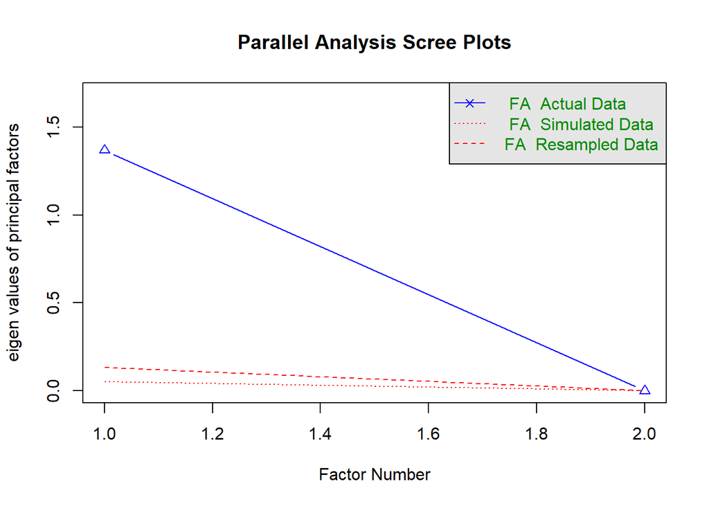

```
## Parallel analysis suggests that the number of factors =  1  and the number of components =  NA
```

Parallel analysis indicates a single factor.

**Exploratory factor analysis**:

```
##
## Factor analysis with Call: fa(r = ., nfactors = 1, rotate = "Promax", scores = "regression",
##     missing = TRUE, impute = "mean", fm = "ml", use = "pairwise",
##     cor = "cor")
##
## Test of the hypothesis that 1 factor is sufficient.
## The degrees of freedom for the model is -1  and the objective function was  0
## The number of observations was  608  with Chi Square =  0  with prob <  NA
##
## The root mean square of the residuals (RMSA) is  0
## The df corrected root mean square of the residuals is  NA
##
## Tucker Lewis Index of factoring reliability =  1.003
```

```
##
## Loadings:
##                   ML1
## SEGM_RT_TRN3_RND4 0.827
## SEGM_RT_RND4_REC5 0.827
##
##                  ML1
## SS loadings    1.369
## Proportion Var 0.684
```

```
## # A tibble: 2 × 2
##   names                 x
##   <chr>             <dbl>
## 1 SEGM_RT_TRN3_RND4 0.316
## 2 SEGM_RT_RND4_REC5 0.316
```

##### 2.8.1.1.2. Offline SL indices (non-RT indices)

**Bartlett’s test**:

```
## ℹ 'x' was not a correlation matrix. Correlations are found from entered raw data.
```

```
##
## ✔ The Bartlett's test of sphericity was significant at an alpha level of .05.
##   These data are probably suitable for factor analysis.
##
##   𝜒²(15) = 356.5, p < .001
```

**Parallel analysis**:

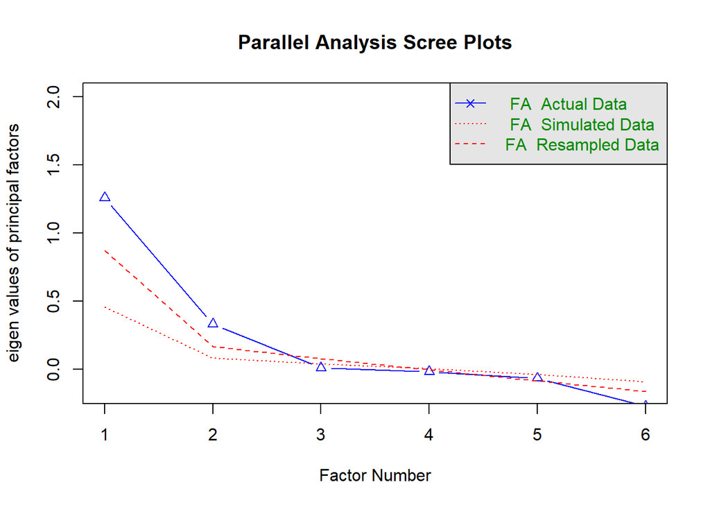

```
## Parallel analysis suggests that the number of factors =  2  and the number of components =  NA
```

Parallel analysis indicates 2 factors.

**Exploratory factor analysis**:

```
##
## Factor analysis with Call: fa(r = ., nfactors = 2, rotate = "Promax", scores = "regression",
##     missing = TRUE, impute = "mean", fm = "ml", use = "pairwise",
##     cor = "cor")
##
## Test of the hypothesis that 2 factors are sufficient.
## The degrees of freedom for the model is 4  and the objective function was  0.02
## The number of observations was  608  with Chi Square =  9.05  with prob <  0.06
##
## The root mean square of the residuals (RMSA) is  0.02
## The df corrected root mean square of the residuals is  0.05
##
## Tucker Lewis Index of factoring reliability =  0.944
## RMSEA index =  0.046  and the 10 % confidence intervals are  0 0.086
## BIC =  -16.59
##  With factor correlations of
##      ML1  ML2
## ML1 1.00 0.39
## ML2 0.39 1.00
```

```
##
## Loadings:
##                   ML1    ML2
## SEGM_2AFC_bigram   0.316
## SEGM_2AFC_trigram  1.020
## SEGM_production    0.150  0.336
## AGL_2AFC_phrase           0.442
## AGL_2AFC_sentence         0.700
## AGL_production            0.562
##
##                  ML1   ML2
## SS loadings    1.173 1.122
## Proportion Var 0.196 0.187
## Cumulative Var 0.196 0.382
```

```
## # A tibble: 6 × 2
##   names                   x
##   <chr>               <dbl>
## 1 SEGM_2AFC_bigram  0.881
## 2 SEGM_2AFC_trigram 0.00500
## 3 SEGM_production   0.825
## 4 AGL_2AFC_phrase   0.826
## 5 AGL_2AFC_sentence 0.543
## 6 AGL_production    0.679
```

##### 2.8.1.1.3. Final model for statistical learning variables

Since the 2-factor model showed a complex structure, we proceeded with hierarchical cluster analysis to reveal potential single-variable factors.

**Hierarchical cluster analysis**:

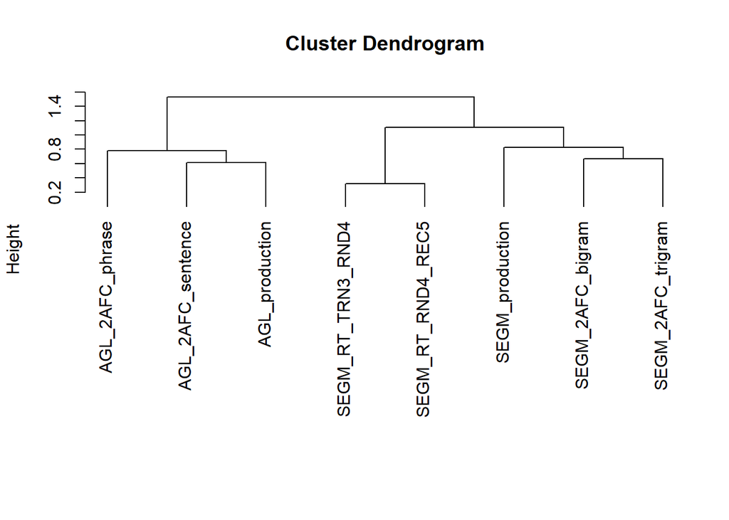

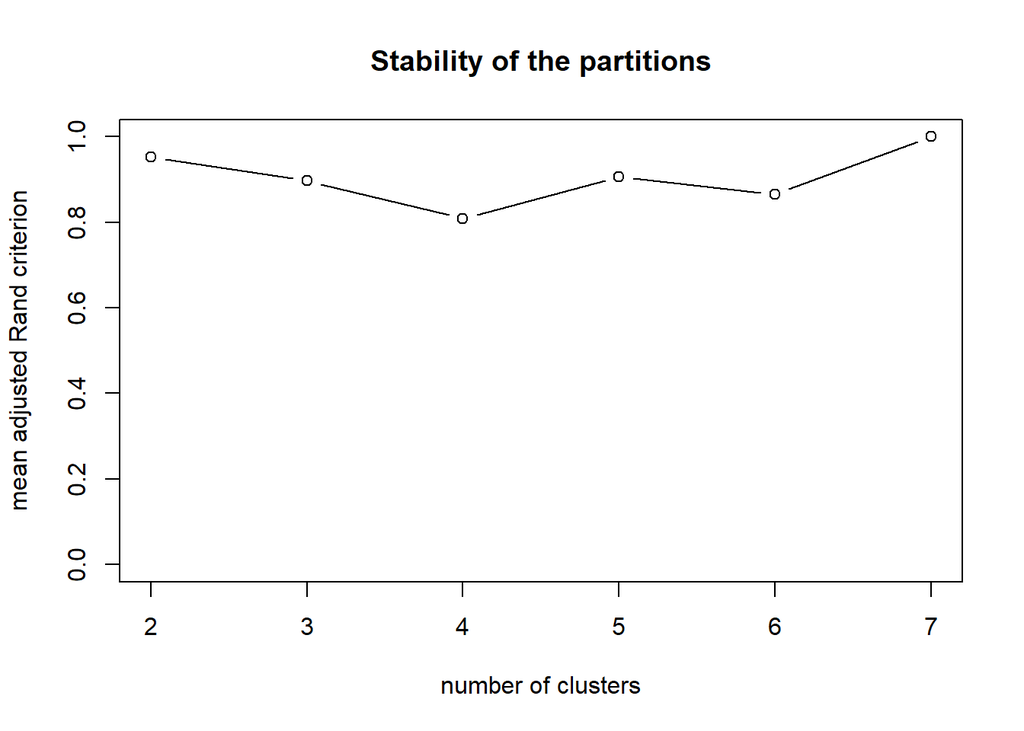

**K-means cluster analysis**:

```
##
## Call:
## kmeansvar(X.quanti = ., init = 5, nstart = 1000)
##
## number of iterations:  1
##
## Data:
##    number of observations:  608
##    number of variables:  8
##    number of clusters:  5
##
## Cluster  1 :
##                   squared loading correlation
## SEGM_RT_TRN3_RND4            0.84       -0.92
## SEGM_RT_RND4_REC5            0.84       -0.92
##
##
## Cluster  2 :
##                   squared loading correlation
## SEGM_2AFC_trigram            0.67       -0.82
## SEGM_2AFC_bigram             0.67       -0.82
##
##
## Cluster  3 :
## squared loading     correlation
##               1               1
##
##
## Cluster  4 :
## squared loading     correlation
##               1               1
##
##
## Cluster  5 :
##                   squared loading correlation
## AGL_2AFC_sentence            0.69       -0.83
## AGL_production               0.69       -0.83
##
##
## Gain in cohesion (in %):  72.67
```

In conclusion, we used these 5 clusters of statistical learning variables to identify latent factors which later serve as predictors in the SEM models. We tested the robustness of the results with confirmatory factor analysis.

**Confirmatory factor analysis**:

**Model fits for CFA**:

```
## lavaan 0.6.17 ended normally after 42 iterations
##
##   Estimator                                         ML
##   Optimization method                           NLMINB
##   Number of model parameters                        32
##
##                                                   Used       Total
##   Number of observations                           386         608
##   Number of missing patterns                        10
##
## Model Test User Model:
##                                               Standard      Scaled
##   Test Statistic                                13.255      13.401
##   Degrees of freedom                                12          12
##   P-value (Chi-square)                           0.351       0.341
##   Scaling correction factor                                  0.989
##     Yuan-Bentler correction (Mplus variant)
##
## Model Test Baseline Model:
##
##   Test statistic                               359.061     317.073
##   Degrees of freedom                                28          28
##   P-value                                        0.000       0.000
##   Scaling correction factor                                  1.132
##
## User Model versus Baseline Model:
##
##   Comparative Fit Index (CFI)                    0.996       0.995
##   Tucker-Lewis Index (TLI)                       0.991       0.989
##
##   Robust Comparative Fit Index (CFI)                         1.000
##   Robust Tucker-Lewis Index (TLI)                            1.011
##
## Loglikelihood and Information Criteria:
##
##   Loglikelihood user model (H0)              -2870.611   -2870.611
##   Scaling correction factor                                  1.118
##       for the MLR correction
##   Loglikelihood unrestricted model (H1)      -2863.983   -2863.983
##   Scaling correction factor                                  1.083
```

[output cut: 74 more lines]

```
## Variances:
##                    Estimate  Std.Err  z-value  P(>|z|)   Std.lv  Std.all
##    .SEGM_RT_TRN3_R    0.167    0.137    1.215    0.224    0.167    0.196
##    .SEGM_RT_RND4_R    0.369    0.113    3.256    0.001    0.369    0.422
##    .SEGM_2AFC_bgrm    0.822    0.093    8.830    0.000    0.822    0.815
##    .SEGM_2AFC_trgr    0.412    0.220    1.874    0.061    0.412    0.390
##    .SEGM_productin    0.000                               0.000    0.000
##    .AGL_2AFC_sntnc    0.578    0.106    5.428    0.000    0.578    0.592
##    .AGL_production    0.610    0.104    5.859    0.000    0.610    0.630
##    .AGL_2AFC_phras    0.000                               0.000    0.000
##     SL_RT             0.685    0.153    4.467    0.000    1.000    1.000
##     SL_tribi          0.186    0.083    2.255    0.024    1.000    1.000
##     SL_SEGM_prod      0.920    0.064   14.390    0.000    1.000    1.000
##     SL_AGL            0.398    0.114    3.506    0.000    1.000    1.000
##     SL_phr            0.967    0.081   11.974    0.000    1.000    1.000
```

In one case (*SEGM_2AFC_bigram [speech segmentation - SEGM 2AFC bigram]*), the unexplained variance was high (>0.65), however we kept it to assign convergent validity to the SL_trigram variable.

The final grouping of the variables is:

1. **SEGM RT**:
- SEGM_RT_TRN3_RND4 [speech segmentation - SEGM RT TRN3-RND4]
- SEGM_RT_RND4_REC5 [speech segmentation - SEGM RT RND4-REC5]
2. **SEGM 2AFC**:
- SEGM_2AFC_trigram [speech segmentation - SEGM 2AFC trigram]
- SEGM_2AFC_bigram [speech segmentation - SEGM 2AFC bigram]
3. **SEGM production**:
- SEGM_production [speech segmentation - SEGM production]
4. **AGL**:
- AGL_2AFC_sentence [artificial grammar learning - AGL 2AFC sentence ]
- AGL_production [artificial grammar learning - AGL production]
5. **AGL phrase**:
- AGL_2AFC_phrase [artificial grammar learning - AGL 2AFC phrase]

#### 2.8.1.2. Latent factors in the core cognitive domain

Compared to the original model, we excluded two indices: - simon_accuracy [simon - accuracy] - simon_RT [simon - RT]

**Kaiser-Meyer-Olkin test**:

```
## ℹ 'x' was not a correlation matrix. Correlations are found from entered raw data.
```

```
##
## ── Kaiser-Meyer-Olkin criterion (KMO) ──────────────────────────────────────────
##
## ! The overall KMO value for your data is mediocre.
##   These data are probably suitable for factor analysis.
##
##   Overall: 0.669
##
##   For each variable:
##       perceptual_speed_visual_RT     perceptual_speed_auditory_RT
##                            0.706                            0.688
## perceptual_speed_visual_decision               digit_span_forward
##                            0.767                            0.638
##              digit_span_backward              nback_1_back_dprime
##                            0.610                            0.764
##              nback_2_back_dprime              nback_3_back_dprime
##                            0.637                            0.661
##                        stroop_RT                  stroop_accuracy
##                            0.618                            0.526
```

Indices with unsatisfactory fit for EFA (MSA < 0.6) were excluded: - stroop_accuracy [stroop - accuracy]

Then, KMO test was repeated.

```
## ℹ 'x' was not a correlation matrix. Correlations are found from entered raw data.
```

```
##
## ── Kaiser-Meyer-Olkin criterion (KMO) ──────────────────────────────────────────
##
## ! The overall KMO value for your data is mediocre.
##   These data are probably suitable for factor analysis.
##
##   Overall: 0.682
##
##   For each variable:
##       perceptual_speed_visual_RT     perceptual_speed_auditory_RT
##                            0.705                            0.689
## perceptual_speed_visual_decision               digit_span_forward
##                            0.759                            0.637
##              digit_span_backward              nback_1_back_dprime
##                            0.611                            0.763
##              nback_2_back_dprime              nback_3_back_dprime
##                            0.639                            0.663
##                        stroop_RT
##                            0.721
```

**Bartlett’s test**:

```
## ℹ 'x' was not a correlation matrix. Correlations are found from entered raw data.
```

```
##
## ✔ The Bartlett's test of sphericity was significant at an alpha level of .05.
##   These data are probably suitable for factor analysis.
##
##   𝜒²(36) = 1213.48, p < .001
```

**Parallel analysis**:

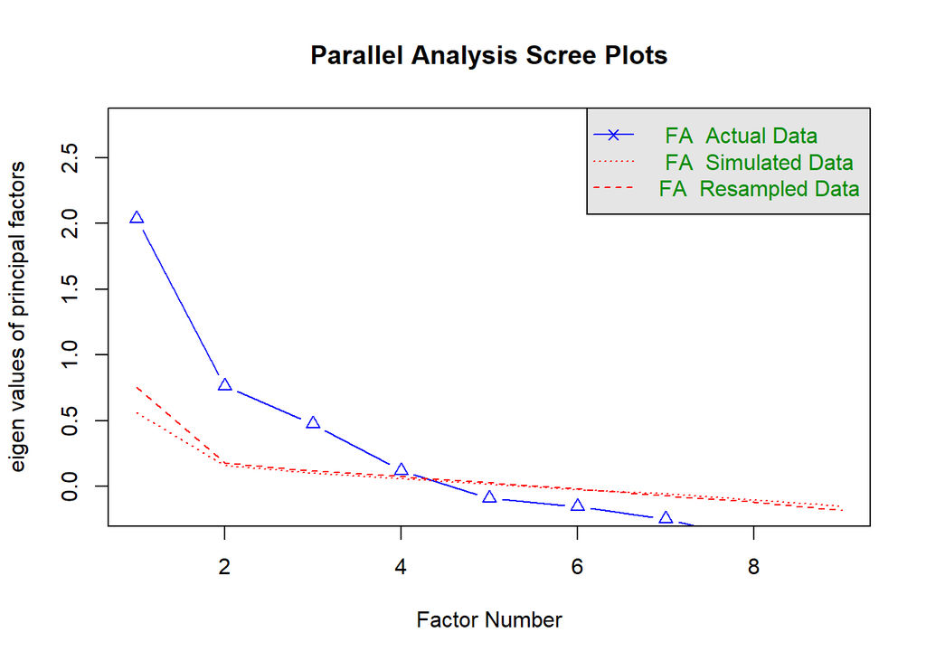

```
## Parallel analysis suggests that the number of factors =  4  and the number of components =  NA
```

**Exploratory factor analysis**:

```
##
## Factor analysis with Call: fa(r = ., nfactors = 4, rotate = "Promax", scores = "regression",
##     missing = TRUE, impute = "mean", fm = "ml", use = "pairwise",
##     cor = "cor")
##
## Test of the hypothesis that 4 factors are sufficient.
## The degrees of freedom for the model is 6  and the objective function was  0.02
## The number of observations was  608  with Chi Square =  14.17  with prob <  0.028
##
## The root mean square of the residuals (RMSA) is  0.01
## The df corrected root mean square of the residuals is  0.03
##
## Tucker Lewis Index of factoring reliability =  0.958
## RMSEA index =  0.047  and the 10 % confidence intervals are  0.015 0.08
## BIC =  -24.29
##  With factor correlations of
##      ML2  ML3  ML1  ML4
## ML2 1.00 0.35 0.19 0.18
## ML3 0.35 1.00 0.37 0.35
## ML1 0.19 0.37 1.00 0.37
## ML4 0.18 0.35 0.37 1.00
```

```
##
## Loadings:
##                                  ML2    ML3    ML1    ML4
## perceptual_speed_visual_RT               0.819
## perceptual_speed_auditory_RT             0.688        -0.151
## perceptual_speed_visual_decision         0.574         0.214
## digit_span_forward                       0.154  0.532
## digit_span_backward                             1.020
## nback_1_back_dprime               0.533
## nback_2_back_dprime               0.890
## nback_3_back_dprime               0.649               -0.141
## stroop_RT                                              0.653
##
##                  ML2   ML3   ML1   ML4
## SS loadings    1.507 1.508 1.333 0.526
## Proportion Var 0.167 0.168 0.148 0.058
## Cumulative Var 0.167 0.335 0.483 0.542
```

```
## # A tibble: 9 × 2
##   names                                  x
##   <chr>                              <dbl>
## 1 perceptual_speed_visual_RT       0.347
## 2 perceptual_speed_auditory_RT     0.620
## 3 perceptual_speed_visual_decision 0.538
## 4 digit_span_forward               0.627
## 5 digit_span_backward              0.00500
## 6 nback_1_back_dprime              0.681
## 7 nback_2_back_dprime              0.244
## 8 nback_3_back_dprime              0.559
## 9 stroop_RT                        0.576
```

For further analysis, we performed hierarchical variable clustering on the core cognitive variables as well.

**Hierarchical cluster analysis**:

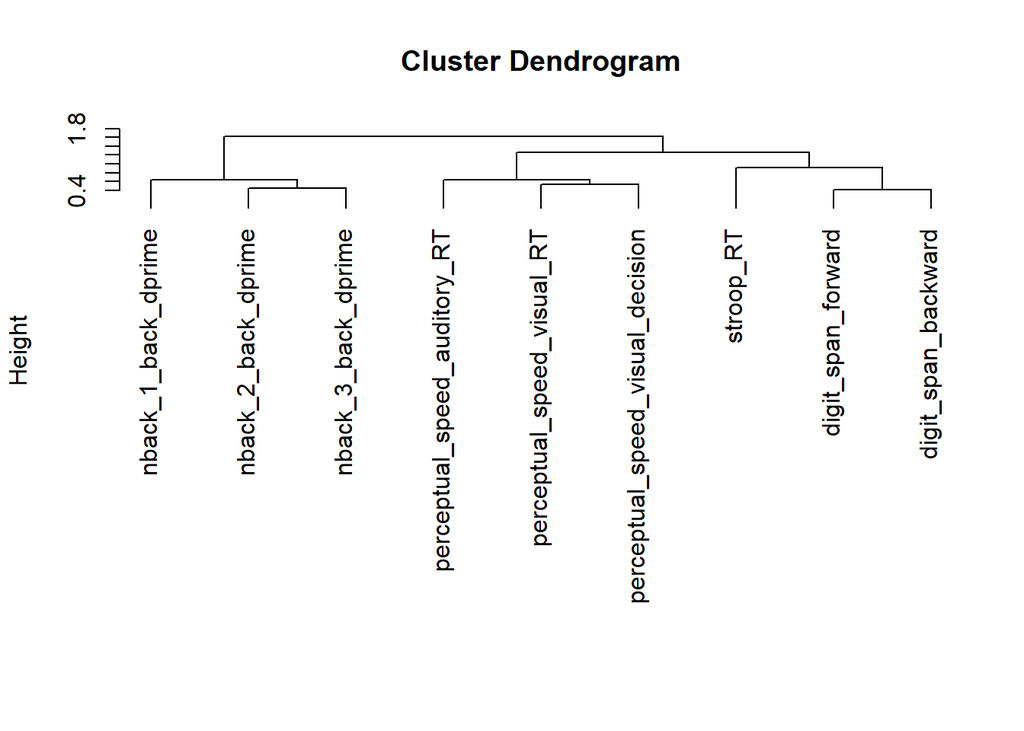

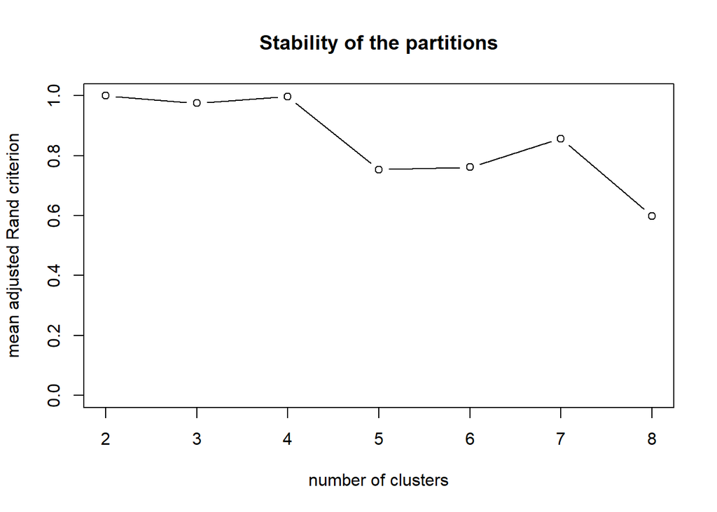

**K-means cluster analysis**:

```
##
## Call:
## kmeansvar(X.quanti = ., init = 4, nstart = 1000)
##
## number of iterations:  3
##
## Data:
##    number of observations:  608
##    number of variables:  9
##    number of clusters:  4
##
## Cluster  1 :
##                                  squared loading correlation
## perceptual_speed_visual_RT                  0.71       -0.85
## perceptual_speed_visual_decision            0.56       -0.78
## perceptual_speed_auditory_RT                0.56       -0.75
##
##
## Cluster  2 :
##                     squared loading correlation
## nback_2_back_dprime            0.75       -0.86
## nback_3_back_dprime            0.63       -0.80
## nback_1_back_dprime            0.55       -0.74
##
##
## Cluster  3 :
##                     squared loading correlation
## digit_span_backward            0.79       -0.89
## digit_span_forward             0.79       -0.89
##
##
## Cluster  4 :
## squared loading     correlation
##               1               1
##
##
## Gain in cohesion (in %):  58.67
```

In conclusion, we have 4 clusters of cognitive variables:

1. **perceptual speed**:
- perceptual_speed_visual_RT [perceptual speed - visual reaction time]
- perceptual_speed_auditory_RT [perceptual speed - auditory reaction time]
- perceptual_speed_visual_decision [perceptual speed - visual decision time]
2. **digit span**:
- digit_span_forward [digit span - forward digit span]
- digit_span_backward [digit span - backward digit span]
3. **nback test**:
- nback_1_back_dprime [n-back - 1-back d-prime]
- nback_2_back_dprime [n-back - 2-back d-prime]
- nback_3_back_dprime [n-back - 3-back d-prime]
4. **cognitive control**:
- stroop_RT [stroop - RT]

As the following step, we tested whether these factors shows an appropriate fit using CFA.

**Confirmatory factor analysis**:

**Model fits for CFA**:

```
## lavaan 0.6.17 ended normally after 37 iterations
##
##   Estimator                                         ML
##   Optimization method                           NLMINB
##   Number of model parameters                        32
##
##                                                   Used       Total
##   Number of observations                           588         608
##   Number of missing patterns                        31
##
## Model Test User Model:
##                                               Standard      Scaled
##   Test Statistic                                56.929      54.216
##   Degrees of freedom                                22          22
##   P-value (Chi-square)                           0.000       0.000
##   Scaling correction factor                                  1.050
##     Yuan-Bentler correction (Mplus variant)
##
## Model Test Baseline Model:
##
##   Test statistic                              1019.304     903.964
##   Degrees of freedom                                36          36
##   P-value                                        0.000       0.000
##   Scaling correction factor                                  1.128
##
## User Model versus Baseline Model:
##
##   Comparative Fit Index (CFI)                    0.964       0.963
##   Tucker-Lewis Index (TLI)                       0.942       0.939
##
##   Robust Comparative Fit Index (CFI)                         0.953
##   Robust Tucker-Lewis Index (TLI)                            0.923
##
## Loglikelihood and Information Criteria:
##
##   Loglikelihood user model (H0)              -5691.041   -5691.041
##   Scaling correction factor                                  1.818
##       for the MLR correction
##   Loglikelihood unrestricted model (H1)      -5662.577   -5662.577
##   Scaling correction factor                                  1.505
```

[output cut: 70 more lines]

```
## Variances:
##                    Estimate  Std.Err  z-value  P(>|z|)   Std.lv  Std.all
##    .prcptl_spd__RT    0.237    0.064    3.722    0.000    0.237    0.294
##    .prcptl_spd_vs_    0.519    0.070    7.412    0.000    0.519    0.502
##    .prcptl_spd__RT    0.611    0.074    8.258    0.000    0.611    0.683
##    .digt_spn_frwrd    0.400    0.077    5.189    0.000    0.400    0.405
##    .dgt_spn_bckwrd    0.436    0.074    5.851    0.000    0.436    0.430
##    .nbck_1_bck_dpr    0.647    0.050   12.941    0.000    0.647    0.674
##    .nbck_2_bck_dpr    0.248    0.069    3.615    0.000    0.248    0.275
##    .nbck_3_bck_dpr    0.564    0.063    8.962    0.000    0.564    0.565
##    .stroop_RT         0.000                               0.000    0.000
##     COG_PS            0.567    0.125    4.546    0.000    1.000    1.000
##     COG_DS            0.586    0.099    5.953    0.000    1.000    1.000
##     COG_nback         0.313    0.062    5.072    0.000    1.000    1.000
##     COG_RT            0.916    0.217    4.222    0.000    1.000    1.000
```